# Mississippi Flyway Data Book, 2026

### Data Table 40d: Light Goose CO Crippling

| Season | AR | IA | IL | IN | KY | LA | MN | MO | MS | TN | CO | KS | MT | ND | NE | NM | OK | SD | TX | WY | MF | CF | Total |
| --- | --- | --- | --- | --- | --- | --- | --- | --- | --- | --- | --- | --- | --- | --- | --- | --- | --- | --- | --- | --- | --- | --- | --- |
| 1999 | NA | NA | NA | NA | NA | NA | NA | NA | NA | NA | NA | NA | NA | NA | NA | NA | NA | NA | NA | NA | 0 | 0 | 0 |
| 2000 | 6,950 | 2,304 | NA | NA | NA | 14,200 | 904 | NA | NA | NA | NA | NA | NA | 4,300 | NA | NA | NA | NA | NA | NA | 24,358 | 4,300 | 28,658 |
| 2001 | 11,979 | 951 | NA | NA | NA | 17,100 | 19 | NA | NA | NA | NA | NA | NA | 390 | NA | NA | NA | NA | NA | NA | 30,049 | 390 | 30,439 |
| 2002 | 14,993 | 3,187 | NA | NA | NA | NA | 637 | NA | NA | NA | NA | NA | NA | 707 | NA | NA | NA | NA | NA | NA | 18,817 | 707 | 19,524 |
| 2003 | 9,780 | 1,963 | NA | NA | NA | 8,400 | 253 | NA | NA | NA | NA | NA | NA | 864 | NA | NA | NA | NA | NA | NA | 20,396 | 864 | 21,260 |
| 2004 | 11,056 | 1,963 | NA | NA | NA | 30,900 | 315 | NA | NA | NA | NA | NA | NA | 129 | NA | NA | NA | NA | NA | NA | 44,234 | 129 | 44,363 |
| 2005 | 5,640 | 1,073 | 4,862 | NA | NA | 14,400 | 150 | NA | NA | NA | NA | NA | NA | 1,117 | NA | NA | NA | NA | NA | NA | 26,125 | 1,117 | 27,242 |
| 2006 | 22,551 | 2,352 | 8,892 | NA | NA | 14,200 | 163 | NA | NA | NA | NA | NA | NA | 993 | NA | NA | NA | NA | NA | NA | 48,158 | 993 | 49,151 |
| 2007 | 8,406 | 1,966 | 11,078 | NA | NA | 8,200 | 172 | NA | NA | NA | NA | NA | NA | 752 | NA | NA | NA | NA | NA | NA | 29,822 | 752 | 30,574 |
| 2008 | 11,913 | 867 | 11,050 | NA | NA | 9,900 | 288 | NA | NA | NA | NA | NA | NA | 1,025 | NA | NA | NA | NA | NA | NA | 34,018 | 1,025 | 35,043 |
| 2009 | 14,140 | 2,269 | 5,547 | NA | NA | 5,900 | 640 | NA | NA | NA | NA | NA | NA | 1,022 | NA | NA | NA | NA | NA | NA | 28,496 | 1,022 | 29,518 |
| 2010 | 11,711 | 1,245 | 3,561 | NA | NA | 3,000 | 70 | NA | NA | NA | 822 | 853 | NA | 1,716 | 1,723 | NA | 50 | 4,401 | NA | 9 | 19,587 | 9,574 | 29,161 |
| 2011 | 14,558 | NA | 7,810 | NA | NA | 5,832 | 145 | NA | NA | NA | 1,248 | 5,320 | NA | 660 | 3,829 | 19 | 100 | 7,753 | NA | 92 | 28,345 | 19,021 | 47,366 |
| 2012 | 8,044 | 1,289 | 4,157 | NA | 227 | 17,772 | 210 | NA | NA | NA | 993 | 2,436 | NA | 753 | 3,691 | 87 | 48 | 7,957 | NA | 49 | 31,699 | 16,014 | 47,713 |
| 2013 | 20,239 | NA | 3,686 | NA | 286 | 4,043 | 370 | NA | NA | NA | 1,720 | 3,473 | NA | 1,704 | 2,684 | 53 | 46 | 12,785 | 1,596 | 20 | 28,624 | 24,081 | 52,705 |
| 2014 | 24,486 | 1,926 | 6,108 | NA | 360 | 608 | 210 | NA | NA | NA | NA | 4,773 | NA | 3,025 | 1,207 | 57 | 112 | 7,840 | 1,173 | 43 | 33,698 | 18,230 | 51,928 |
| 2015 | 23,833 | 1,106 | 5,491 | 261 | 688 | 6,405 | 349 | NA | NA | NA | 941 | 4,115 | NA | 5,505 | 1,987 | 51 | 18 | 6,756 | 1,580 | 27 | 38,133 | 20,980 | 59,113 |
| 2016 | 14,020 | 1,543 | 5,570 | 189 | 318 | 1,970 | 215 | 9,031 | 304 | 202 | 1,290 | 1,072 | NA | 5,478 | 4,126 | NA | 14 | 4,623 | 1,351 | 21 | 33,362 | 17,975 | 51,337 |
| 2017 | 11,507 | 2,685 | 5,774 | 12 | 153 | 1,095 | 298 | 7,759 | 2,118 | 79 | 1,059 | 980 | NA | 4,028 | 5,982 | 18 | 75 | 6,806 | 866 | 42 | 31,480 | 19,856 | 51,336 |
| 2018 | 48,331 | 4,283 | 14,360 | 107 | 244 | 2,663 | 78 | 9,859 | 1,706 | 64 | 1,059 | 3,028 | NA | 4,863 | 5,990 | NA | 4 | 7,574 | 1,216 | 17 | 81,695 | 23,751 | 105,446 |
| 2019 | 17,553 | 312 | 5,558 | 133 | 185 | 322 | 206 | 4,896 | 1,505 | NA | 1,068 | 2,866 | NA | 2,909 | 2,222 | NA | 3 | 2,745 | 761 | 20 | 30,670 | 12,594 | 43,264 |
| 2020 | 41,128 | 632 | 7,395 | NA | 133 | NA | 54 | 10,644 | 1,414 | NA | 438 | 4,052 | NA | 4,890 | 8,106 | NA | 2 | 4,257 | 950 | 37 | 61,400 | 22,732 | 84,132 |
| 2021 | 21,870 | 611 | 5,443 | 5 | 804 | 1,400 | 150 | 9,186 | 6,845 | 33 | 954 | 2,973 | NA | 4,343 | 2,630 | NA | 43 | 4,281 | 960 | 51 | 46,347 | 16,235 | 62,582 |
| 2022 | 33,669 | 1,316 | 3,327 | 23 | 438 | 3,200 | 86 | 8,080 | 4,395 | 2 | 1,511 | 3,182 | 11 | 5,295 | 4,820 | 50 | 34 | 4,713 | 791 | 33 | 54,536 | 20,440 | 74,976 |
| 2023 | 28,155 | 1,078 | 4,222 | 95 | 406 | 1,700 | 54 | 16,564 | 2,406 | 11 | 1,395 | 2,354 | 0 | 2,836 | 5,688 | 22 | 211 | 5,493 | 1,106 | 44 | 54,691 | 19,149 | 73,840 |
| 2024 | 21,696 | 1,831 | 2,529 | 112 | 952 | 1,500 | 62 | 12,391 | 862 | 11 | 815 | 2,537 | 31 | 4,159 | 5,149 | 108 | 0 | 6,226 | 1,155 | 71 | 41,946 | 20,251 | 62,197 |
| 2025 | 19,586 | 771 | 5,257 | 366 | 685 | 740 | 286 | 15,331 | 1,063 | 22 | 861 | 5,539 | 8 | 5,302 | 5,955 | 53 | 694 | 4,612 | NA | 32 | 44,107 | 23,056 | 67,163 |
| 2026 | 21,776 | 1,593 | 2,804 | 218 | 178 | 1,200 | 132 | 15,327 | 874 | 59 | 407 | 5,212 | 40 | 5,302 | 3,350 | 0 | 195 | 4,184 | NA | 53 | 44,161 | 18,743 | 62,904 |

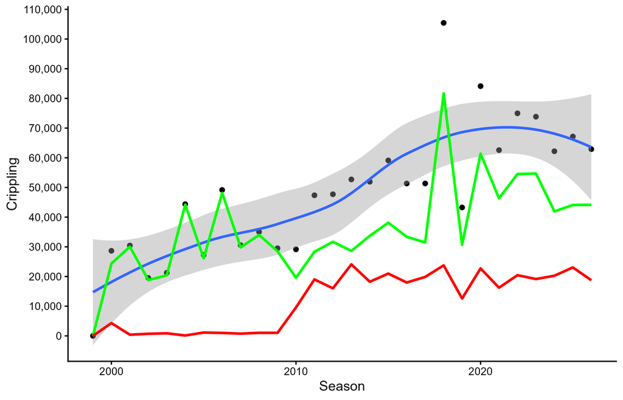

Figure 32: Light goose Conservation Order crippling in the Mississippi and Central Flyways. The blue line is a smoothed (Loess model) line with 95% confidence interval (shaded area) fit to the annual total estimates. The red line is the Central Flyway total. The green line is the Mississippi Flyway total.

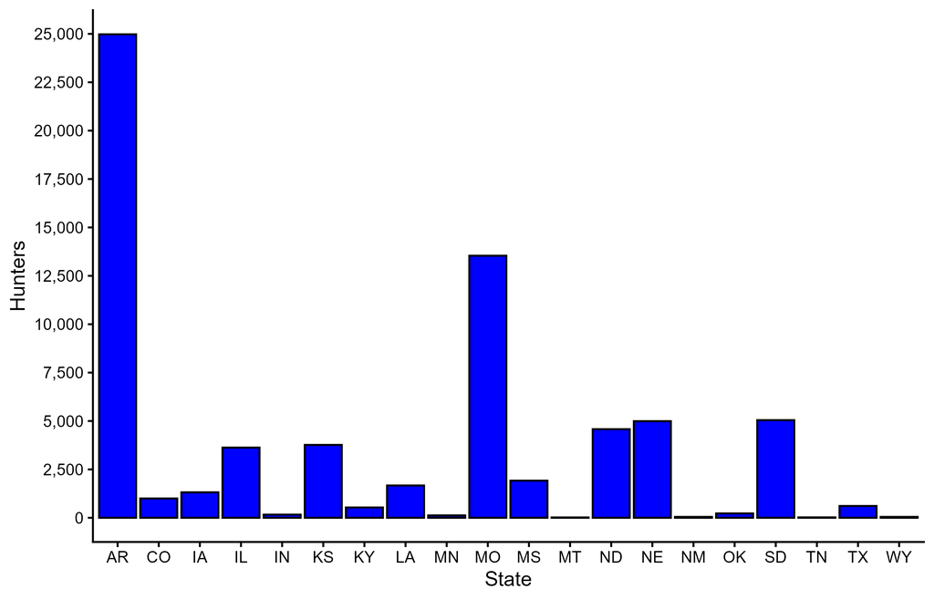

Figure 33: Light goose Conservation Order crippling during the recent 5-year period (average annual) by State in the Mississippi and Central Flyways.

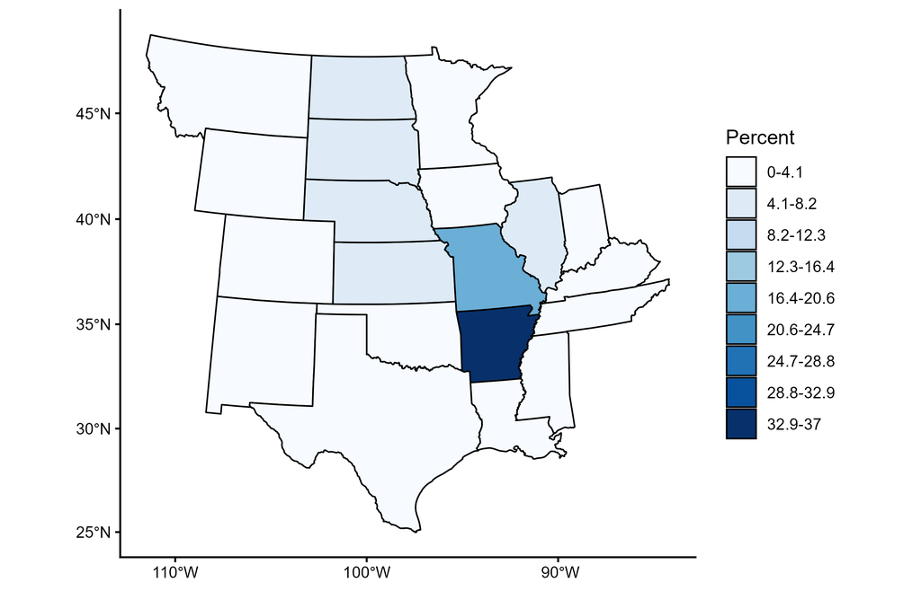

Figure 34: Light goose Conservation Order crippling during the recent 5-year period (average annual) by State in the Mississippi and Central Flyways. Values are proportion of total hunters.

## WBPHS and State Surveys

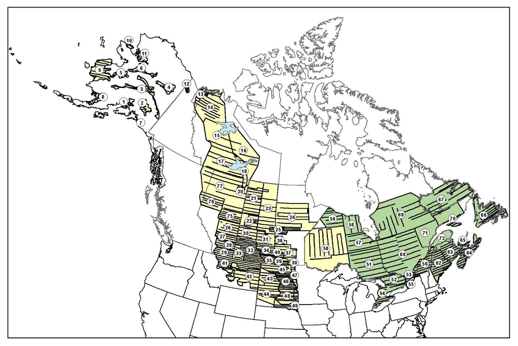

Waterfowl Breeding Population and Habitat Survey strata and transects. Yellow shading is the Traditional Survey Area and green shading is the Eastern Survey Area.

Waterfowl abundance is reported for the Waterfowl Breeding Population and Habitat Survey (WBPHS) Traditional Survey Area (TSA) by crew areas including the following:  
TSA = WBPHS Traditional Survey Area  
Area 1 = Alaska, Yukon Territory, and Old Crow Flats (strata 1–12)  
Area 2 = Central and northern Alberta, northeastern British Columbia, and Northwest Territories (strata 13–18, 20, 77)  
Area 3 = Northern Saskatchewan, northern Manitoba, and western Ontario (strata 21–25, 50)  
Area 4 = Southern Alberta (strata 26–29, 75–76)  
Area 5 = Southern Saskatchewan (strata 30–33)  
Area 6 = Southern Manitoba (strata 34–40; includes south east Saskatchewan)  
Area 7 = Montana and western Dakotas (strata 41–44)  
Area 8 = Eastern Dakotas (strata 45–49)

Total ducks includes the following species:  
American black duck, American green-winged teal, American wigeon, bufflehead, blue-winged teal, canvasback, gadwall, goldeneye species, mallard, northern pintail, northern shoveler, redhead, ring-necked duck, ruddy duck, scaup species.

### Data Table 50: Total Ducks WBPHS

Original data source: WBPHS Traditional Survey Area; USFWS Headquarters.

Table 50. Total duck abundance in the WBPHS Traditional Survey Area in spring, 1955-2026.

| Year | TSA | Area1 | Area2 | Area3 | Area4 | Area5 | Area6 | Area7 | Area8 |
| --- | --- | --- | --- | --- | --- | --- | --- | --- | --- |
| 1955 | 39,603,569 | 1,781,205 | 9,820,018 | 2,165,884 | 7,363,576 | 13,983,983 | 1,617,779 | 1,177,235 | 1,693,888 |
| 1956 | 42,035,155 | 1,846,837 | 8,299,825 | 2,090,767 | 6,447,961 | 18,563,185 | 1,748,982 | 1,138,961 | 1,898,638 |
| 1957 | 34,197,095 | 1,490,530 | 6,774,797 | 1,867,203 | 6,220,527 | 12,754,231 | 1,874,560 | 1,113,830 | 2,101,418 |
| 1958 | 36,528,121 | 2,060,836 | 7,997,576 | 2,403,474 | 6,681,567 | 10,133,574 | 3,606,569 | 1,140,353 | 2,504,173 |
| 1959 | 40,089,890 | 2,429,972 | 17,176,163 | 3,133,781 | 5,759,959 | 6,211,575 | 3,106,009 | 1,094,046 | 1,178,385 |
| 1960 | 32,080,543 | 2,075,147 | 7,980,953 | 1,941,253 | 5,671,430 | 8,049,952 | 2,247,490 | 1,048,601 | 3,065,717 |
| 1961 | 29,828,978 | 2,101,221 | 11,564,207 | 1,968,630 | 4,807,274 | 4,466,700 | 1,752,580 | 1,153,162 | 2,015,204 |
| 1962 | 25,038,942 | 2,666,148 | 7,260,882 | 2,537,393 | 2,891,506 | 3,522,171 | 1,134,443 | 1,154,308 | 3,872,091 |
| 1963 | 27,609,452 | 2,538,138 | 7,347,403 | 2,410,629 | 4,015,320 | 4,091,997 | 1,754,439 | 1,273,947 | 4,177,579 |
| 1964 | 27,768,809 | 2,226,857 | 9,098,950 | 2,900,610 | 3,930,618 | 4,483,980 | 1,594,665 | 1,084,123 | 2,449,006 |
| 1965 | 25,903,106 | 2,025,075 | 6,823,654 | 2,518,205 | 3,757,129 | 4,268,854 | 1,461,923 | 1,447,870 | 3,600,396 |
| 1966 | 30,574,173 | 2,312,224 | 6,619,374 | 2,411,187 | 5,480,219 | 6,795,588 | 1,338,609 | 1,568,801 | 4,048,172 |
| 1967 | 32,688,565 | 2,329,222 | 5,579,444 | 3,618,173 | 6,223,747 | 7,927,195 | 1,865,001 | 1,747,121 | 3,398,662 |
| 1968 | 28,971,228 | 3,790,406 | 5,224,957 | 5,080,270 | 3,736,829 | 5,851,232 | 1,091,939 | 1,098,795 | 3,096,800 |
| 1969 | 33,760,876 | 2,507,773 | 5,149,542 | 4,678,368 | 5,054,735 | 8,298,588 | 1,775,385 | 1,628,321 | 4,668,164 |
| 1970 | 39,676,260 | 2,794,433 | 6,190,441 | 6,088,106 | 5,329,228 | 10,641,506 | 1,934,865 | 1,544,328 | 5,153,353 |
| 1971 | 36,905,073 | 2,187,506 | 6,759,669 | 3,774,895 | 6,454,811 | 10,445,035 | 1,330,553 | 1,270,102 | 4,682,502 |
| 1972 | 40,748,019 | 2,739,500 | 10,303,503 | 3,521,004 | 6,465,629 | 9,049,652 | 1,663,689 | 2,015,201 | 4,989,841 |
| 1973 | 32,573,897 | 3,096,160 | 7,767,893 | 3,446,557 | 5,489,452 | 6,857,063 | 1,271,985 | 1,359,603 | 3,285,184 |
| 1974 | 35,422,489 | 3,252,310 | 6,018,714 | 2,929,500 | 7,688,200 | 8,821,911 | 2,041,640 | 1,116,650 | 3,553,564 |
| 1975 | 37,792,799 | 2,170,021 | 7,397,431 | 3,183,012 | 6,454,469 | 11,016,392 | 1,590,331 | 2,166,383 | 3,814,761 |
| 1976 | 34,342,263 | 2,825,936 | 5,108,722 | 4,092,149 | 5,528,392 | 11,213,039 | 2,344,794 | 1,500,742 | 1,728,489 |
| 1977 | 32,048,956 | 4,848,057 | 7,697,788 | 3,990,003 | 3,818,760 | 8,289,366 | 1,082,410 | 1,140,415 | 1,182,158 |
| 1978 | 35,505,581 | 3,578,654 | 7,240,370 | 4,831,954 | 4,237,070 | 6,430,252 | 1,403,330 | 2,430,990 | 5,352,961 |
| 1979 | 38,622,013 | 3,073,537 | 8,021,969 | 4,341,131 | 5,409,235 | 9,309,080 | 1,545,777 | 2,115,463 | 4,805,822 |
| 1980 | 36,224,430 | 5,243,392 | 8,023,785 | 4,413,909 | 4,896,556 | 7,515,613 | 1,468,737 | 1,302,711 | 3,359,727 |
| 1981 | 32,267,288 | 5,259,379 | 7,826,380 | 4,907,962 | 4,708,515 | 4,580,525 | 1,396,068 | 1,396,426 | 2,192,033 |
| 1982 | 30,784,023 | 2,963,122 | 5,949,994 | 3,618,890 | 3,546,487 | 6,864,099 | 1,548,574 | 2,321,410 | 3,971,447 |
| 1983 | 32,635,210 | 3,479,605 | 8,166,925 | 3,790,236 | 3,046,925 | 7,348,757 | 1,330,724 | 1,636,801 | 3,835,236 |
| 1984 | 31,004,936 | 4,010,391 | 9,104,394 | 3,062,498 | 2,725,719 | 5,121,916 | 697,433 | 1,421,463 | 4,861,122 |
| 1985 | 25,638,252 | 2,745,684 | 5,928,982 | 3,346,847 | 3,111,103 | 5,612,458 | 947,758 | 928,175 | 3,017,245 |
| 1986 | 29,092,808 | 3,302,250 | 7,082,048 | 2,621,948 | 2,532,809 | 5,417,332 | 1,637,296 | 1,228,761 | 5,270,364 |
| 1987 | 27,412,109 | 3,362,563 | 7,307,102 | 3,195,228 | 3,040,816 | 4,260,117 | 1,125,964 | 1,425,872 | 3,694,447 |
| 1988 | 27,361,744 | 3,874,899 | 7,521,558 | 4,190,233 | 2,702,537 | 4,141,494 | 1,041,408 | 1,234,803 | 2,654,812 |
| 1989 | 25,112,754 | 3,590,758 | 6,820,218 | 3,548,835 | 2,449,654 | 3,380,651 | 873,403 | 1,335,105 | 3,114,130 |
| 1990 | 25,079,166 | 3,961,323 | 5,754,399 | 3,780,593 | 3,356,705 | 4,295,831 | 1,276,475 | 1,204,509 | 1,449,331 |
| 1991 | 26,605,595 | 4,392,449 | 5,755,659 | 4,513,529 | 3,070,198 | 4,203,776 | 984,686 | 1,323,446 | 2,361,852 |
| 1992 | 29,417,883 | 3,691,263 | 5,749,574 | 5,721,327 | 3,108,779 | 5,671,081 | 1,533,509 | 1,304,435 | 2,637,914 |
| 1993 | 26,312,407 | 3,635,535 | 5,918,746 | 4,577,785 | 3,443,064 | 3,576,271 | 872,589 | 1,506,031 | 2,782,386 |
| 1994 | 32,523,459 | 4,289,209 | 5,331,221 | 3,906,556 | 3,553,162 | 5,876,881 | 814,655 | 2,997,219 | 5,754,555 |
| 1995 | 35,869,640 | 4,298,317 | 5,790,068 | 3,889,127 | 3,270,109 | 6,896,092 | 1,521,973 | 2,673,314 | 7,530,639 |
| 1996 | 37,752,965 | 4,734,672 | 4,411,957 | 3,951,675 | 3,884,673 | 9,197,009 | 1,643,179 | 2,439,748 | 7,490,053 |
| 1997 | 42,556,343 | 4,185,762 | 6,574,765 | 3,721,623 | 3,809,144 | 10,554,579 | 1,514,687 | 4,291,013 | 7,904,770 |
| 1998 | 39,081,907 | 5,728,457 | 6,224,887 | 3,411,397 | 3,203,784 | 8,375,979 | 1,394,197 | 2,999,117 | 7,744,089 |
| 1999 | 43,435,799 | 5,184,532 | 8,316,165 | 3,839,189 | 3,315,025 | 9,687,396 | 1,681,824 | 2,504,798 | 8,906,871 |
| 2000 | 41,838,270 | 6,726,566 | 6,899,974 | 3,468,043 | 3,484,683 | 7,665,038 | 1,486,193 | 1,725,883 | 10,381,891 |
| 2001 | 36,177,460 | 6,427,121 | 5,489,402 | 2,656,262 | 2,520,783 | 6,441,812 | 1,792,923 | 1,587,812 | 9,261,345 |
| 2002 | 31,181,128 | 4,961,417 | 6,583,730 | 4,502,382 | 2,363,558 | 3,547,374 | 1,303,546 | 1,334,251 | 6,584,871 |
| 2003 | 36,225,121 | 5,704,917 | 6,461,001 | 3,564,180 | 2,696,066 | 9,295,864 | 1,582,276 | 1,730,737 | 5,190,081 |
| 2004 | 32,163,986 | 5,456,172 | 5,882,220 | 4,084,527 | 2,498,793 | 5,783,368 | 1,473,840 | 1,614,801 | 5,370,264 |
| 2005 | 31,734,935 | 5,113,856 | 4,712,530 | 3,223,493 | 3,178,226 | 7,966,659 | 1,626,997 | 1,290,149 | 4,623,025 |
| 2006 | 36,160,330 | 4,754,502 | 5,131,564 | 2,711,268 | 4,580,690 | 10,095,517 | 1,795,934 | 1,909,836 | 5,181,018 |
| 2007 | 41,172,191 | 5,689,815 | 6,137,361 | 3,212,072 | 4,293,057 | 11,036,231 | 1,321,546 | 1,625,416 | 7,856,693 |
| 2008 | 37,276,466 | 5,122,777 | 6,934,379 | 3,162,429 | 4,199,429 | 8,949,437 | 1,222,875 | 1,139,234 | 6,545,905 |
| 2009 | 42,004,841 | 4,345,259 | 6,933,755 | 3,813,012 | 3,287,868 | 8,052,927 | 1,371,363 | 2,467,783 | 11,732,874 |
| 2010 | 40,893,777 | 5,555,837 | 8,717,117 | 2,149,444 | 2,641,326 | 6,839,266 | 1,103,507 | 1,977,203 | 11,910,078 |
| 2011 | 45,554,287 | 3,755,695 | 7,094,613 | 2,439,305 | 4,371,665 | 10,680,675 | 1,554,026 | 3,134,876 | 12,523,433 |
| 2012 | 48,575,264 | 4,454,823 | 8,799,317 | 2,754,351 | 4,844,730 | 11,317,699 | 1,537,535 | 2,466,578 | 12,400,230 |
| 2013 | 45,607,319 | 3,296,294 | 8,323,318 | 3,441,241 | 4,471,154 | 12,258,341 | 1,575,034 | 1,598,823 | 10,643,114 |
| 2014 | 49,152,231 | 3,510,092 | 9,945,622 | 2,566,499 | 5,643,685 | 12,893,274 | 2,193,064 | 3,659,864 | 8,740,130 |
| 2015 | 49,521,695 | 3,389,463 | 11,546,133 | 3,527,214 | 5,677,678 | 13,542,131 | 1,988,198 | 2,730,169 | 7,120,709 |
| 2016 | 48,362,830 | 4,327,471 | 14,041,008 | 3,246,303 | 5,031,893 | 10,752,604 | 1,777,337 | 2,228,860 | 6,957,356 |
| 2017 | 47,265,648 | 3,987,272 | 11,422,720 | 2,560,729 | 6,444,258 | 12,151,560 | 1,748,036 | 2,207,210 | 6,743,863 |
| 2018 | 41,193,231 | 3,381,387 | 9,915,761 | 3,167,375 | 5,546,108 | 8,492,473 | 1,664,788 | 2,238,572 | 6,786,767 |
| 2019 | 38,898,901 | 2,612,134 | 10,376,817 | 2,459,593 | 4,574,722 | 6,478,728 | 1,221,617 | 2,404,469 | 8,770,820 |
| 2020 | NA | NA | NA | NA | NA | NA | NA | NA | NA |
| 2021 | NA | NA | NA | NA | NA | NA | NA | NA | NA |
| 2022 | 34,657,152 | 3,831,208 | 7,655,881 | 2,787,804 | 3,010,156 | 5,993,794 | 1,744,351 | 1,751,357 | 7,882,601 |
| 2023 | 32,304,811 | 1,920,220 | 8,348,241 | 3,138,551 | 3,192,097 | 6,508,003 | 1,152,187 | 2,161,328 | 5,884,185 |
| 2024 | 33,988,082 | 2,449,405 | 11,247,646 | 3,290,379 | 2,685,942 | 5,476,463 | 988,669 | 1,941,611 | 5,907,968 |
| 2025 | 33,980,409 | 2,559,645 | 10,975,217 | 2,989,859 | 3,132,332 | 6,690,026 | 1,193,097 | 1,797,819 | 4,642,413 |
| 2026 | 33,439,490 | 2,279,912 | 10,722,784 | 3,607,796 | 3,041,503 | 7,759,096 | 923,478 | 1,568,288 | 3,536,632 |

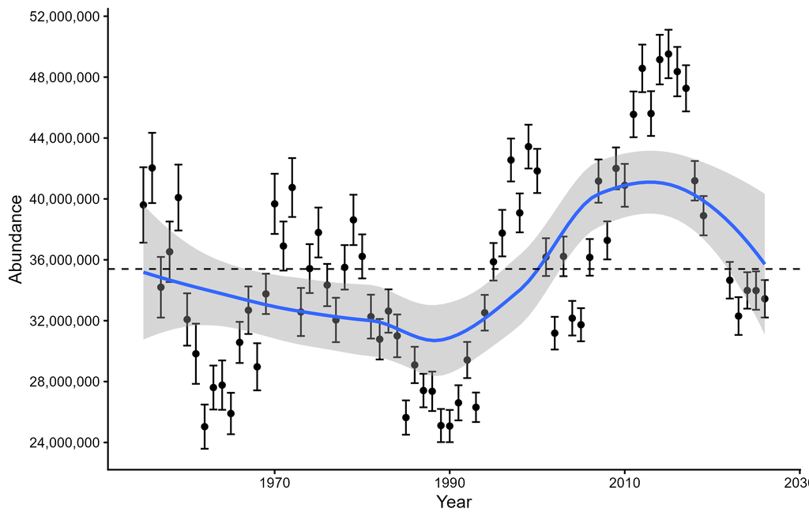

Figure 35: Total duck abundance in the WBPHS Traditional Survey Area in spring. Circles are annual estimates of abundance with 95% confidence intervals. The blue line is a smoothed (Loess model) line with 95% confidence interval (shaded area) fit to the annual estimates. The black dashed reference line is the long term average.

### Data Table 51: Mallard WBPHS

Original data source: WBPHS Traditional Survey Area; USFWS Headquarters.

Table 51. Mallard abundance in the WBPHS Traditional Survey Area in spring, 1955-2026.

| Year | TSA | Area1 | Area2 | Area3 | Area4 | Area5 | Area6 | Area7 | Area8 |
| --- | --- | --- | --- | --- | --- | --- | --- | --- | --- |
| 1955 | 8,777,294 | 173,246 | 1,635,090 | 738,596 | 1,906,984 | 3,317,190 | 424,781 | 294,570 | 286,837 |
| 1956 | 10,452,690 | 174,466 | 1,472,958 | 1,091,637 | 1,757,634 | 4,691,429 | 627,975 | 305,576 | 331,015 |
| 1957 | 9,296,888 | 160,144 | 1,045,916 | 712,947 | 1,986,693 | 3,987,910 | 712,945 | 317,684 | 372,649 |
| 1958 | 11,234,244 | 185,939 | 1,385,330 | 1,244,572 | 2,072,202 | 4,533,958 | 920,607 | 352,252 | 539,384 |
| 1959 | 9,024,288 | 214,046 | 2,764,253 | 1,042,198 | 1,753,018 | 2,152,157 | 545,446 | 337,137 | 216,033 |
| 1960 | 7,371,652 | 159,377 | 760,753 | 705,948 | 1,502,358 | 2,967,483 | 526,169 | 342,753 | 406,811 |
| 1961 | 7,329,954 | 284,998 | 2,303,954 | 705,114 | 1,330,884 | 1,649,689 | 331,411 | 348,291 | 375,614 |
| 1962 | 5,535,905 | 171,743 | 1,285,875 | 883,120 | 983,105 | 1,125,920 | 193,720 | 386,171 | 506,251 |
| 1963 | 6,748,828 | 208,939 | 1,413,733 | 682,874 | 1,227,931 | 1,551,425 | 327,684 | 446,620 | 889,622 |
| 1964 | 6,063,865 | 106,147 | 1,364,808 | 848,278 | 1,119,407 | 1,387,258 | 418,015 | 353,541 | 466,411 |
| 1965 | 5,131,702 | 189,593 | 725,018 | 873,704 | 893,925 | 1,069,927 | 271,519 | 493,121 | 614,895 |
| 1966 | 6,731,878 | 128,491 | 828,963 | 706,102 | 1,546,738 | 1,975,568 | 333,193 | 585,739 | 627,083 |
| 1967 | 7,509,548 | 256,758 | 745,024 | 1,713,404 | 1,502,441 | 1,888,409 | 289,357 | 572,270 | 541,885 |
| 1968 | 7,089,238 | 240,929 | 942,097 | 1,580,498 | 911,963 | 2,132,153 | 197,783 | 385,147 | 698,668 |
| 1969 | 7,531,615 | 162,856 | 705,811 | 1,807,774 | 1,121,447 | 2,179,962 | 356,523 | 588,392 | 608,850 |
| 1970 | 9,985,873 | 293,897 | 941,420 | 2,299,328 | 1,594,553 | 2,945,486 | 447,844 | 519,181 | 944,164 |
| 1971 | 9,416,373 | 167,149 | 981,425 | 1,265,078 | 1,871,286 | 3,407,249 | 288,941 | 475,317 | 959,928 |
| 1972 | 9,265,550 | 261,877 | 1,435,377 | 1,059,311 | 1,825,320 | 2,711,463 | 431,017 | 695,747 | 845,438 |
| 1973 | 8,079,202 | 245,252 | 1,047,395 | 1,213,243 | 1,729,505 | 2,369,095 | 233,686 | 457,358 | 783,669 |
| 1974 | 6,880,153 | 278,242 | 822,886 | 854,427 | 1,576,215 | 2,073,786 | 341,429 | 353,693 | 579,475 |
| 1975 | 7,726,878 | 132,692 | 1,004,359 | 963,323 | 1,398,330 | 2,449,214 | 379,809 | 816,172 | 582,979 |
| 1976 | 7,933,588 | 181,397 | 465,460 | 1,455,808 | 1,453,591 | 3,044,740 | 540,411 | 257,491 | 534,689 |
| 1977 | 7,397,061 | 459,778 | 944,191 | 1,366,564 | 853,258 | 2,869,326 | 254,066 | 343,389 | 306,489 |
| 1978 | 7,424,968 | 318,842 | 951,721 | 1,796,447 | 823,488 | 1,917,559 | 290,484 | 539,201 | 787,225 |
| 1979 | 7,883,440 | 275,779 | 1,084,674 | 1,594,540 | 983,127 | 2,244,208 | 359,782 | 424,741 | 916,589 |
| 1980 | 7,706,483 | 399,102 | 1,164,920 | 1,409,205 | 975,156 | 2,262,999 | 414,664 | 424,829 | 655,608 |
| 1981 | 6,409,701 | 476,251 | 931,305 | 1,451,147 | 947,057 | 1,509,802 | 352,948 | 431,993 | 309,198 |
| 1982 | 6,408,475 | 254,727 | 757,380 | 1,188,225 | 765,771 | 1,941,081 | 419,630 | 602,153 | 479,508 |
| 1983 | 6,456,007 | 321,687 | 1,278,635 | 1,041,562 | 845,564 | 1,670,142 | 354,567 | 487,078 | 456,773 |
| 1984 | 5,415,271 | 504,182 | 715,489 | 866,029 | 713,044 | 1,364,736 | 176,720 | 393,524 | 681,547 |
| 1985 | 4,960,868 | 219,055 | 831,328 | 871,986 | 802,991 | 1,173,330 | 238,763 | 301,703 | 521,712 |
| 1986 | 6,124,236 | 233,539 | 1,419,972 | 670,099 | 698,795 | 1,542,604 | 382,585 | 419,051 | 757,591 |
| 1987 | 5,789,776 | 185,802 | 934,840 | 1,011,668 | 753,948 | 1,273,327 | 249,911 | 530,503 | 849,777 |
| 1988 | 6,369,341 | 356,711 | 1,304,591 | 1,470,827 | 627,426 | 1,389,229 | 273,493 | 402,546 | 544,518 |
| 1989 | 5,645,440 | 411,507 | 961,780 | 1,337,471 | 585,874 | 951,715 | 238,337 | 537,504 | 621,252 |
| 1990 | 5,452,385 | 366,933 | 945,897 | 1,340,135 | 778,677 | 1,253,692 | 292,954 | 270,478 | 203,619 |
| 1991 | 5,444,580 | 385,319 | 905,433 | 1,289,946 | 769,227 | 1,031,104 | 236,481 | 386,667 | 440,403 |
| 1992 | 5,976,077 | 345,708 | 882,323 | 1,422,259 | 733,528 | 1,293,391 | 334,241 | 394,628 | 569,999 |
| 1993 | 5,708,293 | 282,983 | 941,493 | 1,295,651 | 753,847 | 1,036,406 | 243,692 | 506,757 | 647,465 |
| 1994 | 6,980,066 | 350,875 | 734,870 | 1,379,215 | 848,784 | 1,380,293 | 300,840 | 729,580 | 1,255,609 |
| 1995 | 8,269,415 | 524,200 | 1,010,534 | 1,381,903 | 778,457 | 1,808,542 | 416,244 | 855,268 | 1,494,267 |
| 1996 | 7,941,315 | 522,006 | 676,727 | 1,120,329 | 793,817 | 2,142,740 | 358,512 | 811,127 | 1,516,057 |
| 1997 | 9,939,695 | 584,247 | 1,205,629 | 1,036,931 | 883,563 | 2,450,765 | 436,468 | 1,337,954 | 2,004,138 |
| 1998 | 9,640,364 | 836,216 | 1,054,582 | 1,058,440 | 950,114 | 2,448,699 | 439,468 | 1,068,030 | 1,784,814 |
| 1999 | 10,805,682 | 713,054 | 2,040,801 | 1,150,627 | 1,031,842 | 2,528,577 | 514,435 | 689,187 | 2,137,160 |
| 2000 | 9,470,212 | 770,333 | 1,288,093 | 1,048,981 | 833,157 | 2,266,723 | 367,667 | 622,005 | 2,273,253 |
| 2001 | 7,903,955 | 718,286 | 979,033 | 603,318 | 743,759 | 1,649,653 | 445,965 | 463,284 | 2,300,657 |
| 2002 | 7,503,707 | 667,339 | 1,182,336 | 1,114,789 | 793,296 | 1,212,517 | 400,670 | 428,286 | 1,704,474 |
| 2003 | 7,949,743 | 843,497 | 851,810 | 1,103,386 | 627,097 | 2,110,665 | 504,996 | 506,101 | 1,402,192 |
| 2004 | 7,425,314 | 811,135 | 776,385 | 1,283,383 | 600,099 | 1,609,494 | 393,429 | 494,941 | 1,456,448 |
| 2005 | 6,755,268 | 703,140 | 533,133 | 937,142 | 671,364 | 1,728,862 | 454,765 | 386,590 | 1,340,271 |
| 2006 | 7,276,538 | 515,821 | 558,073 | 655,635 | 900,747 | 1,831,707 | 511,286 | 679,233 | 1,624,037 |
| 2007 | 8,307,296 | 581,493 | 887,452 | 864,169 | 830,157 | 2,155,069 | 387,183 | 552,582 | 2,049,190 |
| 2008 | 7,723,809 | 532,414 | 1,079,188 | 1,046,076 | 875,215 | 1,907,131 | 380,904 | 353,530 | 1,549,351 |
| 2009 | 8,512,378 | 502,970 | 1,079,740 | 930,463 | 753,955 | 1,866,899 | 417,281 | 444,464 | 2,516,605 |
| 2010 | 8,430,138 | 605,556 | 1,423,198 | 800,616 | 597,692 | 1,698,950 | 350,824 | 533,391 | 2,419,912 |
| 2011 | 9,182,591 | 415,825 | 974,976 | 828,352 | 938,591 | 2,093,040 | 521,185 | 836,886 | 2,573,736 |
| 2012 | 10,601,516 | 505,583 | 1,547,098 | 1,038,514 | 1,260,530 | 2,502,082 | 401,020 | 792,513 | 2,554,176 |
| 2013 | 10,371,890 | 338,379 | 1,020,349 | 1,427,498 | 1,141,041 | 2,575,586 | 448,205 | 793,888 | 2,626,945 |
| 2014 | 10,899,822 | 500,879 | 1,757,212 | 1,126,422 | 1,443,553 | 2,553,334 | 601,731 | 1,013,897 | 1,902,795 |
| 2015 | 11,643,321 | 470,915 | 1,981,061 | 1,728,364 | 1,391,683 | 3,068,413 | 538,152 | 766,949 | 1,697,783 |
| 2016 | 11,792,529 | 584,200 | 2,524,465 | 1,668,640 | 1,487,897 | 2,784,121 | 470,408 | 628,915 | 1,643,883 |
| 2017 | 10,488,461 | 538,451 | 1,836,830 | 1,074,123 | 1,290,954 | 2,725,103 | 587,162 | 658,357 | 1,777,481 |
| 2018 | 9,255,153 | 450,750 | 1,549,853 | 1,276,799 | 1,327,872 | 2,093,517 | 460,480 | 559,905 | 1,535,978 |
| 2019 | 9,423,411 | 361,060 | 1,700,754 | 1,105,252 | 971,539 | 1,712,412 | 441,469 | 770,594 | 2,360,332 |
| 2020 | NA | NA | NA | NA | NA | NA | NA | NA | NA |
| 2021 | NA | NA | NA | NA | NA | NA | NA | NA | NA |
| 2022 | 7,434,293 | 614,444 | 1,219,314 | 1,088,267 | 686,775 | 1,294,059 | 513,041 | 513,986 | 1,504,407 |
| 2023 | 6,125,722 | 380,917 | 1,059,812 | 928,821 | 739,986 | 1,265,721 | 255,783 | 530,140 | 964,543 |
| 2024 | 6,609,303 | 506,629 | 1,606,236 | 1,159,084 | 629,949 | 1,162,945 | 216,376 | 516,890 | 811,193 |
| 2025 | 6,553,649 | 389,414 | 1,332,350 | 1,151,550 | 696,313 | 1,313,726 | 335,872 | 501,753 | 832,671 |
| 2026 | 5,859,292 | 404,017 | 1,423,733 | 967,993 | 685,004 | 1,233,512 | 194,412 | 336,395 | 614,226 |

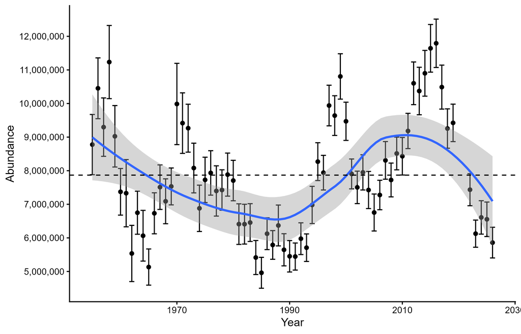

Figure 36: Mallard abundance in the WBPHS Traditional Survey Area in spring. Circles are annual estimates of abundance with 95% confidence intervals. The blue line is a smoothed (Loess model) line with 95% confidence interval (shaded area) fit to the annual estimates. The black dashed reference line is the long term average.

### Data Table 52: Northern Pintail WBPHS

Original data source: WBPHS Traditional Survey Area; USFWS Headquarters.

Table 52. Northern pintail abundance in the WBPHS Traditional Survey Area in spring, 1955-2026.

| Year | TSA | Area1 | Area2 | Area3 | Area4 | Area5 | Area6 | Area7 | Area8 |
| --- | --- | --- | --- | --- | --- | --- | --- | --- | --- |
| 1955 | 9,775,075 | 662,213 | 1,161,390 | 142,679 | 1,591,524 | 5,076,494 | 213,432 | 469,606 | 457,736 |
| 1956 | 10,372,801 | 676,914 | 687,713 | 69,704 | 1,521,459 | 6,222,181 | 284,112 | 428,270 | 482,448 |
| 1957 | 6,606,886 | 399,215 | 585,165 | 35,995 | 1,250,631 | 3,245,914 | 192,281 | 393,643 | 504,042 |
| 1958 | 6,037,921 | 752,478 | 1,133,922 | 30,537 | 1,223,870 | 1,813,032 | 187,395 | 371,684 | 525,003 |
| 1959 | 5,872,740 | 1,051,707 | 2,583,695 | 75,476 | 832,648 | 775,041 | 127,774 | 341,490 | 84,909 |
| 1960 | 5,722,160 | 742,531 | 697,882 | 57,746 | 1,087,483 | 1,665,516 | 217,171 | 324,465 | 929,366 |
| 1961 | 4,218,159 | 634,899 | 1,277,718 | 132,034 | 513,319 | 846,659 | 97,951 | 320,516 | 395,062 |
| 1962 | 3,623,524 | 864,991 | 447,030 | 30,457 | 328,585 | 581,072 | 104,810 | 322,806 | 943,772 |
| 1963 | 3,846,015 | 860,955 | 307,522 | 54,976 | 811,931 | 823,901 | 177,122 | 308,330 | 501,277 |
| 1964 | 3,291,227 | 773,552 | 475,679 | 60,005 | 417,623 | 853,386 | 114,949 | 263,068 | 332,965 |
| 1965 | 3,591,918 | 586,251 | 453,537 | 34,562 | 777,086 | 716,564 | 129,038 | 333,877 | 561,003 |
| 1966 | 4,811,934 | 717,673 | 202,821 | 37,728 | 1,265,152 | 1,504,782 | 96,677 | 326,689 | 660,412 |
| 1967 | 5,277,693 | 681,344 | 148,650 | 39,693 | 1,559,463 | 1,671,102 | 168,713 | 411,820 | 596,908 |
| 1968 | 3,489,395 | 1,444,503 | 227,653 | 81,224 | 501,554 | 809,172 | 54,594 | 121,990 | 248,706 |
| 1969 | 5,903,888 | 645,624 | 98,275 | 106,356 | 1,584,537 | 1,956,154 | 266,267 | 223,033 | 1,023,642 |
| 1970 | 6,391,987 | 733,465 | 165,221 | 154,714 | 1,366,414 | 2,417,173 | 198,759 | 355,389 | 1,000,852 |
| 1971 | 5,847,204 | 452,464 | 132,797 | 75,231 | 1,763,054 | 2,222,040 | 139,535 | 220,326 | 841,756 |
| 1972 | 6,978,954 | 898,932 | 468,661 | 36,305 | 1,716,409 | 2,261,553 | 211,972 | 477,641 | 907,481 |
| 1973 | 4,356,220 | 1,120,482 | 378,960 | 51,884 | 1,025,103 | 1,006,310 | 73,556 | 293,865 | 406,060 |
| 1974 | 6,598,182 | 937,980 | 320,614 | 25,638 | 2,123,070 | 2,185,998 | 301,804 | 186,259 | 516,820 |
| 1975 | 5,900,370 | 651,918 | 442,791 | 52,930 | 1,553,133 | 2,050,332 | 216,198 | 415,914 | 517,154 |
| 1976 | 5,475,644 | 854,383 | 267,420 | 52,025 | 956,502 | 2,549,564 | 249,401 | 294,503 | 251,847 |
| 1977 | 3,926,093 | 1,931,166 | 551,600 | 58,412 | 345,799 | 672,535 | 26,195 | 222,584 | 117,802 |
| 1978 | 5,108,179 | 1,011,857 | 263,202 | 77,298 | 1,087,568 | 961,787 | 90,648 | 581,137 | 1,034,681 |
| 1979 | 5,376,133 | 752,148 | 236,300 | 33,403 | 1,456,351 | 1,579,919 | 195,928 | 470,317 | 651,767 |
| 1980 | 4,508,077 | 1,816,457 | 296,128 | 28,903 | 842,287 | 897,591 | 68,588 | 192,243 | 365,880 |
| 1981 | 3,479,479 | 1,488,696 | 346,317 | 56,375 | 657,342 | 526,183 | 59,014 | 207,576 | 137,976 |
| 1982 | 3,708,758 | 788,226 | 112,303 | 21,794 | 576,822 | 1,222,040 | 107,096 | 466,018 | 414,458 |
| 1983 | 3,510,642 | 925,329 | 410,376 | 26,087 | 380,814 | 1,029,352 | 97,235 | 205,517 | 435,931 |
| 1984 | 2,964,801 | 925,967 | 460,038 | 21,347 | 299,777 | 492,073 | 26,871 | 232,846 | 505,882 |
| 1985 | 2,515,493 | 637,131 | 291,798 | 10,983 | 593,397 | 520,629 | 40,786 | 110,129 | 310,640 |
| 1986 | 2,739,747 | 882,518 | 185,630 | 17,082 | 242,646 | 545,934 | 120,539 | 212,975 | 532,423 |
| 1987 | 2,628,344 | 959,434 | 231,444 | 39,548 | 447,350 | 343,843 | 56,304 | 286,760 | 263,661 |
| 1988 | 2,005,522 | 1,142,541 | 198,857 | 15,671 | 171,394 | 113,754 | 33,566 | 135,107 | 194,632 |
| 1989 | 2,111,902 | 878,625 | 213,321 | 10,544 | 313,638 | 363,716 | 16,783 | 102,210 | 213,065 |
| 1990 | 2,256,630 | 1,102,962 | 170,079 | 17,558 | 317,734 | 336,665 | 55,256 | 198,064 | 58,312 |
| 1991 | 1,803,384 | 1,026,244 | 225,580 | 28,316 | 116,271 | 220,989 | 23,785 | 67,519 | 94,681 |
| 1992 | 2,098,139 | 899,710 | 275,123 | 18,822 | 103,933 | 456,880 | 90,449 | 120,523 | 132,699 |
| 1993 | 2,053,418 | 743,329 | 228,928 | 6,841 | 372,521 | 240,368 | 37,524 | 195,674 | 228,233 |
| 1994 | 2,972,266 | 787,540 | 104,885 | 13,432 | 383,404 | 785,173 | 47,704 | 394,437 | 455,693 |
| 1995 | 2,757,866 | 809,938 | 102,228 | 40,200 | 198,200 | 554,227 | 109,443 | 300,724 | 642,907 |
| 1996 | 2,735,862 | 776,099 | 56,382 | 3,708 | 333,503 | 807,418 | 84,460 | 234,458 | 439,835 |
| 1997 | 3,557,991 | 647,490 | 249,472 | 22,301 | 472,805 | 1,123,865 | 64,691 | 416,147 | 561,220 |
| 1998 | 2,520,649 | 945,957 | 186,398 | 8,958 | 166,284 | 551,839 | 63,689 | 193,262 | 404,261 |
| 1999 | 3,057,888 | 1,021,885 | 182,712 | 8,760 | 114,998 | 875,231 | 61,508 | 206,656 | 586,139 |
| 2000 | 2,907,559 | 1,452,235 | 220,276 | 15,869 | 188,826 | 463,613 | 44,686 | 169,478 | 352,576 |
| 2001 | 3,295,994 | 1,426,489 | 174,979 | 9,909 | 66,077 | 680,017 | 97,079 | 161,324 | 680,121 |
| 2002 | 1,789,710 | 941,985 | 187,162 | 11,440 | 72,984 | 181,841 | 31,572 | 102,367 | 260,358 |
| 2003 | 2,558,229 | 848,188 | 169,798 | 5,607 | 251,949 | 993,374 | 39,240 | 121,767 | 128,306 |
| 2004 | 2,184,602 | 927,354 | 193,399 | 10,334 | 161,341 | 473,686 | 39,665 | 131,963 | 246,860 |
| 2005 | 2,560,530 | 905,431 | 108,257 | 8,450 | 282,273 | 857,542 | 67,944 | 75,022 | 255,612 |
| 2006 | 3,386,425 | 1,041,069 | 125,819 | 5,851 | 610,998 | 1,023,592 | 57,308 | 264,336 | 257,452 |
| 2007 | 3,335,302 | 1,134,655 | 234,388 | 5,430 | 324,150 | 960,301 | 14,908 | 117,917 | 543,554 |
| 2008 | 2,612,841 | 1,249,960 | 331,197 | 4,089 | 240,017 | 422,765 | 29,409 | 50,198 | 285,206 |
| 2009 | 3,224,957 | 929,569 | 243,149 | 21,463 | 171,944 | 444,195 | 47,846 | 382,678 | 984,114 |
| 2010 | 3,508,558 | 1,163,793 | 338,009 | 5,644 | 241,683 | 331,830 | 18,434 | 176,588 | 1,232,578 |
| 2011 | 4,428,650 | 745,505 | 121,076 | 9,985 | 655,024 | 1,106,403 | 38,479 | 279,124 | 1,473,054 |
| 2012 | 3,473,083 | 1,175,893 | 78,534 | 15,843 | 357,036 | 605,083 | 22,116 | 244,307 | 974,271 |
| 2013 | 3,334,993 | 994,601 | 234,809 | 9,537 | 367,741 | 824,863 | 35,652 | 88,393 | 779,398 |
| 2014 | 3,220,296 | 701,066 | 317,553 | 5,172 | 461,002 | 739,387 | 49,111 | 251,516 | 695,488 |
| 2015 | 3,043,012 | 668,404 | 638,529 | 52,243 | 259,839 | 719,989 | 40,610 | 196,962 | 466,437 |
| 2016 | 2,618,468 | 815,822 | 798,818 | 15,574 | 167,973 | 288,741 | 19,358 | 134,672 | 377,508 |
| 2017 | 2,889,231 | 756,963 | 675,067 | 9,807 | 301,074 | 560,615 | 30,760 | 106,208 | 448,736 |
| 2018 | 2,365,322 | 650,554 | 497,470 | 21,817 | 343,870 | 268,640 | 11,094 | 193,229 | 378,647 |
| 2019 | 2,268,466 | 430,591 | 529,713 | 3,365 | 133,277 | 163,516 | 13,851 | 372,536 | 621,616 |
| 2020 | NA | NA | NA | NA | NA | NA | NA | NA | NA |
| 2021 | NA | NA | NA | NA | NA | NA | NA | NA | NA |
| 2022 | 1,783,613 | 786,186 | 297,031 | 14,405 | 67,506 | 94,325 | 17,496 | 88,951 | 417,712 |
| 2023 | 2,218,505 | 546,196 | 389,934 | 7,602 | 152,400 | 285,535 | 10,945 | 183,063 | 642,829 |
| 2024 | 1,974,976 | 547,633 | 540,349 | 7,421 | 42,641 | 213,569 | 6,688 | 141,792 | 474,883 |
| 2025 | 2,238,819 | 712,374 | 735,645 | 9,869 | 124,698 | 301,807 | 16,754 | 100,480 | 237,191 |
| 2026 | 1,987,525 | 446,081 | 764,861 | 27,149 | 104,700 | 301,042 | 14,326 | 124,507 | 204,860 |

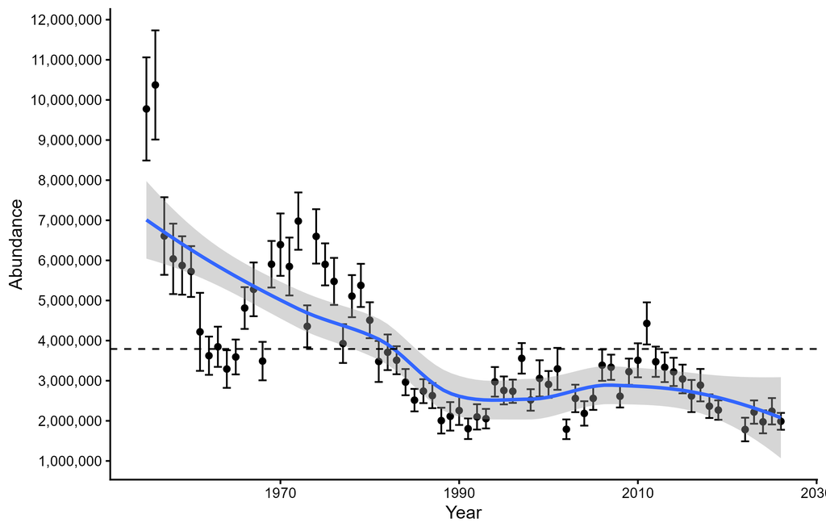

Figure 37: Northern pintail abundance in the WBPHS Traditional Survey Area in spring. Circles are annual estimates of abundance with 95% confidence intervals. The blue line is a smoothed (Loess model) line with 95% confidence interval (shaded area) fit to the annual estimates. The black dashed reference line is the long term average.

### Data Table 53: Gadwall WBPHS

Original data source: WBPHS Traditional Survey Area; USFWS Headquarters.

Table 53. Gadwall abundance in the WBPHS Traditional Survey Area in spring, 1955-2026.

| Year | TSA | Area1 | Area2 | Area3 | Area4 | Area5 | Area6 | Area7 | Area8 |
| --- | --- | --- | --- | --- | --- | --- | --- | --- | --- |
| 1955 | 651,497 | 582 | 1,301 | 4,844 | 200,319 | 359,048 | 27,595 | 57,809 | 0 |
| 1956 | 772,639 | 533 | 983 | 1,015 | 269,942 | 422,148 | 18,892 | 59,127 | 0 |
| 1957 | 666,826 | 926 | 1,566 | 5,559 | 187,084 | 375,700 | 23,559 | 60,482 | 11,951 |
| 1958 | 502,042 | 121 | 3,536 | NA | 219,587 | 136,737 | 34,053 | 61,664 | 46,344 |
| 1959 | 589,959 | 1,106 | 1,768 | 37,669 | 275,747 | 171,409 | 26,280 | 62,584 | 13,395 |
| 1960 | 784,071 | 713 | 0 | 1,367 | 369,182 | 227,008 | 27,597 | 63,201 | 95,003 |
| 1961 | 654,832 | 95 | 12,931 | 43,687 | 279,615 | 126,780 | 52,821 | 66,505 | 72,397 |
| 1962 | 905,075 | 486 | 9,104 | 12,392 | 207,811 | 342,747 | 38,765 | 68,100 | 225,670 |
| 1963 | 1,055,298 | 0 | 1,455 | 23,146 | 198,773 | 319,375 | 70,482 | 107,072 | 334,995 |
| 1964 | 873,374 | 742 | 9,781 | 29,124 | 256,634 | 317,564 | 54,384 | 79,954 | 125,190 |
| 1965 | 1,260,275 | 133 | 7,580 | 41,808 | 200,306 | 481,176 | 39,122 | 180,511 | 309,639 |
| 1966 | 1,680,441 | 1,392 | 1,879 | 30,424 | 479,606 | 575,370 | 78,826 | 160,052 | 352,892 |
| 1967 | 1,384,634 | 1,243 | 6,650 | 78,494 | 415,764 | 409,166 | 82,038 | 148,579 | 242,700 |
| 1968 | 1,948,955 | 86 | 13,410 | 76,842 | 491,606 | 679,884 | 42,690 | 136,596 | 507,841 |
| 1969 | 1,573,390 | 85 | 4,289 | 82,556 | 338,981 | 463,498 | 22,792 | 146,608 | 514,581 |
| 1970 | 1,608,072 | 85 | 22,685 | 38,475 | 343,276 | 511,537 | 50,295 | 103,354 | 538,365 |
| 1971 | 1,605,616 | 85 | 7,607 | 30,165 | 362,838 | 590,171 | 31,316 | 87,211 | 496,223 |
| 1972 | 1,622,943 | 85 | 23,022 | 37,785 | 444,939 | 488,815 | 67,088 | 27,516 | 533,693 |
| 1973 | 1,245,616 | 513 | 16,412 | 44,784 | 281,022 | 451,507 | 66,387 | 44,330 | 340,662 |
| 1974 | 1,592,352 | 5,343 | 8,215 | 16,939 | 495,640 | 644,723 | 52,797 | 102,120 | 266,574 |
| 1975 | 1,643,881 | 903 | 6,354 | 18,842 | 303,696 | 744,569 | 40,137 | 136,745 | 392,636 |
| 1976 | 1,244,760 | 552 | 6,659 | 16,873 | 308,696 | 679,395 | 56,163 | 90,508 | 85,913 |
| 1977 | 1,298,990 | 83 | 34,396 | 43,773 | 392,235 | 607,488 | 66,910 | 31,440 | 122,666 |
| 1978 | 1,557,988 | 2,042 | 18,044 | 28,600 | 279,676 | 532,861 | 44,402 | 263,188 | 389,175 |
| 1979 | 1,757,892 | 735 | 43,567 | 20,909 | 346,447 | 695,477 | 66,298 | 165,988 | 418,471 |
| 1980 | 1,392,884 | 702 | 56,477 | 44,641 | 319,614 | 474,563 | 119,359 | 128,892 | 248,636 |
| 1981 | 1,395,366 | 2,450 | 61,724 | 65,546 | 309,430 | 409,483 | 57,657 | 219,863 | 269,214 |
| 1982 | 1,633,765 | 2,081 | 58,282 | 25,034 | 215,521 | 619,727 | 47,725 | 187,600 | 477,794 |
| 1983 | 1,519,210 | 1,386 | 8,326 | 19,848 | 142,293 | 573,312 | 49,109 | 162,365 | 562,571 |
| 1984 | 1,515,045 | 3,949 | 37,570 | 11,013 | 204,445 | 411,816 | 15,533 | 118,889 | 711,830 |
| 1985 | 1,302,986 | 2,252 | 18,558 | 13,888 | 164,891 | 588,412 | 54,735 | 87,544 | 372,706 |
| 1986 | 1,547,139 | NA | 69,548 | 15,022 | 226,430 | 559,866 | 100,438 | 104,909 | 470,926 |
| 1987 | 1,305,607 | 653 | 42,271 | 18,737 | 127,093 | 539,128 | 63,430 | 85,408 | 428,887 |
| 1988 | 1,349,928 | 6,004 | 68,443 | 38,167 | 256,444 | 376,208 | 56,534 | 101,022 | 447,106 |
| 1989 | 1,414,554 | 4,915 | 87,357 | 21,292 | 250,164 | 387,935 | 60,414 | 219,199 | 383,278 |
| 1990 | 1,672,063 | 4,597 | 106,608 | 18,126 | 414,419 | 539,476 | 110,506 | 120,662 | 357,669 |
| 1991 | 1,583,655 | 8,875 | 81,961 | 49,419 | 292,740 | 507,677 | 65,251 | 228,814 | 348,918 |
| 1992 | 2,032,759 | 4,395 | 99,297 | 14,121 | 357,967 | 626,929 | 105,505 | 292,888 | 531,656 |
| 1993 | 1,755,222 | 654 | 80,421 | 37,918 | 414,289 | 429,562 | 78,381 | 285,259 | 428,738 |
| 1994 | 2,318,290 | 2,295 | 83,702 | 31,700 | 511,707 | 639,777 | 49,997 | 360,824 | 638,288 |
| 1995 | 2,835,729 | 654 | 63,768 | 37,841 | 410,569 | 583,604 | 81,149 | 685,238 | 972,906 |
| 1996 | 2,983,991 | 5,234 | 74,219 | 9,775 | 404,175 | 930,116 | 100,573 | 410,588 | 1,049,310 |
| 1997 | 3,897,210 | 1,309 | 92,728 | 21,345 | 308,295 | 1,155,292 | 91,466 | 1,227,281 | 999,494 |
| 1998 | 3,742,225 | 333 | 139,045 | 7,795 | 360,238 | 1,342,039 | 102,987 | 496,309 | 1,293,479 |
| 1999 | 3,235,478 | 4,913 | 138,519 | 9,891 | 332,528 | 1,028,707 | 115,620 | 378,771 | 1,226,529 |
| 2000 | 3,158,411 | 2,724 | 99,536 | 11,806 | 310,857 | 649,964 | 85,075 | 289,355 | 1,709,093 |
| 2001 | 2,679,157 | 6,543 | 111,105 | 14,754 | 256,756 | 715,449 | 106,253 | 402,796 | 1,065,501 |
| 2002 | 2,235,449 | 987 | 161,942 | 27,172 | 333,366 | 359,696 | 131,798 | 186,535 | 1,033,952 |
| 2003 | 2,549,028 | 4,580 | 75,848 | 30,366 | 240,943 | 1,076,560 | 94,085 | 205,988 | 820,658 |
| 2004 | 2,589,577 | 1,871 | 138,332 | 22,252 | 289,920 | 751,787 | 147,593 | 205,261 | 1,032,561 |
| 2005 | 2,179,111 | 2,654 | 77,031 | 18,798 | 338,207 | 723,032 | 120,402 | 186,673 | 712,313 |
| 2006 | 2,824,732 | 1,873 | 134,872 | 16,245 | 455,237 | 1,202,361 | 125,178 | 215,844 | 673,123 |
| 2007 | 3,355,903 | 3,211 | 100,073 | 14,632 | 343,378 | 1,317,263 | 110,111 | 265,852 | 1,201,383 |
| 2008 | 2,727,679 | 4,000 | 108,939 | 9,630 | 420,325 | 1,011,218 | 112,495 | 200,499 | 860,572 |
| 2009 | 3,053,516 | 2,000 | 66,629 | 8,817 | 400,976 | 1,043,832 | 117,909 | 318,918 | 1,094,435 |
| 2010 | 2,976,662 | 2,892 | 50,794 | 14,351 | 323,152 | 913,276 | 101,726 | 392,031 | 1,178,440 |
| 2011 | 3,256,941 | 1,333 | 40,782 | 32,723 | 346,517 | 1,020,016 | 92,232 | 469,976 | 1,253,362 |
| 2012 | 3,585,615 | 631 | 56,059 | 30,835 | 378,294 | 1,144,311 | 112,570 | 253,925 | 1,608,991 |
| 2013 | 3,351,362 | 1,638 | 33,444 | 12,787 | 339,544 | 1,300,439 | 132,648 | 217,153 | 1,313,709 |
| 2014 | 3,811,022 | NA | 43,194 | 35,745 | 565,034 | 1,454,509 | 236,345 | 425,558 | 1,050,637 |
| 2015 | 3,834,078 | 2,000 | 34,379 | 6,700 | 564,484 | 1,462,822 | 204,861 | 527,940 | 1,030,891 |
| 2016 | 3,712,044 | 10,596 | 107,140 | 20,841 | 652,911 | 1,473,214 | 134,792 | 281,734 | 1,030,816 |
| 2017 | 4,179,991 | 1,333 | 59,176 | 6,919 | 872,862 | 1,495,968 | 125,205 | 558,320 | 1,060,208 |
| 2018 | 2,885,912 | NA | 50,717 | 7,738 | 418,493 | 1,218,405 | 100,814 | 422,204 | 667,539 |
| 2019 | 3,258,709 | 431 | 77,318 | 4,315 | 592,184 | 1,107,385 | 139,691 | 409,136 | 928,249 |
| 2020 | NA | NA | NA | NA | NA | NA | NA | NA | NA |
| 2021 | NA | NA | NA | NA | NA | NA | NA | NA | NA |
| 2022 | 2,684,716 | 17,307 | 101,343 | 10,856 | 429,270 | 855,559 | 144,684 | 219,619 | 906,078 |
| 2023 | 2,561,374 | NA | 60,632 | 18,320 | 441,555 | 966,725 | 109,183 | 277,875 | 687,084 |
| 2024 | 2,284,432 | 755 | 124,091 | 4,827 | 388,610 | 649,496 | 77,061 | 213,488 | 826,106 |
| 2025 | 2,413,935 | 377 | 154,861 | 7,654 | 428,222 | 871,396 | 74,474 | 227,933 | 649,018 |
| 2026 | 2,351,469 | 4,912 | 77,852 | 27,984 | 402,383 | 863,726 | 139,316 | 273,617 | 561,678 |

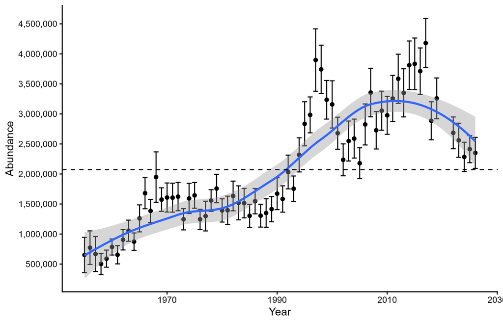

Figure 38: Gadwall abundance in the WBPHS Traditional Survey Area in spring. Circles are annual estimates of abundance with 95% confidence intervals. The blue line is a smoothed (Loess model) line with 95% confidence interval (shaded area) fit to the annual estimates. The black dashed reference line is the long term average.

### Data Table 54: American Wigeon WBPHS

Original data source: WBPHS Traditional Survey Area; USFWS Headquarters.

Table 54. American wigeon abundance in the WBPHS Traditional Survey Area in spring, 1955-2026.

| Year | TSA | Area1 | Area2 | Area3 | Area4 | Area5 | Area6 | Area7 | Area8 |
| --- | --- | --- | --- | --- | --- | --- | --- | --- | --- |
| 1955 | 3,216,798 | 73,215 | 1,559,563 | 190,230 | 582,304 | 620,429 | 95,311 | 61,155 | 34,592 |
| 1956 | 3,144,990 | 82,309 | 1,317,909 | 50,472 | 535,550 | 946,174 | 122,918 | 58,996 | 30,662 |
| 1957 | 2,919,777 | 156,916 | 1,340,886 | 51,527 | 535,785 | 634,025 | 114,992 | 58,278 | 27,367 |
| 1958 | 2,551,724 | 140,750 | 882,123 | 63,286 | 548,883 | 473,138 | 353,060 | 58,677 | 31,806 |
| 1959 | 3,787,661 | 107,890 | 2,120,472 | 131,248 | 616,007 | 472,625 | 247,479 | 59,940 | 32,000 |
| 1960 | 2,987,572 | 132,206 | 1,623,260 | 149,756 | 539,938 | 365,228 | 83,081 | 63,584 | 30,519 |
| 1961 | 3,048,266 | 135,235 | 1,847,208 | 132,941 | 502,309 | 238,029 | 117,411 | 64,044 | 11,089 |
| 1962 | 1,958,746 | 180,180 | 925,316 | 187,678 | 380,146 | 150,209 | 56,804 | 68,290 | 10,123 |
| 1963 | 1,830,808 | 77,248 | 879,133 | 146,872 | 315,248 | 237,331 | 86,458 | 72,707 | 15,811 |
| 1964 | 2,589,605 | 118,482 | 1,404,337 | 214,079 | 346,277 | 310,129 | 115,703 | 71,609 | 8,990 |
| 1965 | 2,301,124 | 209,044 | 1,028,090 | 252,269 | 320,911 | 317,687 | 130,473 | 42,650 | NA |
| 1966 | 2,318,376 | 247,113 | 984,964 | 229,101 | 385,549 | 302,129 | 98,086 | 52,888 | 18,545 |
| 1967 | 2,325,465 | 280,898 | 545,043 | 191,502 | 485,275 | 649,108 | 52,397 | 106,312 | 14,930 |
| 1968 | 2,298,570 | 347,587 | 519,929 | 402,608 | 467,515 | 362,775 | 98,620 | 95,266 | 4,270 |
| 1969 | 2,941,435 | 337,124 | 683,029 | 417,153 | 403,794 | 831,660 | 111,666 | 130,464 | 26,545 |
| 1970 | 3,469,903 | 424,670 | 959,699 | 635,451 | 434,256 | 819,303 | 52,516 | 120,313 | 23,694 |
| 1971 | 3,272,855 | 321,506 | 871,807 | 491,908 | 502,040 | 951,415 | 28,786 | 85,604 | 19,788 |
| 1972 | 3,200,102 | 312,247 | 1,007,952 | 292,177 | 448,432 | 772,341 | 108,950 | 240,047 | 17,956 |
| 1973 | 2,877,944 | 334,919 | 1,054,975 | 328,265 | 394,136 | 474,367 | 112,370 | 164,158 | 14,754 |
| 1974 | 2,671,974 | 456,844 | 622,402 | 220,767 | 514,484 | 633,168 | 87,044 | 95,446 | 41,819 |
| 1975 | 2,778,347 | 224,435 | 767,975 | 227,452 | 384,299 | 893,723 | 54,284 | 168,046 | 58,133 |
| 1976 | 2,505,181 | 242,239 | 620,548 | 302,918 | 344,513 | 720,058 | 56,285 | 149,997 | 68,623 |
| 1977 | 2,575,130 | 487,050 | 942,452 | 296,959 | 194,907 | 490,684 | 25,098 | 114,686 | 23,294 |
| 1978 | 3,282,423 | 626,430 | 1,069,114 | 421,826 | 303,478 | 519,911 | 22,592 | 246,547 | 72,526 |
| 1979 | 3,106,495 | 563,676 | 797,780 | 329,006 | 402,492 | 784,147 | 60,467 | 128,494 | 40,433 |
| 1980 | 3,595,488 | 741,425 | 1,100,805 | 403,273 | 403,885 | 610,439 | 61,201 | 180,892 | 93,568 |
| 1981 | 2,946,043 | 859,750 | 998,245 | 417,433 | 179,810 | 211,695 | 34,744 | 77,277 | 167,089 |
| 1982 | 2,458,713 | 464,212 | 694,013 | 299,593 | 199,965 | 594,333 | 35,014 | 135,092 | 36,492 |
| 1983 | 2,636,238 | 557,362 | 674,483 | 331,179 | 170,873 | 675,023 | 30,392 | 119,392 | 77,535 |
| 1984 | 3,002,226 | 658,399 | 1,349,482 | 286,591 | 158,359 | 322,256 | 28,473 | 117,952 | 80,715 |
| 1985 | 2,050,681 | 397,779 | 755,242 | 234,711 | 177,253 | 290,085 | 32,847 | 91,891 | 70,872 |
| 1986 | 1,736,521 | 476,903 | 549,000 | 166,156 | 90,165 | 292,326 | 39,430 | 76,737 | 45,804 |
| 1987 | 2,012,530 | 462,823 | 895,317 | 209,062 | 110,393 | 159,427 | 20,892 | 107,833 | 46,783 |
| 1988 | 2,211,090 | 527,684 | 925,935 | 317,269 | 85,486 | 194,130 | 26,943 | 69,683 | 63,960 |
| 1989 | 1,972,873 | 550,813 | 660,596 | 363,323 | 95,932 | 181,403 | 24,848 | 75,198 | 20,760 |
| 1990 | 1,860,100 | 536,313 | 510,948 | 304,380 | 123,237 | 177,271 | 31,515 | 170,902 | 5,535 |
| 1991 | 2,253,971 | 641,130 | 788,919 | 314,279 | 117,898 | 234,315 | 21,737 | 116,572 | 19,121 |
| 1992 | 2,208,356 | 593,239 | 663,277 | 267,509 | 170,304 | 324,887 | 23,848 | 133,616 | 31,676 |
| 1993 | 2,052,985 | 537,974 | 749,843 | 261,005 | 198,492 | 195,205 | 13,791 | 80,769 | 15,907 |
| 1994 | 2,382,249 | 727,803 | 479,422 | 411,865 | 193,154 | 261,001 | 16,234 | 200,830 | 91,940 |
| 1995 | 2,614,539 | 730,022 | 833,790 | 199,935 | 179,760 | 401,835 | 13,513 | 161,536 | 94,150 |
| 1996 | 2,271,706 | 818,887 | 509,622 | 180,034 | 191,111 | 311,817 | 33,432 | 147,233 | 79,570 |
| 1997 | 3,117,617 | 953,468 | 1,094,490 | 199,859 | 190,539 | 381,851 | 20,463 | 200,506 | 76,442 |
| 1998 | 2,857,701 | 1,196,854 | 744,788 | 182,934 | 150,303 | 305,540 | 8,751 | 180,639 | 87,891 |
| 1999 | 2,920,084 | 932,276 | 1,045,763 | 215,621 | 179,573 | 345,527 | 20,042 | 103,702 | 77,579 |
| 2000 | 2,733,146 | 1,141,269 | 721,714 | 146,938 | 225,193 | 253,138 | 19,387 | 121,592 | 103,915 |
| 2001 | 2,493,549 | 1,105,934 | 727,918 | 99,837 | 186,807 | 177,290 | 18,164 | 87,688 | 89,910 |
| 2002 | 2,334,443 | 1,036,394 | 672,771 | 202,493 | 77,479 | 174,479 | 21,726 | 46,949 | 102,152 |
| 2003 | 2,551,448 | 1,019,528 | 850,197 | 191,451 | 131,605 | 218,864 | 15,759 | 43,397 | 80,647 |
| 2004 | 1,981,284 | 897,213 | 564,511 | 149,388 | 116,578 | 128,062 | 3,441 | 65,786 | 56,305 |
| 2005 | 2,225,079 | 873,162 | 583,480 | 174,273 | 125,455 | 294,242 | 34,177 | 67,151 | 73,140 |
| 2006 | 2,171,222 | 821,865 | 569,995 | 105,353 | 188,566 | 282,189 | 16,218 | 119,891 | 67,145 |
| 2007 | 2,806,791 | 1,113,425 | 842,715 | 143,022 | 170,472 | 324,796 | 8,552 | 121,128 | 82,680 |
| 2008 | 2,486,615 | 920,977 | 819,439 | 90,135 | 179,790 | 372,035 | 11,965 | 58,307 | 33,965 |
| 2009 | 2,468,576 | 805,221 | 792,820 | 147,437 | 132,624 | 237,428 | 8,847 | 215,733 | 128,467 |
| 2010 | 2,424,633 | 1,053,340 | 597,489 | 73,085 | 124,301 | 192,606 | 11,120 | 166,464 | 206,229 |
| 2011 | 2,084,044 | 620,766 | 650,402 | 125,957 | 199,617 | 281,493 | 4,855 | 92,039 | 108,916 |
| 2012 | 2,145,004 | 685,887 | 679,726 | 130,225 | 234,478 | 243,379 | 4,916 | 85,387 | 81,006 |
| 2013 | 2,644,303 | 577,206 | 1,100,458 | 230,076 | 197,263 | 369,144 | 9,858 | 43,320 | 116,979 |
| 2014 | 3,116,654 | 734,291 | 1,561,994 | 74,250 | 224,291 | 273,231 | 13,599 | 128,954 | 106,046 |
| 2015 | 3,037,040 | 541,032 | 1,505,976 | 99,421 | 305,498 | 251,159 | 8,281 | 194,753 | 130,919 |
| 2016 | 3,411,312 | 723,962 | 1,787,571 | 91,656 | 237,046 | 215,369 | 4,683 | 197,830 | 153,195 |
| 2017 | 2,777,067 | 643,527 | 1,423,856 | 71,154 | 187,684 | 295,521 | 6,379 | 53,522 | 95,425 |
| 2018 | 2,820,394 | 597,212 | 1,326,006 | 147,215 | 208,146 | 271,824 | 11,654 | 118,230 | 140,109 |
| 2019 | 2,832,105 | 398,134 | 1,554,990 | 106,886 | 251,442 | 239,871 | 12,774 | 152,474 | 115,533 |
| 2020 | NA | NA | NA | NA | NA | NA | NA | NA | NA |
| 2021 | NA | NA | NA | NA | NA | NA | NA | NA | NA |
| 2022 | 2,186,896 | 733,950 | 740,195 | 204,815 | 164,257 | 138,926 | 13,476 | 99,520 | 91,757 |
| 2023 | 1,889,704 | 110,979 | 1,029,318 | 251,366 | 155,504 | 111,721 | 6,473 | 117,431 | 106,911 |
| 2024 | 2,922,015 | 212,467 | 1,928,289 | 173,528 | 72,269 | 191,344 | 3,980 | 113,769 | 226,370 |
| 2025 | 3,191,060 | 295,304 | 2,108,286 | 232,547 | 155,353 | 168,329 | 2,966 | 103,582 | 124,692 |
| 2026 | 2,940,233 | 217,524 | 2,048,952 | 234,067 | 144,680 | 182,102 | 5,573 | 66,277 | 41,059 |

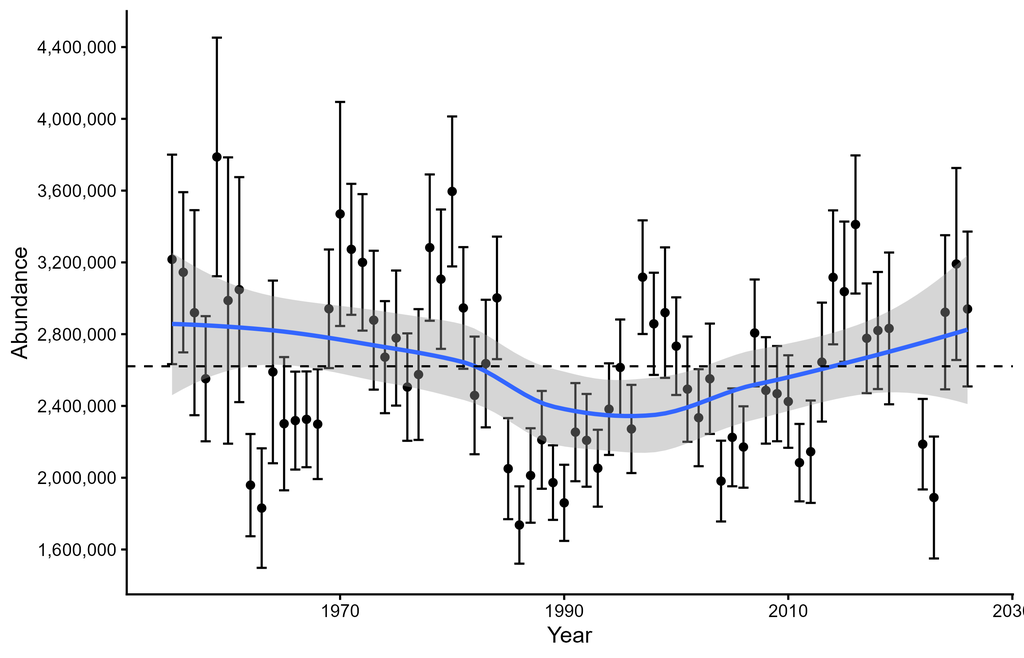

Figure 39: American wigeon abundance in the WBPHS Traditional Survey Area in spring. Circles are annual estimates of abundance with 95% confidence intervals. The blue line is a smoothed (Loess model) line with 95% confidence interval (shaded area) fit to the annual estimates. The black dashed reference line is the long term average.

### Data Table 55: American Green-winged Teal WBPHS

Original data source: WBPHS Traditional Survey Area; USFWS Headquarters.

Table 55. American green-winged teal abundance in the WBPHS Traditional Survey Area in spring, 1955-2026.

| Year | TSA | Area1 | Area2 | Area3 | Area4 | Area5 | Area6 | Area7 | Area8 |
| --- | --- | --- | --- | --- | --- | --- | --- | --- | --- |
| 1955 | 1,807,165 | 14,149 | 973,737 | 64,697 | 351,266 | 359,645 | 25,164 | 18,508 | 0 |
| 1956 | 1,525,315 | 17,723 | 770,238 | 35,572 | 182,240 | 484,260 | 17,830 | 17,452 | 0 |
| 1957 | 1,102,890 | 39,427 | 566,645 | 12,349 | 186,193 | 251,993 | 29,587 | 16,696 | 0 |
| 1958 | 1,347,428 | 72,550 | 792,217 | NA | 205,077 | 182,252 | 74,707 | 16,124 | 4,502 |
| 1959 | 2,653,435 | 77,855 | 1,982,535 | 97,097 | 324,350 | 110,034 | 45,866 | 15,698 | NA |
| 1960 | 1,426,915 | 25,347 | 885,305 | 12,208 | 262,316 | 205,506 | 20,183 | 16,049 | NA |
| 1961 | 1,729,269 | 47,269 | 1,152,447 | 16,179 | 320,587 | 101,737 | 64,857 | 16,705 | 9,488 |
| 1962 | 722,916 | 44,115 | 481,424 | 51,764 | 63,388 | 44,166 | 10,703 | 17,360 | 9,996 |
| 1963 | 1,242,290 | 64,313 | 893,582 | 51,400 | 72,773 | 73,759 | 63,606 | 20,166 | 2,691 |
| 1964 | 1,561,319 | 79,696 | 1,169,305 | 105,729 | 114,628 | 69,109 | 4,296 | 18,556 | NA |
| 1965 | 1,281,993 | 193,203 | 713,795 | 74,015 | 117,249 | 125,336 | 32,519 | 25,876 | NA |
| 1966 | 1,617,319 | 170,244 | 939,621 | 84,276 | 176,110 | 114,220 | 45,879 | 23,676 | 63,292 |
| 1967 | 1,593,690 | 275,091 | 533,176 | 101,286 | 174,972 | 367,714 | 75,090 | 53,898 | 12,463 |
| 1968 | 1,430,896 | 315,221 | 605,463 | 88,873 | 121,517 | 200,706 | 42,693 | 31,456 | 24,967 |
| 1969 | 1,491,016 | 202,629 | 257,604 | 151,370 | 204,538 | 408,781 | 161,478 | 14,346 | 90,270 |
| 1970 | 2,182,469 | 249,677 | 400,450 | 171,016 | 203,628 | 801,360 | 74,304 | 47,926 | 234,107 |
| 1971 | 1,889,342 | 321,359 | 566,347 | 170,359 | 263,317 | 386,865 | 120,819 | 21,479 | 38,798 |
| 1972 | 1,948,224 | 198,803 | 858,748 | 137,992 | 288,071 | 232,246 | 107,022 | 45,202 | 80,141 |
| 1973 | 1,949,204 | 217,550 | 728,358 | 123,847 | 311,867 | 331,195 | 117,316 | 72,231 | 46,840 |
| 1974 | 1,864,466 | 404,302 | 385,275 | 152,237 | 404,833 | 295,379 | 106,519 | 33,842 | 82,079 |
| 1975 | 1,664,842 | 108,607 | 564,923 | 134,450 | 230,776 | 412,817 | 63,428 | 86,661 | 63,180 |
| 1976 | 1,547,490 | 187,942 | 271,409 | 213,060 | 345,644 | 356,483 | 110,937 | 34,738 | 27,278 |
| 1977 | 1,285,810 | 207,933 | 469,994 | 231,400 | 151,905 | 168,132 | 35,361 | 17,548 | 3,537 |
| 1978 | 2,174,210 | 278,440 | 805,050 | 440,726 | 222,319 | 233,904 | 116,559 | 35,141 | 42,071 |
| 1979 | 2,071,738 | 254,062 | 789,552 | 333,895 | 256,774 | 315,995 | 36,700 | 60,885 | 23,875 |
| 1980 | 2,049,867 | 316,496 | 697,285 | 437,657 | 224,048 | 174,346 | 27,532 | 18,935 | 153,568 |
| 1981 | 1,910,501 | 516,139 | 758,757 | 207,967 | 180,132 | 140,851 | 37,264 | 27,814 | 41,577 |
| 1982 | 1,535,688 | 210,326 | 770,533 | 180,682 | 127,493 | 112,910 | 32,758 | 49,723 | 51,263 |
| 1983 | 1,874,974 | 260,505 | 964,870 | 219,636 | 136,150 | 172,386 | 49,448 | 25,340 | 46,640 |
| 1984 | 1,408,237 | 310,303 | 585,300 | 178,597 | 117,742 | 132,664 | 34,851 | 19,756 | 29,024 |
| 1985 | 1,475,406 | 264,973 | 673,017 | 134,599 | 106,661 | 179,903 | 19,307 | 14,219 | 82,727 |
| 1986 | 1,674,923 | 384,256 | 817,482 | 176,062 | 78,682 | 95,852 | 44,307 | 14,904 | 63,378 |
| 1987 | 2,006,242 | 362,445 | 1,127,056 | 209,900 | 120,282 | 85,813 | 37,831 | 12,248 | 50,667 |
| 1988 | 2,060,757 | 385,197 | 1,054,156 | 276,268 | 162,043 | 92,656 | 24,523 | 20,965 | 44,949 |
| 1989 | 1,841,674 | 402,147 | 956,313 | 173,726 | 106,049 | 115,474 | 36,945 | 32,719 | 18,301 |
| 1990 | 1,789,489 | 473,763 | 718,217 | 241,460 | 132,524 | 135,727 | 36,815 | 47,654 | 3,329 |
| 1991 | 1,557,776 | 546,682 | 453,658 | 225,742 | 131,086 | 131,756 | 30,382 | 32,976 | 5,494 |
| 1992 | 1,773,069 | 375,993 | 547,679 | 446,600 | 174,434 | 135,604 | 49,700 | 25,249 | 17,809 |
| 1993 | 1,694,463 | 444,632 | 570,783 | 398,155 | 175,929 | 77,817 | 3,176 | 11,963 | 12,008 |
| 1994 | 2,108,448 | 562,753 | 697,422 | 274,185 | 152,574 | 253,233 | 18,675 | 85,182 | 64,425 |
| 1995 | 2,300,594 | 556,196 | 749,504 | 308,353 | 245,312 | 271,327 | 35,299 | 45,021 | 89,582 |
| 1996 | 2,499,547 | 757,644 | 427,782 | 332,286 | 314,510 | 351,231 | 106,427 | 85,654 | 124,014 |
| 1997 | 2,506,585 | 512,275 | 608,084 | 367,697 | 324,417 | 418,509 | 69,069 | 95,411 | 111,124 |
| 1998 | 2,087,346 | 679,010 | 657,823 | 246,067 | 92,234 | 271,238 | 44,940 | 38,177 | 57,858 |
| 1999 | 2,630,962 | 679,434 | 984,397 | 271,847 | 190,546 | 342,245 | 40,652 | 68,093 | 53,748 |
| 2000 | 3,193,525 | 946,230 | 1,282,073 | 188,993 | 308,129 | 294,806 | 60,805 | 60,204 | 52,285 |
| 2001 | 2,508,656 | 1,028,811 | 741,645 | 181,401 | 190,496 | 202,321 | 31,463 | 63,517 | 69,002 |
| 2002 | 2,333,495 | 630,952 | 928,376 | 339,256 | 147,019 | 127,343 | 25,483 | 79,423 | 55,642 |
| 2003 | 2,678,494 | 1,035,264 | 766,994 | 307,813 | 131,788 | 272,568 | 48,436 | 85,304 | 30,327 |
| 2004 | 2,460,842 | 818,738 | 835,132 | 374,516 | 98,430 | 124,319 | 27,036 | 104,098 | 78,573 |
| 2005 | 2,156,911 | 713,019 | 437,456 | 309,515 | 158,538 | 358,954 | 54,984 | 82,866 | 41,579 |
| 2006 | 2,587,219 | 780,083 | 750,950 | 303,237 | 177,861 | 400,578 | 65,445 | 33,658 | 75,407 |
| 2007 | 2,890,271 | 822,805 | 862,204 | 307,449 | 283,152 | 495,010 | 33,294 | 43,626 | 42,730 |
| 2008 | 2,979,731 | 654,724 | 1,068,313 | 282,083 | 296,547 | 560,608 | 47,818 | 56,366 | 13,271 |
| 2009 | 3,443,599 | 658,474 | 1,225,393 | 398,571 | 175,479 | 648,384 | 47,842 | 174,513 | 114,942 |
| 2010 | 3,475,937 | 954,267 | 1,464,056 | 105,178 | 129,694 | 398,453 | 48,290 | 39,010 | 336,988 |
| 2011 | 2,900,096 | 641,361 | 1,250,642 | 126,177 | 275,376 | 421,959 | 55,249 | 19,011 | 110,322 |
| 2012 | 3,471,243 | 704,803 | 1,566,914 | 135,526 | 274,142 | 496,509 | 157,449 | 19,071 | 116,830 |
| 2013 | 3,053,444 | 451,814 | 1,228,778 | 358,000 | 195,500 | 575,226 | 60,223 | 22,518 | 161,385 |
| 2014 | 3,439,896 | 475,046 | 1,716,318 | 117,559 | 367,699 | 465,804 | 76,446 | 11,723 | 209,302 |
| 2015 | 4,080,923 | 565,591 | 2,333,261 | 140,498 | 327,325 | 451,796 | 99,075 | 56,472 | 106,905 |
| 2016 | 4,275,441 | 778,804 | 2,337,285 | 116,046 | 299,756 | 467,598 | 140,025 | 36,304 | 99,624 |
| 2017 | 3,605,276 | 616,665 | 1,816,126 | 136,116 | 341,617 | 472,348 | 74,600 | 26,545 | 121,259 |
| 2018 | 3,042,672 | 449,023 | 1,587,179 | 187,381 | 189,874 | 323,947 | 84,775 | 49,126 | 171,367 |
| 2019 | 3,178,219 | 416,404 | 1,680,781 | 218,873 | 301,495 | 277,259 | 71,891 | 44,677 | 166,839 |
| 2020 | NA | NA | NA | NA | NA | NA | NA | NA | NA |
| 2021 | NA | NA | NA | NA | NA | NA | NA | NA | NA |
| 2022 | 2,150,890 | 330,913 | 1,074,887 | 212,527 | 156,478 | 234,323 | 40,943 | 63,068 | 37,752 |
| 2023 | 2,502,585 | 126,323 | 1,581,478 | 275,941 | 165,234 | 186,969 | 30,740 | 71,716 | 64,183 |
| 2024 | 3,005,466 | 219,762 | 1,829,338 | 217,231 | 86,363 | 280,344 | 41,544 | 63,337 | 267,547 |
| 2025 | 2,550,173 | 196,379 | 1,418,515 | 160,067 | 166,000 | 354,267 | 33,606 | 99,366 | 121,973 |
| 2026 | 2,333,522 | 236,511 | 885,356 | 230,505 | 164,070 | 592,496 | 63,304 | 137,073 | 24,207 |

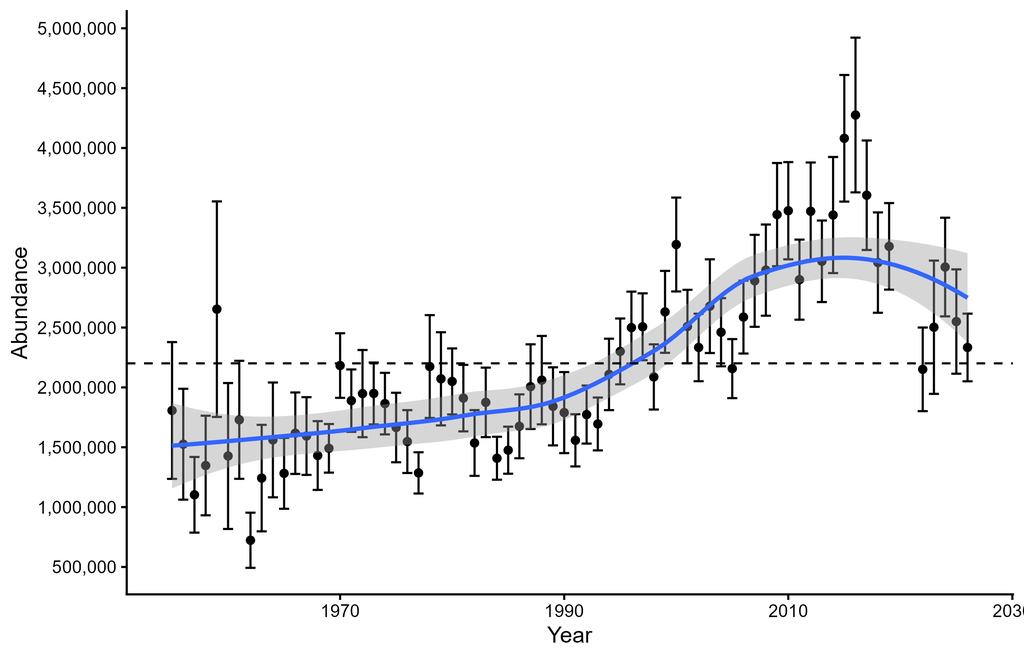

Figure 40: American green-winged teal abundance in the WBPHS Traditional Survey Area in spring. Circles are annual estimates of abundance with 95% confidence intervals. The blue line is a smoothed (Loess model) line with 95% confidence interval (shaded area) fit to the annual estimates. The black dashed reference line is the long term average.

### Data Table 56: Blue-winged Teal WBPHS

Original data source: WBPHS Traditional Survey Area; USFWS Headquarters.

Table 56. Blue-winged teal abundance in the WBPHS Traditional Survey Area in spring, 1955-2026.

| Year | TSA | Area1 | Area2 | Area3 | Area4 | Area5 | Area6 | Area7 | Area8 |
| --- | --- | --- | --- | --- | --- | --- | --- | --- | --- |
| 1955 | 5,305,238 | 0 | 342,817 | 57,999 | 1,550,238 | 2,068,507 | 470,599 | 114,433 | 700,646 |
| 1956 | 4,997,646 | 0 | 292,797 | 64,575 | 903,759 | 2,542,739 | 284,709 | 115,558 | 793,509 |
| 1957 | 4,299,499 | 0 | 40,330 | 41,342 | 908,556 | 1,924,310 | 391,256 | 117,797 | 875,908 |
| 1958 | 5,456,584 | 0 | 201,348 | 221,457 | 1,078,543 | 1,650,704 | 1,120,162 | 131,117 | 1,053,254 |
| 1959 | 5,099,309 | 0 | 911,885 | 147,199 | 903,562 | 1,087,019 | 1,247,586 | 129,505 | 672,553 |
| 1960 | 4,292,995 | 0 | 417,421 | 70,785 | 877,793 | 1,112,769 | 699,198 | 97,343 | 1,017,686 |
| 1961 | 3,655,304 | 0 | 578,862 | 35,981 | 897,110 | 583,022 | 521,299 | 193,405 | 845,625 |
| 1962 | 3,011,051 | 0 | 244,421 | 241,665 | 346,740 | 383,752 | 368,354 | 140,238 | 1,285,881 |
| 1963 | 3,723,624 | 0 | 128,013 | 306,825 | 426,848 | 504,893 | 401,535 | 145,736 | 1,809,774 |
| 1964 | 4,020,614 | 0 | 508,488 | 444,908 | 634,556 | 735,756 | 358,838 | 138,975 | 1,199,093 |
| 1965 | 3,594,457 | 57 | 227,581 | 164,890 | 494,085 | 669,095 | 284,199 | 236,025 | 1,518,525 |
| 1966 | 3,733,241 | 0 | 141,100 | 137,311 | 533,204 | 909,736 | 213,050 | 241,588 | 1,557,252 |
| 1967 | 4,491,525 | 1,128 | 21,248 | 230,182 | 712,934 | 1,395,676 | 627,614 | 216,205 | 1,286,538 |
| 1968 | 3,462,528 | 1,452 | 29,994 | 803,335 | 325,319 | 720,229 | 313,137 | 135,704 | 1,133,358 |
| 1969 | 4,138,588 | 0 | 46,083 | 521,952 | 363,220 | 966,589 | 445,767 | 251,456 | 1,543,521 |
| 1970 | 4,861,825 | 9,921 | 50,600 | 616,159 | 440,876 | 1,552,614 | 672,922 | 196,216 | 1,322,517 |
| 1971 | 4,610,201 | 2,109 | 114,266 | 194,446 | 714,293 | 1,291,387 | 314,268 | 224,502 | 1,754,930 |
| 1972 | 4,278,529 | 0 | 152,572 | 205,673 | 494,851 | 1,012,888 | 406,256 | 294,311 | 1,711,978 |
| 1973 | 3,332,530 | 0 | 48,825 | 162,834 | 459,217 | 887,888 | 399,443 | 127,551 | 1,246,772 |
| 1974 | 4,976,222 | 0 | 99,983 | 69,724 | 1,209,712 | 1,312,215 | 686,767 | 182,268 | 1,415,552 |
| 1975 | 5,885,357 | 0 | 285,659 | 183,452 | 1,108,175 | 2,360,150 | 360,989 | 290,998 | 1,295,934 |
| 1976 | 4,744,744 | 0 | 158,415 | 395,957 | 820,335 | 1,799,610 | 654,609 | 433,974 | 481,843 |
| 1977 | 4,462,839 | 2,783 | 635,514 | 454,609 | 750,958 | 1,631,307 | 292,917 | 284,207 | 410,545 |
| 1978 | 4,498,618 | 3,561 | 385,951 | 415,711 | 393,236 | 902,361 | 279,164 | 319,585 | 1,799,049 |
| 1979 | 4,875,866 | 0 | 280,595 | 228,824 | 592,923 | 1,482,802 | 440,752 | 293,195 | 1,556,775 |
| 1980 | 4,895,079 | 3,561 | 470,163 | 514,304 | 834,569 | 1,307,164 | 290,224 | 234,364 | 1,240,730 |
| 1981 | 3,720,649 | 4,033 | 411,820 | 532,598 | 1,148,075 | 781,509 | 253,899 | 133,044 | 455,670 |
| 1982 | 3,657,565 | 0 | 234,742 | 391,955 | 498,144 | 605,878 | 289,639 | 478,301 | 1,158,906 |
| 1983 | 3,366,531 | 1,453 | 149,309 | 179,399 | 419,133 | 963,207 | 226,642 | 347,701 | 1,079,686 |
| 1984 | 3,979,328 | 4,892 | 322,463 | 206,231 | 429,216 | 993,592 | 171,008 | 229,649 | 1,622,277 |
| 1985 | 3,502,357 | NA | 200,587 | 316,734 | 295,318 | 1,327,329 | 172,344 | 186,673 | 1,003,372 |
| 1986 | 4,478,820 | 5,949 | 455,829 | 125,306 | 361,868 | 876,499 | 326,546 | 186,710 | 2,140,113 |
| 1987 | 3,528,696 | 1,546 | 440,556 | 215,234 | 596,632 | 674,828 | 203,180 | 189,797 | 1,206,923 |
| 1988 | 4,011,108 | 13,317 | 580,403 | 656,721 | 552,905 | 755,343 | 197,853 | 300,007 | 954,559 |
| 1989 | 3,125,255 | 1,057 | 237,540 | 449,148 | 418,152 | 578,438 | 176,409 | 187,383 | 1,077,128 |
| 1990 | 2,776,382 | NA | 189,374 | 268,792 | 521,168 | 875,476 | 268,593 | 194,599 | 458,380 |
| 1991 | 3,763,687 | NA | 207,047 | 444,672 | 580,235 | 936,689 | 208,517 | 267,962 | 1,118,565 |
| 1992 | 4,333,105 | NA | 314,834 | 445,877 | 716,094 | 1,362,432 | 376,989 | 223,865 | 893,013 |
| 1993 | 3,192,940 | 2,906 | 260,586 | 520,354 | 526,558 | 570,072 | 269,188 | 192,419 | 850,858 |
| 1994 | 4,616,162 | NA | 194,188 | 223,593 | 466,610 | 980,162 | 92,783 | 752,000 | 1,906,825 |
| 1995 | 5,140,010 | 2,906 | 166,120 | 124,061 | 430,834 | 1,088,351 | 301,793 | 396,430 | 2,629,515 |
| 1996 | 6,407,422 | NA | 194,521 | 120,519 | 505,871 | 2,046,644 | 295,524 | 441,590 | 2,802,753 |
| 1997 | 6,124,267 | NA | 203,804 | 69,514 | 358,461 | 1,974,360 | 300,397 | 472,655 | 2,745,075 |
| 1998 | 6,398,812 | NA | 339,948 | 156,556 | 521,876 | 1,589,022 | 257,901 | 736,908 | 2,796,600 |
| 1999 | 7,149,486 | NA | 206,286 | 175,085 | 391,543 | 2,110,905 | 439,555 | 558,969 | 3,267,143 |
| 2000 | 7,431,442 | NA | 274,876 | 125,944 | 577,823 | 1,622,427 | 355,035 | 237,768 | 4,237,569 |
| 2001 | 5,756,998 | NA | 119,315 | 148,146 | 367,782 | 1,267,464 | 484,127 | 157,748 | 3,212,416 |
| 2002 | 4,206,479 | NA | 303,541 | 306,746 | 244,160 | 667,137 | 230,101 | 249,248 | 2,205,546 |
| 2003 | 5,518,162 | 2,906 | 314,303 | 182,141 | 322,586 | 1,918,273 | 419,729 | 419,403 | 1,938,820 |
| 2004 | 4,073,034 | 2,219 | 400,612 | 60,411 | 360,165 | 1,154,742 | 282,315 | 319,771 | 1,492,800 |
| 2005 | 4,585,518 | 2,784 | 247,373 | 139,219 | 649,154 | 1,597,006 | 338,684 | 286,389 | 1,324,910 |
| 2006 | 5,859,567 | NA | 315,531 | 81,520 | 864,306 | 2,228,084 | 425,609 | 346,391 | 1,598,125 |
| 2007 | 6,707,612 | 9,330 | 368,681 | 121,155 | 668,503 | 2,379,813 | 274,009 | 276,588 | 2,609,533 |
| 2008 | 6,640,096 | NA | 393,323 | 86,815 | 817,658 | 2,317,671 | 264,875 | 234,607 | 2,525,148 |
| 2009 | 7,383,834 | NA | 248,148 | 116,131 | 480,406 | 1,739,781 | 302,916 | 344,580 | 4,151,873 |
| 2010 | 6,328,511 | 3,913 | 278,864 | 4,521 | 293,600 | 1,363,233 | 211,791 | 307,798 | 3,864,790 |
| 2011 | 8,948,451 | 1,461 | 144,136 | 30,576 | 470,380 | 2,488,852 | 392,617 | 894,204 | 4,526,224 |
| 2012 | 9,242,268 | NA | 146,926 | 50,720 | 595,745 | 2,607,562 | 327,436 | 661,138 | 4,852,740 |
| 2013 | 7,731,668 | NA | 386,098 | 39,715 | 751,567 | 2,758,507 | 345,148 | 225,912 | 3,224,721 |
| 2014 | 8,541,534 | NA | 377,388 | 45,956 | 834,316 | 3,109,225 | 474,127 | 1,177,845 | 2,522,678 |
| 2015 | 8,547,299 | NA | 359,937 | 94,188 | 1,168,852 | 3,566,905 | 522,495 | 618,183 | 2,216,738 |
| 2016 | 6,689,361 | NA | 446,683 | 134,649 | 897,674 | 2,103,710 | 331,939 | 638,532 | 2,136,175 |
| 2017 | 7,888,918 | NA | 578,857 | 46,847 | 1,643,941 | 2,820,489 | 300,000 | 528,433 | 1,970,351 |
| 2018 | 6,450,456 | NA | 489,777 | 71,143 | 1,171,038 | 1,700,196 | 340,721 | 398,521 | 2,279,060 |
| 2019 | 5,427,612 | NA | 711,258 | 5,217 | 706,901 | 931,879 | 157,593 | 198,147 | 2,716,617 |
| 2020 | NA | NA | NA | NA | NA | NA | NA | NA | NA |
| 2021 | NA | NA | NA | NA | NA | NA | NA | NA | NA |
| 2022 | 6,491,075 | 11,164 | 670,398 | 75,050 | 453,978 | 1,214,162 | 353,457 | 439,944 | 3,272,923 |
| 2023 | 5,250,313 | NA | 569,574 | 61,359 | 450,907 | 1,404,676 | 203,639 | 551,020 | 2,009,138 |
| 2024 | 4,598,953 | NA | 677,159 | 71,822 | 587,964 | 930,224 | 196,682 | 441,935 | 1,693,168 |
| 2025 | 4,431,736 | NA | 552,230 | 44,891 | 573,205 | 1,108,909 | 280,068 | 478,135 | 1,394,297 |
| 2026 | 3,961,875 | NA | 489,765 | 200,955 | 426,587 | 1,320,064 | 163,645 | 267,309 | 1,093,549 |

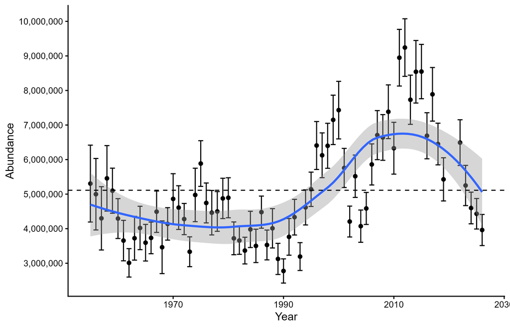

Figure 41: Blue-winged teal abundance in the WBPHS Traditional Survey Area in spring. Circles are annual estimates of abundance with 95% confidence intervals. The blue line is a smoothed (Loess model) line with 95% confidence interval (shaded area) fit to the annual estimates. The black dashed reference line is the long term average.

### Data Table 57: Northern Shoveler WBPHS

Original data source: WBPHS Traditional Survey Area; USFWS Headquarters.

Table 57. Northern shoveler abundance in the WBPHS Traditional Survey Area in spring, 1955-2026.

| Year | TSA | Area1 | Area2 | Area3 | Area4 | Area5 | Area6 | Area7 | Area8 |
| --- | --- | --- | --- | --- | --- | --- | --- | --- | --- |
| 1955 | 1,642,809 | 2,530 | 289,199 | 6,867 | 397,210 | 667,073 | 54,728 | 78,979 | 146,222 |
| 1956 | 1,781,409 | 2,723 | 194,706 | 1,927 | 404,963 | 854,377 | 66,519 | 76,381 | 179,813 |
| 1957 | 1,476,104 | 5,105 | 104,017 | 7,931 | 349,831 | 637,868 | 85,433 | 75,419 | 210,500 |
| 1958 | 1,383,766 | 18,179 | 232,741 | 3,503 | 442,257 | 335,357 | 83,397 | 77,352 | 190,980 |
| 1959 | 1,577,591 | 14,167 | 603,841 | 57,186 | 321,119 | 264,463 | 160,841 | 78,337 | 77,637 |
| 1960 | 1,824,513 | 13,267 | 202,540 | 17,426 | 431,919 | 604,342 | 142,542 | 72,900 | 339,577 |
| 1961 | 1,382,962 | 24,007 | 409,699 | 16,676 | 303,463 | 233,867 | 121,437 | 78,229 | 195,584 |
| 1962 | 1,268,952 | 13,804 | 215,592 | 35,428 | 196,817 | 79,804 | 49,457 | 86,828 | 591,222 |
| 1963 | 1,398,436 | 9,348 | 129,580 | 41,211 | 378,016 | 196,937 | 124,473 | 106,730 | 412,141 |
| 1964 | 1,718,260 | 11,750 | 493,763 | 103,347 | 341,960 | 375,309 | 119,808 | 96,488 | 175,836 |
| 1965 | 1,423,657 | 28,074 | 201,416 | 71,834 | 276,232 | 293,647 | 107,196 | 84,684 | 360,573 |
| 1966 | 2,146,961 | 29,486 | 192,533 | 63,181 | 470,839 | 809,890 | 99,257 | 108,600 | 373,176 |
| 1967 | 2,314,697 | 24,225 | 142,084 | 47,640 | 538,540 | 807,683 | 170,010 | 168,133 | 416,383 |
| 1968 | 1,684,488 | 150,176 | 110,788 | 48,949 | 394,635 | 479,420 | 77,178 | 144,180 | 279,161 |
| 1969 | 2,156,783 | 58,347 | 65,531 | 61,772 | 433,252 | 777,381 | 151,188 | 184,667 | 424,645 |
| 1970 | 2,230,414 | 85,431 | 77,653 | 70,766 | 329,082 | 760,655 | 126,678 | 144,170 | 635,979 |
| 1971 | 2,011,420 | 37,814 | 141,064 | 44,899 | 423,593 | 907,672 | 68,253 | 125,635 | 262,490 |
| 1972 | 2,466,458 | 68,324 | 197,432 | 42,166 | 435,736 | 921,903 | 119,047 | 131,508 | 550,342 |
| 1973 | 1,619,001 | 72,394 | 167,736 | 38,881 | 466,095 | 538,385 | 47,958 | 88,589 | 198,964 |
| 1974 | 2,011,299 | 139,602 | 135,281 | 16,903 | 587,970 | 705,214 | 97,552 | 112,090 | 216,687 |
| 1975 | 1,980,758 | 40,928 | 145,045 | 44,519 | 550,321 | 730,330 | 51,295 | 201,063 | 217,256 |
| 1976 | 1,748,066 | 83,955 | 89,765 | 20,230 | 325,035 | 822,932 | 157,731 | 131,593 | 116,826 |
| 1977 | 1,451,847 | 199,386 | 327,871 | 81,326 | 220,775 | 422,711 | 38,935 | 67,789 | 93,054 |
| 1978 | 1,975,298 | 218,676 | 85,836 | 44,191 | 258,970 | 426,651 | 65,159 | 298,235 | 577,581 |
| 1979 | 2,406,509 | 110,648 | 121,657 | 25,881 | 391,405 | 692,352 | 85,859 | 282,819 | 695,888 |
| 1980 | 1,908,201 | 392,743 | 232,671 | 49,266 | 388,768 | 494,687 | 56,678 | 67,069 | 226,319 |
| 1981 | 2,333,551 | 622,873 | 260,205 | 58,844 | 503,911 | 335,314 | 99,799 | 205,437 | 247,169 |
| 1982 | 2,147,638 | 161,282 | 99,469 | 41,604 | 320,364 | 699,031 | 135,382 | 247,130 | 443,376 |
| 1983 | 1,875,652 | 186,586 | 83,435 | 34,725 | 200,299 | 792,829 | 121,693 | 150,321 | 305,765 |
| 1984 | 1,618,247 | 235,308 | 163,402 | 38,201 | 187,302 | 370,934 | 47,806 | 155,060 | 420,235 |
| 1985 | 1,702,092 | 176,998 | 118,511 | 37,565 | 321,237 | 670,984 | 76,351 | 77,839 | 222,607 |
| 1986 | 2,128,193 | 264,923 | 237,038 | 16,791 | 220,715 | 538,761 | 156,167 | 129,909 | 563,889 |
| 1987 | 1,950,177 | 326,707 | 223,152 | 50,989 | 330,681 | 375,780 | 87,331 | 144,488 | 411,049 |
| 1988 | 1,680,920 | 404,050 | 258,445 | 88,230 | 165,576 | 428,308 | 99,826 | 85,261 | 151,224 |
| 1989 | 1,538,342 | 294,518 | 271,973 | 41,556 | 227,934 | 243,769 | 56,016 | 86,185 | 316,391 |
| 1990 | 1,759,343 | 361,987 | 261,932 | 55,164 | 322,514 | 447,811 | 77,326 | 115,048 | 117,561 |
| 1991 | 1,716,185 | 362,656 | 221,594 | 53,209 | 294,468 | 473,397 | 66,919 | 73,929 | 170,013 |
| 1992 | 1,954,371 | 365,876 | 284,670 | 108,775 | 241,407 | 571,923 | 137,890 | 48,294 | 195,536 |
| 1993 | 2,046,469 | 448,826 | 263,221 | 44,132 | 421,143 | 327,371 | 60,507 | 162,251 | 319,018 |
| 1994 | 2,912,021 | 499,960 | 166,712 | 58,163 | 421,445 | 737,458 | 42,640 | 335,557 | 650,087 |
| 1995 | 2,854,877 | 464,560 | 127,581 | 85,888 | 267,573 | 763,877 | 140,376 | 139,753 | 865,269 |
| 1996 | 3,448,958 | 481,325 | 117,834 | 35,676 | 373,845 | 1,212,812 | 176,733 | 207,100 | 843,632 |
| 1997 | 4,120,384 | 497,236 | 204,387 | 37,814 | 443,177 | 1,660,718 | 161,391 | 424,517 | 691,144 |
| 1998 | 3,183,223 | 852,469 | 394,370 | 43,325 | 329,423 | 790,546 | 91,713 | 191,142 | 490,235 |
| 1999 | 3,889,548 | 658,478 | 219,006 | 26,681 | 408,219 | 1,281,260 | 160,899 | 424,780 | 710,225 |
| 2000 | 3,520,738 | 846,385 | 247,967 | 36,271 | 380,429 | 899,774 | 175,829 | 160,551 | 773,531 |
| 2001 | 3,313,505 | 666,271 | 203,692 | 27,769 | 267,780 | 718,127 | 199,358 | 151,846 | 1,078,663 |
| 2002 | 2,318,192 | 580,831 | 371,369 | 38,432 | 273,949 | 310,154 | 100,174 | 136,341 | 506,942 |
| 2003 | 3,619,573 | 670,867 | 318,274 | 10,068 | 448,369 | 1,437,742 | 123,026 | 246,543 | 364,684 |
| 2004 | 2,810,431 | 642,604 | 246,511 | 32,816 | 384,649 | 783,624 | 142,871 | 200,028 | 377,327 |
| 2005 | 3,591,472 | 666,202 | 213,074 | 28,612 | 547,641 | 1,313,596 | 210,530 | 148,226 | 463,591 |
| 2006 | 3,680,225 | 408,631 | 192,543 | 11,864 | 700,753 | 1,611,641 | 177,794 | 163,274 | 413,726 |
| 2007 | 4,552,843 | 579,501 | 345,992 | 28,171 | 977,152 | 1,655,879 | 115,759 | 168,582 | 681,806 |
| 2008 | 3,507,828 | 465,722 | 322,333 | 37,215 | 617,572 | 1,183,784 | 89,552 | 134,481 | 657,168 |
| 2009 | 4,376,320 | 463,818 | 292,533 | 15,988 | 526,801 | 893,708 | 136,599 | 407,907 | 1,638,969 |
| 2010 | 4,057,429 | 626,117 | 296,698 | 3,667 | 475,055 | 794,998 | 87,073 | 220,645 | 1,553,176 |
| 2011 | 4,640,970 | 322,344 | 132,881 | 6,889 | 877,635 | 1,496,025 | 148,478 | 429,714 | 1,227,002 |
| 2012 | 5,017,561 | 376,760 | 274,657 | 11,117 | 914,995 | 1,857,662 | 137,772 | 340,613 | 1,103,986 |
| 2013 | 4,751,030 | 226,100 | 348,463 | 35,325 | 852,691 | 1,705,834 | 148,999 | 170,425 | 1,263,192 |
| 2014 | 5,278,857 | 372,368 | 371,612 | 23,876 | 914,033 | 1,711,046 | 255,034 | 521,102 | 1,109,787 |
| 2015 | 4,391,435 | 396,574 | 454,468 | 19,770 | 887,182 | 1,692,399 | 130,760 | 296,848 | 513,434 |
| 2016 | 3,966,902 | 560,476 | 785,611 | 17,131 | 460,942 | 1,206,910 | 119,069 | 209,216 | 607,547 |
| 2017 | 4,353,052 | 433,549 | 584,042 | 18,988 | 871,814 | 1,500,832 | 125,625 | 218,453 | 599,749 |
| 2018 | 4,207,913 | 367,032 | 415,035 | 22,135 | 1,027,228 | 1,066,001 | 109,242 | 387,236 | 814,004 |
| 2019 | 3,649,242 | 321,788 | 335,070 | 19,965 | 715,737 | 820,411 | 60,419 | 309,077 | 1,066,774 |
| 2020 | NA | NA | NA | NA | NA | NA | NA | NA | NA |
| 2021 | NA | NA | NA | NA | NA | NA | NA | NA | NA |
| 2022 | 3,036,336 | 373,572 | 410,469 | 15,001 | 325,723 | 740,784 | 147,530 | 231,228 | 792,029 |
| 2023 | 2,858,356 | 127,922 | 419,838 | 33,362 | 299,331 | 923,841 | 83,182 | 282,047 | 688,833 |
| 2024 | 2,645,811 | 204,567 | 430,308 | 17,802 | 306,279 | 827,950 | 62,197 | 227,788 | 568,920 |
| 2025 | 2,758,185 | 178,534 | 305,260 | 17,167 | 396,585 | 1,016,222 | 68,414 | 210,068 | 565,935 |
| 2026 | 3,288,728 | 162,517 | 445,917 | 45,638 | 478,796 | 1,551,091 | 79,986 | 177,661 | 347,123 |

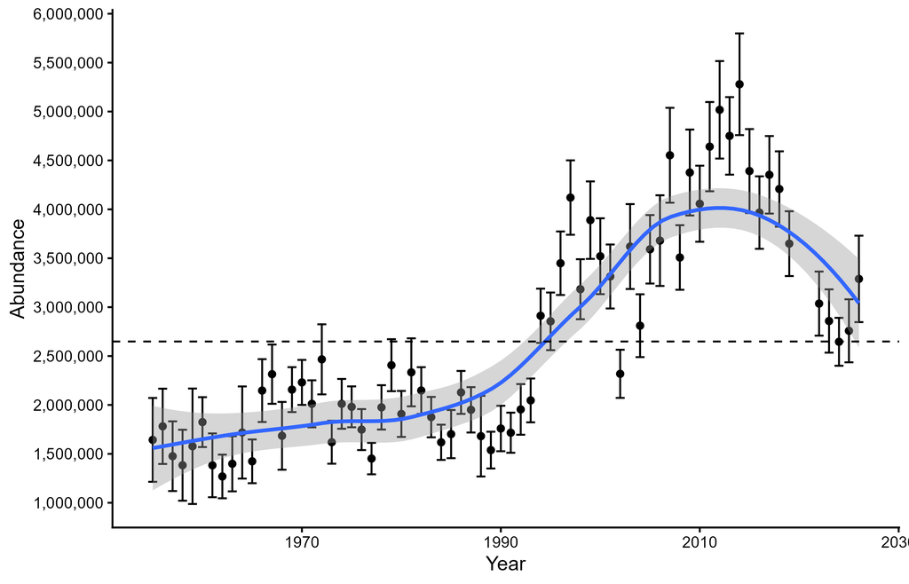

Figure 42: Northern shoveler abundance in the WBPHS Traditional Survey Area in spring. Circles are annual estimates of abundance with 95% confidence intervals. The blue line is a smoothed (Loess model) line with 95% confidence interval (shaded area) fit to the annual estimates. The black dashed reference line is the long term average.

### Data Table 58: Canvasback WBPHS

Original data source: WBPHS Traditional Survey Area; USFWS Headquarters.

Table 58. Canvasback abundance in the WBPHS Traditional Survey Area in spring, 1955-2026.

| Year | TSA | Area1 | Area2 | Area3 | Area4 | Area5 | Area6 | Area7 | Area8 |
| --- | --- | --- | --- | --- | --- | --- | --- | --- | --- |
| 1955 | 589,257 | 48,591 | 52,742 | 66,172 | 96,240 | 266,234 | 36,663 | 9,037 | 13,579 |
| 1956 | 698,509 | 50,247 | 26,406 | 41,416 | 98,733 | 397,376 | 60,686 | 8,292 | 15,353 |
| 1957 | 626,072 | 59,367 | 25,063 | 5,889 | 100,592 | 362,043 | 48,505 | 7,670 | 16,943 |
| 1958 | 746,830 | 39,289 | 75,646 | 54,839 | 168,707 | 249,673 | 118,030 | 7,135 | 33,511 |
| 1959 | 488,684 | 77,409 | 80,638 | 115,612 | 78,148 | 81,192 | 39,344 | 6,669 | 9,671 |
| 1960 | 605,698 | 85,593 | 56,821 | 190,320 | 58,254 | 118,071 | 75,702 | 6,328 | 14,609 |
| 1961 | 435,251 | 14,690 | 50,009 | 118,937 | 63,861 | 120,986 | 54,850 | 6,058 | 5,859 |
| 1962 | 360,238 | 22,732 | 32,739 | 21,914 | 54,620 | 175,656 | 42,264 | 5,850 | 4,463 |
| 1963 | 506,235 | 69,254 | 100,405 | 87,131 | 77,628 | 90,882 | 57,910 | 5,833 | 17,193 |
| 1964 | 643,636 | 77,777 | 89,014 | 181,051 | 83,828 | 107,655 | 76,516 | 5,585 | 22,211 |
| 1965 | 522,120 | 66,523 | 44,632 | 77,211 | 100,526 | 126,493 | 82,630 | 3,460 | 20,645 |
| 1966 | 663,114 | 96,656 | 151,538 | 53,128 | 68,517 | 167,823 | 65,224 | 1,934 | 58,294 |
| 1967 | 502,576 | 48,854 | 33,354 | 78,146 | 97,884 | 137,480 | 75,248 | 1,598 | 30,012 |
| 1968 | 563,691 | 140,795 | 106,678 | 100,211 | 57,901 | 99,523 | 35,178 | 3,487 | 19,918 |
| 1969 | 503,530 | 63,450 | 76,527 | 30,416 | 26,683 | 162,416 | 61,754 | 5,543 | 76,742 |
| 1970 | 580,100 | 42,606 | 44,076 | 124,001 | 49,437 | 238,949 | 46,629 | 4,131 | 30,271 |
| 1971 | 450,674 | 46,233 | 49,169 | 21,773 | 39,010 | 202,092 | 69,283 | 5,631 | 17,483 |
| 1972 | 425,912 | 92,862 | 26,701 | 21,318 | 65,481 | 135,333 | 33,124 | 13,647 | 37,446 |
| 1973 | 620,451 | 127,100 | 50,780 | 73,488 | 54,039 | 228,926 | 34,909 | 15,564 | 35,645 |
| 1974 | 512,842 | 81,750 | 29,007 | 15,046 | 100,193 | 181,819 | 34,370 | 2,234 | 68,423 |
| 1975 | 595,098 | 39,393 | 64,269 | 35,044 | 78,945 | 252,884 | 77,565 | 2,112 | 44,885 |
| 1976 | 614,389 | 48,531 | 40,110 | 44,965 | 52,081 | 283,277 | 110,778 | 24,270 | 10,378 |
| 1977 | 664,042 | 168,622 | 49,316 | 50,400 | 64,639 | 256,461 | 58,162 | 7,040 | 9,401 |
| 1978 | 373,174 | 48,519 | 33,318 | 38,101 | 51,218 | 128,997 | 37,283 | 7,762 | 27,976 |
| 1979 | 582,004 | 62,365 | 51,826 | 25,412 | 53,462 | 280,931 | 49,316 | 22,487 | 36,204 |
| 1980 | 734,570 | 152,230 | 66,440 | 59,421 | 62,125 | 307,205 | 45,835 | 7,347 | 33,967 |
| 1981 | 620,843 | 133,576 | 133,507 | 85,126 | 49,418 | 110,099 | 65,875 | 5,357 | 37,885 |
| 1982 | 513,265 | 100,272 | 49,927 | 40,740 | 73,779 | 151,895 | 49,479 | 12,521 | 34,651 |
| 1983 | 526,612 | 109,231 | 68,981 | 32,987 | 49,684 | 212,701 | 33,382 | 6,494 | 13,152 |
| 1984 | 530,129 | 118,223 | 80,016 | 39,187 | 26,610 | 157,655 | 38,249 | 6,023 | 64,166 |
| 1985 | 375,929 | 80,541 | 14,107 | 33,546 | 56,591 | 118,752 | 45,576 | 3,100 | 23,715 |
| 1986 | 438,350 | 84,647 | 54,994 | 13,337 | 59,172 | 127,229 | 48,363 | 2,828 | 47,780 |
| 1987 | 450,109 | 99,281 | 27,809 | 13,565 | 53,490 | 184,156 | 36,467 | 980 | 34,361 |
| 1988 | 435,048 | 77,259 | 67,697 | 49,823 | 54,769 | 119,017 | 37,464 | 5,673 | 23,346 |
| 1989 | 477,439 | 131,649 | 110,005 | 34,490 | 36,657 | 81,515 | 33,480 | 7,048 | 42,595 |
| 1990 | 539,318 | 193,058 | 67,559 | 40,224 | 78,128 | 79,699 | 51,597 | 13,337 | 15,716 |
| 1991 | 491,151 | 125,852 | 80,103 | 38,106 | 58,413 | 130,547 | 43,289 | 2,059 | 12,782 |
| 1992 | 481,529 | 93,592 | 60,473 | 113,709 | 32,760 | 95,740 | 60,952 | 7,626 | 16,677 |
| 1993 | 472,055 | 82,469 | 127,926 | 52,609 | 45,856 | 93,027 | 32,976 | 11,556 | 25,636 |
| 1994 | 525,604 | 81,169 | 69,841 | 81,469 | 63,970 | 117,734 | 28,232 | 15,422 | 67,768 |
| 1995 | 770,593 | 125,595 | 120,157 | 32,559 | 60,492 | 282,285 | 91,838 | 12,222 | 45,445 |
| 1996 | 848,487 | 157,513 | 136,007 | 49,797 | 66,975 | 282,952 | 83,032 | 8,782 | 63,429 |
| 1997 | 688,754 | 44,986 | 93,403 | 50,341 | 68,518 | 280,056 | 63,531 | 15,857 | 72,063 |
| 1998 | 685,862 | 105,259 | 100,346 | 38,299 | 68,550 | 246,948 | 66,465 | 8,573 | 51,422 |
| 1999 | 716,039 | 88,957 | 151,409 | 45,480 | 56,133 | 253,376 | 70,515 | 6,876 | 43,292 |
| 2000 | 706,754 | 186,670 | 83,430 | 36,591 | 73,179 | 232,189 | 63,684 | 6,899 | 24,112 |
| 2001 | 579,826 | 89,029 | 62,722 | 31,565 | 31,885 | 232,199 | 56,310 | 5,851 | 70,264 |
| 2002 | 486,597 | 135,323 | 121,025 | 37,651 | 14,481 | 73,255 | 63,272 | 6,288 | 35,303 |
| 2003 | 557,575 | 88,976 | 115,123 | 13,230 | 69,687 | 194,783 | 41,815 | 11,357 | 22,603 |
| 2004 | 617,227 | 161,344 | 109,270 | 49,815 | 50,159 | 120,932 | 70,055 | 11,978 | 43,676 |
| 2005 | 520,574 | 95,049 | 97,516 | 39,193 | 42,688 | 162,444 | 47,658 | 4,788 | 31,238 |
| 2006 | 691,013 | 73,236 | 109,426 | 12,774 | 76,283 | 286,689 | 87,474 | 12,305 | 32,826 |
| 2007 | 864,924 | 91,717 | 138,910 | 34,160 | 127,296 | 324,344 | 77,250 | 16,751 | 54,494 |
| 2008 | 488,667 | 71,924 | 83,901 | 23,334 | 78,940 | 166,331 | 30,524 | 8,723 | 24,991 |
| 2009 | 662,135 | 41,301 | 88,111 | 48,730 | 51,880 | 280,330 | 48,396 | 25,980 | 77,407 |
| 2010 | 585,164 | 56,884 | 71,544 | 18,247 | 39,136 | 192,482 | 34,693 | 41,055 | 131,123 |
| 2011 | 691,560 | 22,487 | 51,093 | 30,527 | 33,131 | 334,961 | 67,628 | 16,965 | 134,767 |
| 2012 | 759,935 | 34,998 | 92,511 | 26,839 | 145,592 | 312,992 | 52,486 | 10,431 | 84,085 |
| 2013 | 786,978 | 34,505 | 92,287 | 30,027 | 54,318 | 381,353 | 61,998 | 13,462 | 119,029 |
| 2014 | 685,262 | 20,863 | 61,830 | 22,993 | 71,445 | 324,800 | 59,423 | 15,423 | 108,485 |
| 2015 | 757,281 | 40,808 | 109,174 | 35,379 | 114,350 | 270,237 | 37,511 | 18,103 | 131,720 |
| 2016 | 736,472 | 77,946 | 143,918 | 35,219 | 72,085 | 256,417 | 67,700 | 19,998 | 63,190 |
| 2017 | 732,531 | 86,565 | 110,494 | 36,521 | 63,725 | 295,239 | 76,617 | 13,585 | 49,783 |
| 2018 | 686,084 | 84,853 | 107,592 | 42,571 | 72,545 | 208,248 | 80,561 | 28,502 | 61,213 |
| 2019 | 651,925 | 78,336 | 105,855 | 24,659 | 133,180 | 160,143 | 56,053 | 30,131 | 63,568 |
| 2020 | NA | NA | NA | NA | NA | NA | NA | NA | NA |
| 2021 | NA | NA | NA | NA | NA | NA | NA | NA | NA |
| 2022 | 586,643 | 31,679 | 119,042 | 21,508 | 70,956 | 192,554 | 82,526 | 13,488 | 54,889 |
| 2023 | 618,898 | 55,792 | 85,240 | 18,654 | 59,519 | 243,109 | 82,498 | 15,917 | 58,169 |
| 2024 | 566,319 | 68,035 | 55,726 | 29,085 | 45,005 | 196,880 | 85,470 | 14,323 | 71,795 |
| 2025 | 690,238 | 52,909 | 107,634 | 52,285 | 48,863 | 245,845 | 58,092 | 12,657 | 111,953 |
| 2026 | 781,619 | 97,339 | 131,690 | 56,986 | 76,065 | 234,289 | 62,701 | 33,129 | 89,419 |

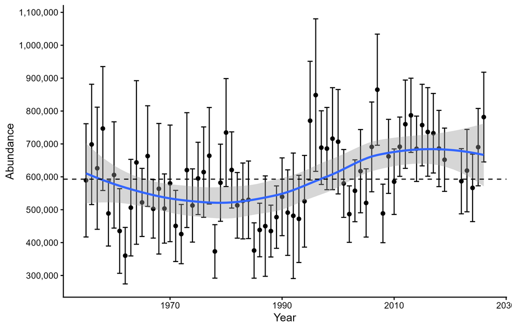

Figure 43: Canvasback abundance in the WBPHS Traditional Survey Area in spring. Circles are annual estimates of abundance with 95% confidence intervals. The blue line is a smoothed (Loess model) line with 95% confidence interval (shaded area) fit to the annual estimates. The black dashed reference line is the long term average.

### Data Table 59: Redhead WBPHS

Original data source: WBPHS Traditional Survey Area; USFWS Headquarters.

Table 59. Redhead abundance in the WBPHS Traditional Survey Area in spring, 1955-2026.

| Year | TSA | Area1 | Area2 | Area3 | Area4 | Area5 | Area6 | Area7 | Area8 |
| --- | --- | --- | --- | --- | --- | --- | --- | --- | --- |
| 1955 | 539,943 | 77 | 73,372 | 54,362 | 140,504 | 215,438 | 42,358 | 4,985 | 8,847 |
| 1956 | 757,320 | 82 | 66,319 | 16,487 | 145,690 | 449,138 | 53,460 | 4,633 | 21,511 |
| 1957 | 509,086 | 46 | 37,478 | 18,295 | 105,884 | 266,765 | 37,982 | 4,484 | 38,152 |
| 1958 | 457,122 | 0 | 29,463 | NA | 127,205 | 143,540 | 99,124 | 4,435 | 53,355 |
| 1959 | 498,774 | 0 | 133,770 | 0 | 113,249 | 108,583 | 123,685 | 4,209 | 15,277 |
| 1960 | 497,783 | 482 | 52,896 | 47,702 | 71,291 | 134,155 | 68,128 | 4,862 | 118,267 |
| 1961 | 323,304 | 49 | 56,811 | 52,574 | 78,127 | 46,550 | 31,367 | 4,185 | 53,641 |
| 1962 | 507,506 | 170 | 98,593 | 21,547 | 44,294 | 150,681 | 40,430 | 4,194 | 147,596 |
| 1963 | 413,426 | 373 | 18,157 | 25,490 | 79,611 | 44,602 | 93,075 | 5,731 | 146,387 |
| 1964 | 528,125 | 53 | 72,963 | 50,821 | 88,569 | 105,288 | 97,307 | 4,257 | 108,867 |
| 1965 | 599,308 | 1,303 | 9,436 | 56,408 | 93,321 | 114,140 | 148,576 | 2,983 | 173,142 |
| 1966 | 713,086 | 56 | 16,535 | 34,214 | 190,141 | 124,630 | 83,569 | 6,040 | 257,901 |
| 1967 | 735,691 | 57 | 29,065 | 72,427 | 194,413 | 175,999 | 68,163 | 12,361 | 183,206 |
| 1968 | 499,386 | 58 | 29,209 | 83,932 | 84,971 | 134,886 | 38,305 | 1,377 | 126,648 |
| 1969 | 633,193 | 59 | 9,756 | 40,181 | 117,774 | 137,803 | 60,186 | 2,776 | 264,658 |
| 1970 | 622,252 | 60 | 8,254 | 69,164 | 74,686 | 179,593 | 81,413 | 2,022 | 207,060 |
| 1971 | 534,420 | 60 | 14,551 | 29,342 | 68,723 | 169,263 | 65,647 | 6,595 | 180,238 |
| 1972 | 550,880 | 61 | 17,666 | 21,487 | 118,113 | 158,555 | 59,523 | NA | 175,475 |
| 1973 | 500,776 | 61 | 19,554 | 26,728 | 89,099 | 176,286 | 57,499 | 3,867 | 127,682 |
| 1974 | 626,322 | 61 | 7,896 | 6,616 | 155,310 | 237,626 | 86,899 | 1,049 | 130,865 |
| 1975 | 831,901 | 62 | 14,860 | 19,797 | 181,735 | 305,700 | 66,912 | 3,486 | 239,350 |
| 1976 | 665,865 | 62 | 6,122 | 21,055 | 173,409 | 311,671 | 83,148 | 12,780 | 57,617 |
| 1977 | 633,962 | 9,912 | 33,307 | 30,341 | 202,082 | 224,321 | 88,131 | 4,527 | 41,341 |
| 1978 | 724,648 | 62 | 28,690 | 19,715 | 133,845 | 130,314 | 68,856 | 10,981 | 332,185 |
| 1979 | 697,470 | 901 | 26,580 | 11,659 | 100,666 | 220,475 | 73,277 | 19,922 | 243,989 |
| 1980 | 728,375 | 2,408 | 35,245 | 34,079 | 268,364 | 190,929 | 42,065 | 4,372 | 150,914 |
| 1981 | 594,925 | 10,231 | 34,527 | 70,109 | 111,109 | 138,422 | 108,310 | 28,814 | 93,403 |
| 1982 | 616,851 | 63 | 13,928 | 29,027 | 57,828 | 123,435 | 74,196 | 19,875 | 298,499 |
| 1983 | 711,902 | 939 | 15,160 | 29,786 | 60,412 | 232,232 | 53,761 | 21,405 | 298,208 |
| 1984 | 671,321 | 186 | 42,008 | 11,371 | 98,329 | 201,569 | 16,455 | 22,607 | 278,796 |
| 1985 | 578,153 | NA | 9,776 | 17,186 | 133,947 | 219,554 | 42,215 | 3,546 | 151,929 |
| 1986 | 559,607 | 1,636 | 31,598 | 16,851 | 123,277 | 181,600 | 33,375 | 7,953 | 163,317 |
| 1987 | 502,425 | 186 | 5,634 | 17,462 | 143,546 | 154,252 | 44,788 | 4,985 | 131,572 |
| 1988 | 441,875 | 4,360 | 17,706 | 21,507 | 85,673 | 189,306 | 46,141 | 3,653 | 73,529 |
| 1989 | 510,712 | 3,378 | 41,795 | 7,929 | 96,588 | 137,780 | 27,686 | 12,470 | 183,086 |
| 1990 | 480,917 | 3,625 | 42,319 | 19,294 | 162,824 | 137,203 | 74,187 | 8,292 | 33,173 |
| 1991 | 445,621 | 14,619 | 55,021 | 27,511 | 110,780 | 131,056 | 73,792 | 9,625 | 23,217 |
| 1992 | 595,609 | 659 | 83,388 | 12,793 | 112,004 | 150,261 | 111,235 | 5,844 | 119,424 |
| 1993 | 485,418 | 1,679 | 72,507 | 8,494 | 110,341 | 85,677 | 36,783 | 14,089 | 155,848 |
| 1994 | 653,468 | 1,449 | 30,951 | 38,463 | 110,274 | 183,461 | 32,356 | 10,160 | 246,353 |
| 1995 | 888,484 | NA | 16,228 | 16,961 | 95,242 | 345,118 | 125,011 | 10,049 | 279,875 |
| 1996 | 834,231 | 639 | 23,900 | 6,957 | 102,699 | 293,215 | 86,549 | 14,187 | 306,085 |
| 1997 | 918,286 | 219 | 62,402 | 10,094 | 188,866 | 308,498 | 71,847 | 15,809 | 260,552 |
| 1998 | 1,005,079 | NA | 67,535 | 31,221 | 67,548 | 268,106 | 158,068 | 24,300 | 388,301 |
| 1999 | 973,394 | NA | 94,805 | 30,058 | 180,745 | 288,320 | 57,310 | 13,140 | 309,017 |
| 2000 | 926,298 | 622 | 25,773 | 40,638 | 106,769 | 323,806 | 87,762 | 9,830 | 331,098 |
| 2001 | 712,015 | NA | 26,272 | 8,133 | 53,950 | 224,287 | 117,236 | 12,768 | 269,369 |
| 2002 | 564,803 | 4,550 | 37,934 | 28,400 | 112,539 | 94,886 | 57,883 | 16,147 | 212,464 |
| 2003 | 636,799 | 2,976 | 29,301 | 26,355 | 96,923 | 271,324 | 70,827 | 22,045 | 117,049 |
| 2004 | 605,345 | 2,360 | 73,356 | 31,352 | 78,910 | 131,193 | 101,990 | 24,968 | 161,214 |
| 2005 | 592,295 | 224 | 49,435 | 13,348 | 91,349 | 225,591 | 97,738 | 2,851 | 111,759 |
| 2006 | 916,274 | 10,080 | 58,885 | 5,158 | 154,266 | 434,958 | 101,814 | 11,825 | 139,289 |
| 2007 | 1,008,952 | 1,720 | 79,565 | 9,968 | 178,960 | 414,189 | 71,520 | 5,780 | 247,251 |
| 2008 | 1,055,962 | 2,097 | 93,870 | 11,964 | 332,878 | 383,044 | 55,902 | 3,153 | 173,054 |
| 2009 | 1,044,115 | 846 | 28,524 | 6,213 | 134,955 | 285,329 | 68,768 | 32,592 | 486,889 |
| 2010 | 1,064,177 | 1,401 | 51,137 | 3,375 | 90,305 | 316,481 | 107,237 | 50,061 | 444,179 |
| 2011 | 1,356,076 | 846 | 14,914 | 16,539 | 166,718 | 438,190 | 64,964 | 39,547 | 614,358 |
| 2012 | 1,269,883 | NA | 16,355 | 19,338 | 183,478 | 382,884 | 98,792 | 20,276 | 548,760 |
| 2013 | 1,202,194 | 1,039 | 22,140 | 4,575 | 204,086 | 437,322 | 70,927 | 7,371 | 454,735 |
| 2014 | 1,278,738 | NA | 59,173 | 1,648 | 262,681 | 541,828 | 95,451 | 16,583 | 301,374 |
| 2015 | 1,195,934 | NA | 47,147 | 20,002 | 167,370 | 602,832 | 102,439 | 7,891 | 248,253 |
| 2016 | 1,288,793 | 693 | 86,599 | 11,325 | 218,921 | 637,236 | 144,583 | 19,770 | 169,665 |
| 2017 | 1,115,350 | NA | 46,212 | 11,964 | 221,032 | 528,034 | 131,441 | 2,123 | 174,543 |
| 2018 | 999,037 | NA | 77,822 | 19,269 | 244,570 | 289,944 | 134,934 | 30,553 | 201,944 |
| 2019 | 732,164 | 423 | 60,700 | 3,853 | 171,773 | 172,903 | 30,894 | 8,344 | 283,274 |
| 2020 | NA | NA | NA | NA | NA | NA | NA | NA | NA |
| 2021 | NA | NA | NA | NA | NA | NA | NA | NA | NA |
| 2022 | 1,066,624 | 8,521 | 84,121 | 11,953 | 134,187 | 262,798 | 114,474 | 27,318 | 423,253 |
| 2023 | 929,942 | NA | 39,038 | 3,965 | 155,216 | 294,957 | 129,619 | 34,686 | 272,461 |
| 2024 | 782,015 | 842 | 60,773 | 3,729 | 70,729 | 260,569 | 59,677 | 31,209 | 294,486 |
| 2025 | 918,168 | 5,930 | 164,337 | 4,128 | 84,309 | 306,056 | 101,495 | 16,096 | 235,817 |
| 2026 | 930,984 | NA | 146,898 | 26,013 | 88,498 | 305,972 | 63,624 | 38,445 | 261,533 |

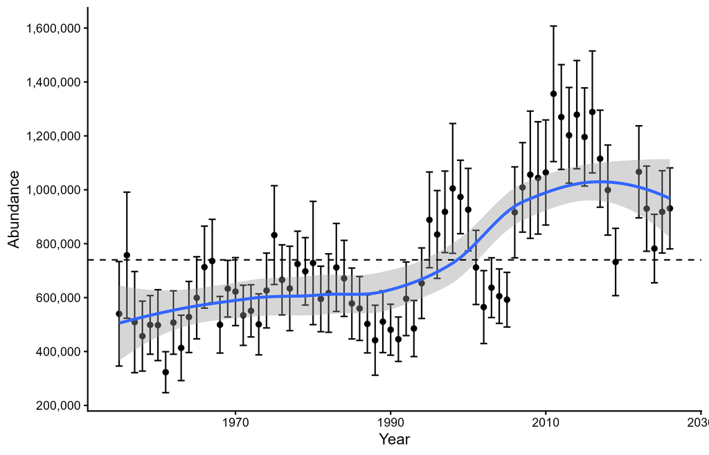

Figure 44: Redhead abundance in the WBPHS Traditional Survey Area in spring. Circles are annual estimates of abundance with 95% confidence intervals. The blue line is a smoothed (Loess model) line with 95% confidence interval (shaded area) fit to the annual estimates. The black dashed reference line is the long term average.

### Data Table 60: Scaup WBPHS

Original data source: WBPHS Traditional Survey Area; USFWS Headquarters.

Table 60. Scaup (greater and lesser spp.) abundance in the WBPHS Traditional Survey Area in spring, 1955-2026.

| Year | TSA | Area1 | Area2 | Area3 | Area4 | Area5 | Area6 | Area7 | Area8 |
| --- | --- | --- | --- | --- | --- | --- | --- | --- | --- |
| 1955 | 5,620,130 | 753,529 | 2,800,646 | 519,805 | 427,241 | 858,296 | 171,292 | 57,300 | 32,022 |
| 1956 | 5,994,080 | 785,945 | 2,648,479 | 568,414 | 483,205 | 1,274,657 | 147,877 | 53,878 | 31,624 |
| 1957 | 5,766,942 | 612,344 | 2,523,084 | 948,456 | 515,078 | 898,118 | 187,491 | 50,965 | 31,406 |
| 1958 | 5,350,372 | 796,797 | 2,442,658 | 491,358 | 490,625 | 519,954 | 535,666 | 49,302 | 24,012 |
| 1959 | 7,037,610 | 795,959 | 4,118,304 | 598,311 | 400,167 | 683,122 | 360,682 | 47,979 | 33,087 |
| 1960 | 4,868,569 | 831,350 | 2,630,023 | 228,937 | 325,779 | 484,451 | 265,420 | 46,648 | 55,961 |
| 1961 | 5,380,045 | 893,245 | 3,035,070 | 342,838 | 393,608 | 419,505 | 227,101 | 44,779 | 23,899 |
| 1962 | 5,286,098 | 1,252,000 | 2,746,477 | 331,830 | 231,904 | 418,844 | 153,191 | 44,040 | 107,812 |
| 1963 | 5,438,402 | 1,149,391 | 3,081,749 | 400,424 | 358,495 | 174,445 | 207,330 | 44,438 | 22,130 |
| 1964 | 5,131,798 | 1,005,518 | 2,909,274 | 463,531 | 400,469 | 162,858 | 145,839 | 41,670 | 2,640 |
| 1965 | 4,639,964 | 665,936 | 2,714,311 | 494,648 | 306,502 | 257,313 | 130,274 | 39,675 | 31,305 |
| 1966 | 4,439,240 | 827,528 | 2,592,733 | 384,382 | 238,706 | 193,509 | 112,444 | 54,791 | 35,146 |
| 1967 | 4,927,671 | 582,826 | 2,897,293 | 580,617 | 346,752 | 323,387 | 120,563 | 44,432 | 31,801 |
| 1968 | 4,412,682 | 982,187 | 2,253,631 | 698,005 | 233,992 | 95,641 | 83,242 | 33,843 | 32,140 |
| 1969 | 5,139,780 | 909,939 | 2,707,741 | 707,966 | 350,869 | 305,025 | 59,758 | 55,899 | 42,584 |
| 1970 | 5,662,477 | 847,809 | 3,008,370 | 890,766 | 367,910 | 322,829 | 88,839 | 47,760 | 88,194 |
| 1971 | 5,143,262 | 712,499 | 3,221,234 | 535,435 | 299,466 | 222,426 | 101,129 | 16,481 | 34,592 |
| 1972 | 7,996,967 | 772,525 | 5,483,114 | 891,762 | 426,765 | 242,571 | 69,223 | 67,038 | 43,968 |
| 1973 | 6,257,416 | 844,139 | 3,775,802 | 641,673 | 588,899 | 230,379 | 66,179 | 85,111 | 25,234 |
| 1974 | 5,780,464 | 799,266 | 3,081,586 | 920,676 | 368,630 | 377,899 | 146,280 | 40,733 | 45,394 |
| 1975 | 6,460,024 | 830,445 | 3,528,071 | 827,154 | 382,726 | 622,166 | 160,029 | 40,336 | 69,097 |
| 1976 | 5,818,746 | 1,057,363 | 2,707,301 | 585,467 | 625,930 | 504,645 | 208,720 | 66,300 | 63,020 |
| 1977 | 6,260,238 | 1,236,560 | 3,047,468 | 596,085 | 477,693 | 702,247 | 129,710 | 44,759 | 25,715 |
| 1978 | 5,984,411 | 931,800 | 2,871,013 | 715,347 | 462,961 | 526,169 | 231,513 | 105,365 | 140,243 |
| 1979 | 7,657,943 | 869,502 | 3,849,246 | 1,041,086 | 687,495 | 796,541 | 89,640 | 208,558 | 115,875 |
| 1980 | 6,381,655 | 1,244,015 | 3,196,776 | 587,079 | 472,963 | 628,970 | 161,998 | 38,966 | 50,888 |
| 1981 | 5,990,883 | 1,033,374 | 3,303,857 | 629,792 | 469,335 | 277,144 | 114,930 | 38,902 | 123,549 |
| 1982 | 5,531,964 | 853,830 | 2,730,444 | 590,831 | 522,077 | 496,595 | 129,652 | 83,250 | 125,285 |
| 1983 | 7,173,798 | 992,949 | 3,575,832 | 896,580 | 491,943 | 844,809 | 177,679 | 74,503 | 119,503 |
| 1984 | 7,024,320 | 1,095,502 | 4,175,201 | 562,288 | 367,493 | 510,174 | 81,055 | 98,951 | 133,656 |
| 1985 | 5,097,956 | 816,838 | 2,500,696 | 831,477 | 363,182 | 319,833 | 113,234 | 36,058 | 116,637 |
| 1986 | 5,235,304 | 795,481 | 2,527,231 | 601,469 | 322,744 | 468,909 | 251,898 | 54,652 | 212,920 |
| 1987 | 4,862,729 | 797,827 | 2,701,361 | 507,309 | 256,190 | 278,187 | 150,304 | 57,741 | 113,810 |
| 1988 | 4,671,351 | 770,177 | 2,339,907 | 538,073 | 345,157 | 366,910 | 109,024 | 68,607 | 133,496 |
| 1989 | 4,342,050 | 768,778 | 2,467,280 | 484,854 | 157,957 | 208,113 | 88,955 | 56,538 | 109,575 |
| 1990 | 4,293,141 | 803,390 | 2,038,157 | 710,219 | 307,318 | 199,330 | 114,576 | 45,208 | 74,943 |
| 1991 | 5,254,899 | 1,170,594 | 2,061,038 | 1,200,918 | 299,766 | 265,398 | 75,251 | 83,046 | 98,888 |
| 1992 | 4,639,232 | 909,988 | 1,811,641 | 998,722 | 288,041 | 438,565 | 107,400 | 23,883 | 60,993 |
| 1993 | 4,080,144 | 951,309 | 1,838,798 | 552,425 | 268,358 | 352,122 | 44,981 | 32,427 | 39,725 |
| 1994 | 4,529,044 | 1,148,608 | 1,977,562 | 382,345 | 264,964 | 343,869 | 118,247 | 48,865 | 244,583 |
| 1995 | 4,446,443 | 946,247 | 1,784,120 | 463,912 | 366,514 | 518,644 | 116,142 | 37,622 | 213,242 |
| 1996 | 4,217,405 | 1,056,867 | 1,476,903 | 436,132 | 376,349 | 462,511 | 186,676 | 67,361 | 154,606 |
| 1997 | 4,112,349 | 800,166 | 1,632,592 | 523,805 | 347,675 | 489,482 | 94,811 | 69,646 | 154,173 |
| 1998 | 3,471,916 | 927,866 | 1,436,450 | 253,274 | 243,105 | 300,158 | 61,578 | 28,975 | 220,510 |
| 1999 | 4,411,723 | 955,974 | 2,133,616 | 544,986 | 228,223 | 287,427 | 72,369 | 38,775 | 150,354 |
| 2000 | 4,026,322 | 1,219,183 | 1,620,966 | 292,975 | 292,335 | 272,775 | 60,064 | 41,256 | 226,768 |
| 2001 | 3,694,010 | 1,148,144 | 1,475,601 | 267,246 | 201,944 | 320,615 | 74,164 | 42,376 | 163,921 |
| 2002 | 3,524,142 | 792,048 | 1,784,303 | 378,014 | 146,475 | 149,681 | 49,670 | 49,713 | 174,237 |
| 2003 | 3,734,444 | 969,704 | 1,736,075 | 354,324 | 172,052 | 251,357 | 48,575 | 35,081 | 167,275 |
| 2004 | 3,807,191 | 982,435 | 1,624,426 | 581,560 | 124,093 | 184,770 | 31,442 | 27,590 | 250,874 |
| 2005 | 3,386,893 | 960,708 | 1,361,394 | 348,827 | 126,509 | 381,266 | 60,074 | 16,366 | 131,749 |
| 2006 | 3,246,663 | 883,851 | 1,169,374 | 334,868 | 213,921 | 391,001 | 96,887 | 18,610 | 138,150 |
| 2007 | 3,452,233 | 1,191,270 | 1,261,018 | 271,244 | 182,318 | 302,053 | 50,384 | 14,865 | 179,083 |
| 2008 | 3,738,349 | 1,070,619 | 1,626,732 | 405,942 | 175,531 | 256,318 | 59,770 | 16,327 | 127,109 |
| 2009 | 4,172,097 | 820,924 | 1,685,442 | 684,463 | 286,509 | 323,877 | 70,097 | 34,424 | 266,360 |
| 2010 | 4,244,429 | 947,143 | 2,378,279 | 208,488 | 127,023 | 245,534 | 52,782 | 14,429 | 270,751 |
| 2011 | 4,319,289 | 847,477 | 2,165,251 | 367,203 | 228,434 | 346,797 | 84,724 | 37,509 | 241,893 |
| 2012 | 5,238,630 | 849,496 | 2,839,272 | 337,565 | 294,349 | 521,382 | 102,061 | 17,696 | 276,810 |
| 2013 | 4,165,678 | 547,712 | 2,343,201 | 315,349 | 150,046 | 475,426 | 38,146 | 13,645 | 282,153 |
| 2014 | 4,611,054 | 577,874 | 2,127,036 | 200,808 | 247,348 | 850,405 | 163,772 | 22,059 | 421,752 |
| 2015 | 4,395,305 | 587,179 | 2,214,959 | 345,405 | 261,901 | 470,840 | 112,256 | 10,161 | 392,604 |
| 2016 | 4,991,714 | 653,481 | 2,805,401 | 349,301 | 256,896 | 433,311 | 102,469 | 14,970 | 375,885 |
| 2017 | 4,371,725 | 781,427 | 2,237,682 | 314,648 | 266,373 | 476,981 | 70,371 | 23,884 | 200,359 |
| 2018 | 3,989,325 | 669,727 | 1,964,896 | 268,152 | 259,846 | 409,205 | 82,130 | 28,204 | 307,165 |
| 2019 | 3,590,799 | 498,562 | 1,792,922 | 259,493 | 352,389 | 353,019 | 69,147 | 30,252 | 235,016 |
| 2020 | NA | NA | NA | NA | NA | NA | NA | NA | NA |
| 2021 | NA | NA | NA | NA | NA | NA | NA | NA | NA |
| 2022 | 3,655,073 | 678,151 | 1,803,141 | 407,283 | 282,812 | 275,430 | 55,445 | 25,258 | 127,553 |
| 2023 | 3,517,135 | 476,922 | 1,839,742 | 426,338 | 290,700 | 237,960 | 51,746 | 58,097 | 135,630 |
| 2024 | 4,069,075 | 553,145 | 2,191,056 | 360,758 | 251,044 | 274,154 | 55,757 | 59,554 | 323,607 |
| 2025 | 3,675,485 | 575,227 | 1,982,894 | 443,833 | 249,565 | 225,121 | 68,026 | 17,251 | 113,567 |
| 2026 | 4,155,425 | 553,070 | 2,440,861 | 432,984 | 232,874 | 316,263 | 44,346 | 33,076 | 101,950 |

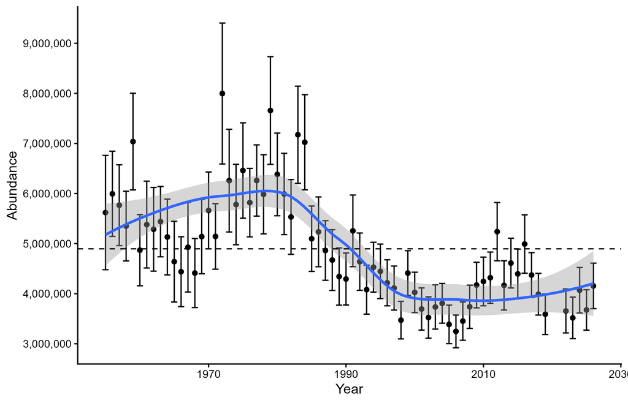

Figure 45: Scaup (greater and lesser spp.) abundance in the WBPHS Traditional Survey Area in spring. Circles are annual estimates of abundance with 95% confidence intervals. The blue line is a smoothed (Loess model) line with 95% confidence interval (shaded area) fit to the annual estimates. The black dashed reference line is the long term average.

### Data Table 61: Ring-necked Duck WBPHS

Original data source: WBPHS Traditional Survey Area; USFWS Headquarters.

Table 61. Ring-necked duck abundance in the WBPHS Traditional Survey Area in spring, 1955-2026.

| Year | TSA | Area1 | Area2 | Area3 | Area4 | Area5 | Area6 | Area7 | Area8 |
| --- | --- | --- | --- | --- | --- | --- | --- | --- | --- |
| 1955 | 451,486 | 110 | 240,319 | 178,452 | 1,430 | 27,218 | 2,133 | 1,218 | 606 |
| 1956 | 349,519 | 105 | 248,612 | 55,298 | 8,813 | 16,901 | 17,829 | 1,362 | 600 |
| 1957 | 165,523 | 0 | 144,020 | NA | 1,491 | 10,947 | 6,955 | 1,481 | 629 |
| 1958 | 160,816 | 0 | 124,617 | NA | 4,472 | 11,669 | 18,368 | 1,572 | 117 |
| 1959 | 599,010 | 0 | 502,257 | 4,991 | 9,418 | 27,559 | 53,155 | 1,630 | NA |
| 1960 | 278,008 | 624 | 218,083 | 25,169 | 2,935 | 13,795 | 12,795 | 1,668 | 2,939 |
| 1961 | 198,383 | 0 | 121,889 | 38,955 | 10,138 | 8,352 | 17,362 | 1,687 | NA |
| 1962 | 364,515 | 0 | 149,867 | 202,730 | 2,130 | NA | 8,095 | 1,693 | NA |
| 1963 | 461,723 | 0 | 128,820 | 284,009 | 1,662 | 20,828 | 22,903 | 1,689 | 1,813 |
| 1964 | 370,986 | 0 | 157,374 | 194,865 | 3,408 | 9,638 | 4,021 | 1,679 | NA |
| 1965 | 512,484 | 0 | 235,624 | 230,503 | 11,012 | 23,183 | 8,877 | 3,285 | NA |
| 1966 | 648,175 | 0 | 185,642 | 436,042 | 4,331 | 15,984 | 1,313 | 974 | 3,889 |
| 1967 | 493,212 | 0 | 141,396 | 288,158 | 34,792 | 10,360 | 9,984 | 8,522 | NA |
| 1968 | 489,863 | 0 | 98,152 | 372,987 | 11,047 | 1,516 | 3,244 | 2,917 | NA |
| 1969 | 374,740 | 0 | 62,905 | 289,257 | 8,687 | 6,459 | 6,626 | 222 | 584 |
| 1970 | 673,324 | 0 | 159,220 | 474,650 | 14,214 | 13,931 | 7,454 | NA | 3,855 |
| 1971 | 658,064 | 0 | 155,243 | 457,837 | 36,221 | 7,175 | NA | NA | 1,588 |
| 1972 | 408,775 | 412 | 82,678 | 277,007 | 30,628 | 8,531 | 8,845 | NA | 674 |
| 1973 | 333,316 | 0 | 121,405 | 190,137 | 2,002 | 8,242 | 11,530 | NA | NA |
| 1974 | 346,278 | 0 | 64,361 | 211,053 | 15,135 | 42,563 | 10,454 | 2,127 | 584 |
| 1975 | 530,420 | 0 | 123,159 | 309,953 | 26,015 | 53,769 | 16,356 | NA | 1,168 |
| 1976 | 499,600 | 0 | 76,645 | 347,454 | 13,482 | 42,600 | 16,601 | 1,429 | 1,389 |
| 1977 | 535,615 | 62 | 202,878 | 258,676 | 23,939 | 38,991 | 9,046 | 653 | 1,370 |
| 1978 | 626,786 | 128 | 154,837 | 344,159 | 50,884 | 45,061 | 27,334 | 2,008 | 2,374 |
| 1979 | 453,220 | 764 | 91,260 | 250,201 | 21,324 | 46,839 | 33,768 | NA | 9,064 |
| 1980 | 688,971 | 836 | 121,438 | 436,803 | 8,945 | 55,491 | 59,765 | 890 | 4,803 |
| 1981 | 815,754 | 9,626 | 120,313 | 552,772 | 29,526 | 40,994 | 58,844 | 890 | 2,789 |
| 1982 | 600,883 | 3,853 | 69,897 | 383,897 | 23,699 | 69,791 | 28,667 | 9,508 | 11,570 |
| 1983 | 780,082 | 3,501 | 144,927 | 386,438 | 12,682 | 21,765 | 32,438 | 24,940 | 153,390 |
| 1984 | 729,728 | 28,656 | 134,786 | 449,402 | 33,597 | 42,735 | 8,040 | 8,016 | 24,496 |
| 1985 | 628,713 | 16,298 | 88,159 | 458,501 | 18,727 | 21,387 | 16,468 | 5,181 | 3,992 |
| 1986 | 566,989 | 65,933 | 88,726 | 331,962 | 11,687 | 13,743 | 17,911 | 8,300 | 28,727 |
| 1987 | 732,528 | 38,287 | 121,134 | 477,934 | 18,557 | 29,315 | 29,251 | 2,598 | 15,452 |
| 1988 | 737,421 | 50,457 | 179,176 | 398,427 | 35,327 | 30,682 | 26,018 | 11,581 | 5,753 |
| 1989 | 543,824 | 24,751 | 152,267 | 263,599 | 46,509 | 8,620 | 15,673 | 7,225 | 25,180 |
| 1990 | 632,464 | 35,023 | 134,995 | 372,590 | 12,421 | 19,789 | 29,983 | 4,413 | 23,250 |
| 1991 | 657,626 | 18,669 | 131,749 | 442,470 | 14,924 | 19,606 | 19,246 | 6,371 | 4,591 |
| 1992 | 1,286,570 | 35,663 | 122,426 | 1,046,040 | 15,423 | 16,084 | 9,140 | 12,744 | 29,049 |
| 1993 | 867,927 | 39,781 | 209,323 | 581,132 | 9,559 | 12,013 | 5,887 | 9,179 | 1,054 |
| 1994 | 880,088 | 28,997 | 225,048 | 554,042 | 12,588 | 15,695 | 11,879 | 20,094 | 11,745 |
| 1995 | 954,961 | 26,090 | 211,296 | 568,026 | 8,980 | 36,010 | 11,679 | 20,086 | 72,795 |
| 1996 | 772,691 | 29,951 | 143,533 | 455,827 | 10,081 | 82,889 | 20,526 | 6,155 | 23,729 |
| 1997 | 1,192,452 | 36,999 | 385,574 | 616,339 | 37,449 | 58,057 | 27,675 | 1,222 | 29,135 |
| 1998 | 1,166,752 | 60,582 | 317,606 | 716,974 | 11,918 | 30,771 | 11,394 | 2,998 | 14,508 |
| 1999 | 1,103,225 | 19,150 | 365,723 | 543,853 | 51,981 | 57,237 | 16,596 | 3,088 | 45,595 |
| 2000 | 1,278,283 | 65,473 | 478,776 | 595,655 | 16,220 | 63,882 | 41,243 | 707 | 16,326 |
| 2001 | 939,669 | 86,529 | 256,834 | 476,891 | 20,167 | 36,316 | 37,998 | 7,396 | 17,539 |
| 2002 | 1,490,041 | 52,132 | 161,419 | 1,172,098 | 7,530 | 29,672 | 29,967 | 4,578 | 32,645 |
| 2003 | 1,229,696 | 96,086 | 322,451 | 692,958 | 31,096 | 27,212 | 39,984 | 3,851 | 16,057 |
| 2004 | 1,142,511 | 71,668 | 222,776 | 754,008 | 44,081 | 19,603 | 19,843 | 5,149 | 5,384 |
| 2005 | 1,016,720 | 78,618 | 290,904 | 589,321 | 12,895 | 6,927 | 20,652 | 5,569 | 11,834 |
| 2006 | 952,672 | 83,590 | 251,006 | 491,661 | 21,488 | 59,318 | 26,556 | 15,401 | 3,652 |
| 2007 | 1,060,457 | 61,467 | 238,283 | 639,654 | 31,962 | 22,637 | 40,462 | 10,146 | 15,846 |
| 2008 | 1,010,841 | 40,901 | 283,553 | 579,036 | 21,395 | 49,762 | 24,198 | 4,480 | 7,516 |
| 2009 | 1,268,527 | 28,999 | 481,195 | 622,651 | 24,994 | 39,289 | 15,072 | 18,738 | 37,589 |
| 2010 | 1,145,670 | 46,086 | 625,628 | 331,987 | 16,141 | 57,354 | 17,428 | 16,053 | 34,994 |
| 2011 | 1,005,305 | 30,577 | 452,835 | 276,596 | 7,800 | 111,520 | 9,736 | 1,506 | 114,735 |
| 2012 | 1,022,043 | 30,427 | 371,174 | 423,252 | 7,157 | 111,462 | 32,951 | 2,804 | 42,816 |
| 2013 | 1,322,988 | 29,302 | 531,718 | 492,859 | 13,538 | 101,132 | 85,812 | 913 | 67,715 |
| 2014 | 1,573,864 | 49,030 | 681,224 | 464,352 | 19,258 | 176,243 | 65,159 | 60,814 | 57,783 |
| 2015 | 1,503,316 | 40,902 | 726,904 | 397,663 | 14,008 | 201,640 | 72,792 | 10,440 | 38,967 |
| 2016 | 1,772,715 | 56,873 | 934,562 | 460,264 | 42,277 | 172,888 | 31,764 | 27,030 | 47,056 |
| 2017 | 1,918,026 | 49,928 | 1,123,508 | 435,009 | 52,178 | 176,128 | 51,965 | 1,296 | 28,016 |
| 2018 | 1,783,080 | 38,912 | 812,462 | 649,154 | 43,933 | 121,632 | 75,712 | 6,421 | 34,854 |
| 2019 | 1,537,694 | 48,686 | 859,760 | 405,695 | 11,652 | 101,972 | 48,957 | 35,149 | 25,822 |
| 2020 | NA | NA | NA | NA | NA | NA | NA | NA | NA |
| 2021 | NA | NA | NA | NA | NA | NA | NA | NA | NA |
| 2022 | 1,083,534 | 53,203 | 434,730 | 308,628 | 26,468 | 115,725 | 57,618 | 7,815 | 79,347 |
| 2023 | 1,532,462 | 19,827 | 541,298 | 705,825 | 47,393 | 84,267 | 56,237 | 10,903 | 66,712 |
| 2024 | 1,423,556 | 27,310 | 508,756 | 679,715 | 7,807 | 67,503 | 34,270 | 34,440 | 63,755 |
| 2025 | 1,533,716 | 27,740 | 974,834 | 382,041 | 26,061 | 65,707 | 28,386 | 10,931 | 18,017 |
| 2026 | 1,358,709 | 38,133 | 710,322 | 456,792 | 25,043 | 76,619 | 15,494 | 22,195 | 14,111 |

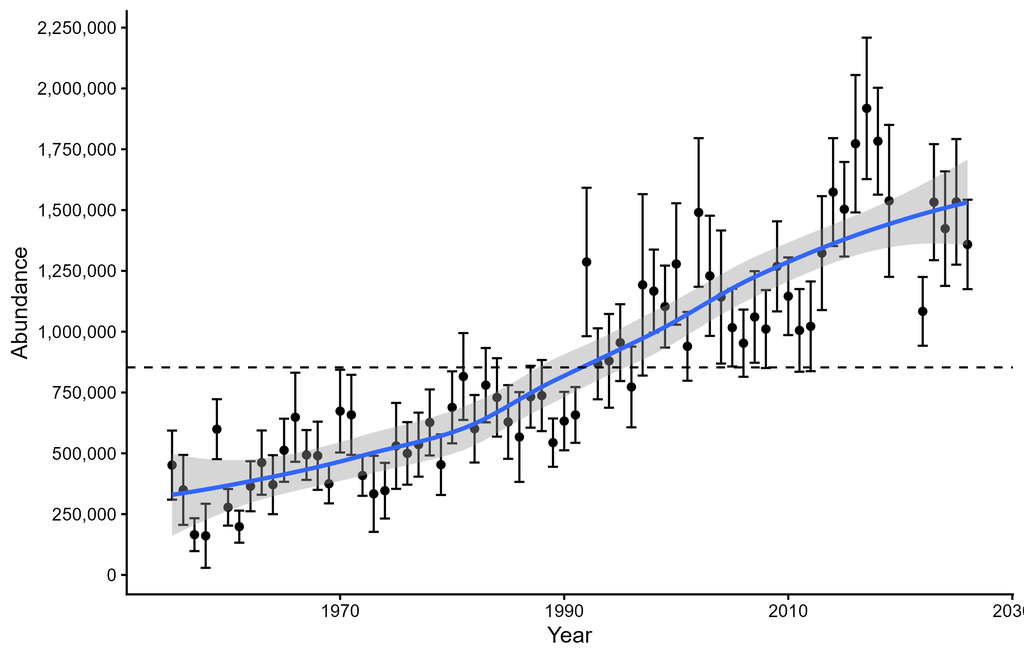

Figure 46: Ring-necked duck abundance in the WBPHS Traditional Survey Area in spring. Circles are annual estimates of abundance with 95% confidence intervals. The blue line is a smoothed (Loess model) line with 95% confidence interval (shaded area) fit to the annual estimates. The black dashed reference line is the long term average.

### Data Table 62: Bufflehead WBPHS

Original data source: WBPHS Traditional Survey Area; USFWS Headquarters.

Table 62. Bufflehead abundance in the WBPHS Traditional Survey Area in spring, 1955-2026.

| Year | TSA | Area1 | Area2 | Area3 | Area4 | Area5 | Area6 | Area7 | Area8 |
| --- | --- | --- | --- | --- | --- | --- | --- | --- | --- |
| 1955 | 366,485 | 25,420 | 236,090 | 58,112 | 26,140 | 7,641 | 12,415 | 667 | 0 |
| 1956 | 365,116 | 26,868 | 252,953 | 35,547 | 36,632 | 8,806 | 3,615 | 695 | 0 |
| 1957 | 310,673 | 26,885 | 213,382 | 20,501 | 33,770 | 14,205 | 1,197 | 725 | 7 |
| 1958 | 321,362 | 15,714 | 202,694 | 45,972 | 39,475 | 7,518 | 9,218 | 771 | 0 |
| 1959 | 554,948 | 43,294 | 409,513 | 38,030 | 44,641 | 8,968 | 9,710 | 792 | NA |
| 1960 | 513,222 | 37,751 | 277,597 | 143,743 | 32,949 | 13,422 | 6,932 | 828 | NA |
| 1961 | 424,094 | 25,485 | 274,641 | 52,131 | 53,212 | 9,498 | 8,262 | 865 | NA |
| 1962 | 413,182 | 46,138 | 262,226 | 74,928 | 22,142 | 1,987 | 4,862 | 900 | NA |
| 1963 | 373,205 | 37,426 | 210,776 | 71,086 | 26,546 | 11,196 | 15,169 | 1,007 | NA |
| 1964 | 388,535 | 29,415 | 276,307 | 34,590 | 24,446 | 13,182 | 9,632 | 962 | NA |
| 1965 | 443,254 | 40,510 | 252,212 | 34,591 | 71,138 | 22,877 | 20,486 | 1,440 | NA |
| 1966 | 486,863 | 47,808 | 323,656 | 52,511 | 33,434 | 14,378 | 13,238 | 1,434 | 404 |
| 1967 | 491,468 | 54,147 | 256,133 | 80,575 | 48,640 | 18,058 | 32,589 | 1,325 | NA |
| 1968 | 578,055 | 37,159 | 249,902 | 217,013 | 32,448 | 29,476 | 10,007 | 2,050 | NA |
| 1969 | 653,897 | 32,946 | 358,755 | 151,753 | 44,142 | 39,162 | 25,725 | 1,414 | NA |
| 1970 | 642,280 | 43,536 | 306,760 | 220,532 | 40,370 | 20,522 | 8,379 | 376 | 1,805 |
| 1971 | 769,248 | 44,545 | 452,695 | 209,017 | 33,837 | 12,612 | 16,542 | NA | NA |
| 1972 | 756,168 | 40,862 | 428,648 | 185,596 | 53,320 | 31,727 | 10,284 | 5,731 | NA |
| 1973 | 541,076 | 40,487 | 299,541 | 145,058 | 30,593 | 17,890 | 6,368 | 645 | 494 |
| 1974 | 663,601 | 64,846 | 373,253 | 156,109 | 25,989 | 19,122 | 22,138 | 1,694 | 450 |
| 1975 | 696,678 | 44,018 | 390,717 | 142,217 | 56,129 | 43,688 | 19,533 | 376 | NA |
| 1976 | 751,937 | 81,727 | 327,653 | 246,038 | 47,317 | 23,759 | 24,146 | 1,297 | NA |
| 1977 | 653,380 | 51,062 | 324,548 | 185,140 | 35,200 | 38,500 | 18,930 | NA | NA |
| 1978 | 880,666 | 69,757 | 446,095 | 225,239 | 60,638 | 40,666 | 35,575 | 1,942 | 754 |
| 1979 | 885,028 | 78,958 | 453,912 | 222,471 | 67,167 | 42,409 | 12,588 | 4,903 | 2,620 |
| 1980 | 696,621 | 60,021 | 369,943 | 180,066 | 32,328 | 23,908 | 26,860 | 1,021 | 2,474 |
| 1981 | 672,831 | 40,037 | 304,556 | 207,362 | 55,464 | 29,181 | 31,977 | 2,365 | 1,889 |
| 1982 | 553,100 | 48,194 | 249,786 | 154,741 | 42,220 | 24,723 | 24,075 | 6,944 | 2,418 |
| 1983 | 946,749 | 45,007 | 517,058 | 253,778 | 57,370 | 36,247 | 27,154 | 376 | 9,759 |
| 1984 | 854,269 | 37,821 | 589,281 | 142,032 | 25,754 | 27,630 | 20,082 | 5,187 | 6,482 |
| 1985 | 554,214 | 36,788 | 301,089 | 139,217 | 16,954 | 26,868 | 31,783 | 1,021 | 494 |
| 1986 | 638,721 | 38,657 | 365,496 | 134,425 | 33,818 | 33,916 | 26,483 | 376 | 5,550 |
| 1987 | 748,248 | 55,759 | 479,870 | 120,633 | 22,662 | 32,906 | 36,418 | NA | NA |
| 1988 | 720,175 | 46,731 | 446,362 | 119,305 | 50,807 | 20,419 | 29,024 | 5,599 | 1,928 |
| 1989 | 744,198 | 54,676 | 445,637 | 150,226 | 32,509 | 21,880 | 30,472 | 3,698 | 5,100 |
| 1990 | 745,490 | 31,763 | 407,934 | 200,378 | 36,522 | 31,746 | 30,184 | 6,019 | 944 |
| 1991 | 834,350 | 40,059 | 420,323 | 205,043 | 80,036 | 44,311 | 37,994 | 5,608 | 976 |
| 1992 | 1,030,544 | 32,271 | 428,798 | 410,789 | 67,581 | 37,561 | 41,498 | 5,726 | 6,318 |
| 1993 | 869,405 | 29,729 | 364,254 | 330,876 | 79,610 | 43,876 | 18,226 | 358 | 2,475 |
| 1994 | 765,723 | 38,319 | 401,486 | 183,395 | 43,090 | 42,057 | 40,321 | 7,235 | 9,822 |
| 1995 | 832,558 | 37,931 | 459,946 | 172,870 | 68,323 | 41,869 | 41,613 | 1,174 | 8,832 |
| 1996 | 879,963 | 49,745 | 467,314 | 173,920 | 103,462 | 52,985 | 29,507 | 1,294 | 1,736 |
| 1997 | 1,123,815 | 40,177 | 619,714 | 222,081 | 91,329 | 91,615 | 53,372 | 3,546 | 1,980 |
| 1998 | 945,880 | 46,697 | 472,410 | 235,398 | 73,919 | 78,803 | 35,415 | 2,114 | 1,124 |
| 1999 | 1,111,666 | 41,166 | 601,213 | 265,930 | 69,529 | 88,391 | 41,731 | 3,043 | 663 |
| 2000 | 910,287 | 39,704 | 382,714 | 260,591 | 70,930 | 112,810 | 38,195 | 3,409 | 1,934 |
| 2001 | 925,596 | 54,410 | 481,770 | 213,228 | 59,180 | 73,669 | 36,874 | 1,794 | 4,671 |
| 2002 | 948,388 | 38,290 | 485,954 | 262,023 | 47,226 | 75,350 | 34,696 | 542 | 4,307 |
| 2003 | 1,089,491 | 46,615 | 558,124 | 258,978 | 82,872 | 99,374 | 38,769 | 3,562 | 1,195 |
| 2004 | 1,053,228 | 43,849 | 532,066 | 298,785 | 70,637 | 55,215 | 50,455 | 1,834 | 387 |
| 2005 | 1,137,042 | 51,726 | 619,523 | 235,941 | 78,860 | 91,789 | 54,903 | 3,655 | 644 |
| 2006 | 1,144,396 | 46,319 | 606,111 | 229,867 | 107,600 | 101,426 | 49,737 | 2,299 | 1,038 |
| 2007 | 1,151,544 | 60,963 | 547,177 | 275,095 | 98,154 | 107,560 | 59,218 | 2,266 | 1,111 |
| 2008 | 1,071,011 | 56,816 | 561,513 | 229,193 | 60,121 | 116,041 | 41,672 | 1,554 | 4,100 |
| 2009 | 1,108,861 | 58,936 | 503,058 | 348,068 | 69,632 | 85,891 | 38,713 | 1,699 | 2,865 |
| 2010 | 1,415,389 | 53,456 | 797,480 | 273,802 | 76,700 | 172,057 | 34,023 | 3,832 | 4,039 |
| 2011 | 1,271,931 | 55,168 | 591,973 | 314,920 | 99,844 | 150,098 | 35,525 | 5,324 | 19,079 |
| 2012 | 1,409,406 | 48,489 | 745,485 | 255,944 | 141,370 | 182,482 | 30,125 | NA | 5,510 |
| 2013 | 1,203,561 | 43,770 | 537,395 | 256,703 | 76,971 | 209,058 | 62,426 | 547 | 16,691 |
| 2014 | 1,311,841 | 43,499 | 617,994 | 225,350 | 126,038 | 229,216 | 42,988 | 616 | 26,140 |
| 2015 | 1,587,902 | 42,528 | 700,610 | 349,564 | 123,783 | 296,113 | 69,954 | NA | 5,350 |
| 2016 | 1,353,573 | 44,086 | 689,446 | 204,341 | 98,543 | 226,435 | 85,413 | 556 | 4,752 |
| 2017 | 1,329,279 | 43,181 | 599,393 | 275,746 | 146,902 | 201,411 | 51,789 | NA | 10,857 |
| 2018 | 1,291,366 | 44,521 | 602,175 | 222,612 | 114,953 | 235,452 | 58,246 | 5,177 | 8,231 |
| 2019 | 1,154,245 | 38,205 | 532,169 | 192,997 | 94,533 | 214,819 | 54,363 | 11,679 | 15,481 |
| 2020 | NA | NA | NA | NA | NA | NA | NA | NA | NA |
| 2021 | NA | NA | NA | NA | NA | NA | NA | NA | NA |
| 2022 | 1,006,243 | 35,023 | 405,745 | 226,378 | 80,605 | 185,169 | 65,379 | 2,598 | 5,347 |
| 2023 | 996,305 | 15,856 | 438,472 | 174,429 | 98,078 | 210,436 | 49,324 | 3,293 | 6,418 |
| 2024 | 1,394,373 | 50,101 | 654,667 | 260,788 | 108,345 | 200,503 | 101,797 | 1,129 | 17,043 |
| 2025 | 1,383,505 | 60,817 | 640,918 | 220,903 | 106,172 | 281,784 | 66,029 | NA | 6,882 |
| 2026 | 1,305,064 | 49,142 | 472,504 | 261,300 | 135,143 | 348,321 | 28,994 | 2,298 | 7,363 |

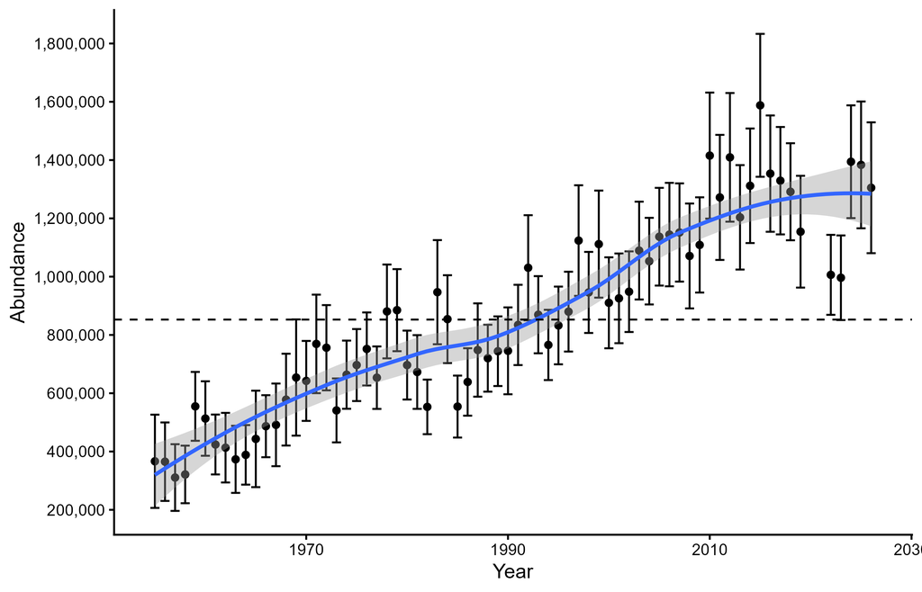

Figure 47: Bufflehead abundance in the WBPHS Traditional Survey Area in spring. Circles are annual estimates of abundance with 95% confidence intervals. The blue line is a smoothed (Loess model) line with 95% confidence interval (shaded area) fit to the annual estimates. The black dashed reference line is the long term average.

### Data Table 63: Ruddy Duck WBPHS

Original data source: WBPHS Traditional Survey Area; USFWS Headquarters.

Table 63. Ruddy Duck abundance in the WBPHS Traditional Survey Area in spring, 1955-2026.

| Year | TSA | Area1 | Area2 | Area3 | Area4 | Area5 | Area6 | Area7 | Area8 |
| --- | --- | --- | --- | --- | --- | --- | --- | --- | --- |
| 1955 | 289,859 | 6 | 34,732 | NA | 76,180 | 128,697 | 28,904 | 8,538 | 12,802 |
| 1956 | 388,665 | 6 | 29,593 | NA | 78,270 | 231,810 | 28,602 | 8,282 | 12,103 |
| 1957 | 221,282 | 6 | 6,904 | NA | 43,444 | 126,127 | 24,925 | 8,012 | 11,864 |
| 1958 | 170,712 | 0 | 18,693 | NA | 51,584 | 66,230 | 24,560 | 7,739 | 1,906 |
| 1959 | 548,219 | 0 | 100,268 | 4,495 | 79,151 | 256,132 | 76,840 | 7,510 | 23,823 |
| 1960 | 362,963 | 0 | 23,497 | 2,075 | 97,861 | 116,771 | 60,407 | 7,372 | 54,979 |
| 1961 | 343,124 | 6 | 67,452 | 27,378 | 49,800 | 71,428 | 92,851 | 7,263 | 26,946 |
| 1962 | 217,951 | 0 | 1,225 | 39,289 | 21,895 | 59,550 | 49,507 | 7,180 | 39,305 |
| 1963 | 245,249 | 0 | 22,237 | 17,859 | 37,418 | 38,531 | 98,281 | 7,178 | 23,745 |
| 1964 | 223,945 | 7 | 7,830 | 6,302 | 92,953 | 34,264 | 68,705 | 7,082 | 6,803 |
| 1965 | 237,499 | 7 | 6,408 | 18,644 | 93,379 | 42,614 | 65,530 | 247 | 10,669 |
| 1966 | 326,606 | 8 | 17,512 | 11,523 | 83,012 | 77,068 | 95,751 | 3,048 | 38,684 |
| 1967 | 324,318 | 8 | 15,342 | 20,004 | 111,877 | 58,726 | 74,859 | 1,666 | 41,836 |
| 1968 | 385,528 | 9 | 7,721 | 83,831 | 96,722 | 83,345 | 87,996 | 4,782 | 21,123 |
| 1969 | 273,081 | 9 | 36,462 | 20,708 | 47,903 | 54,967 | 38,626 | 22,864 | 51,542 |
| 1970 | 328,355 | 10 | 10,367 | 18,339 | 66,904 | 42,062 | 64,692 | 3,490 | 122,490 |
| 1971 | 267,094 | 11 | 12,541 | 8,751 | 56,720 | 60,181 | 52,880 | 1,321 | 74,688 |
| 1972 | 343,968 | 13 | 45,551 | 12,559 | 101,955 | 67,151 | 25,835 | 5,656 | 85,249 |
| 1973 | 289,609 | 14 | 18,841 | 10,325 | 38,224 | 115,961 | 43,867 | 3,969 | 58,408 |
| 1974 | 457,920 | 15 | 9,557 | 9,040 | 93,341 | 98,476 | 55,554 | 3,095 | 188,842 |
| 1975 | 678,425 | 16 | 21,550 | 4,453 | 184,681 | 80,323 | 49,940 | 4,474 | 332,989 |
| 1976 | 176,162 | 17 | 1,566 | 6,413 | 33,571 | 58,362 | 45,305 | 1,862 | 29,066 |
| 1977 | 316,512 | 18 | 42,471 | 7,957 | 101,483 | 101,834 | 34,650 | 1,156 | 26,944 |
| 1978 | 362,750 | 19 | 8,267 | 11,790 | 75,549 | 49,972 | 51,087 | 19,898 | 146,168 |
| 1979 | 299,172 | 20 | 10,692 | 6,690 | 42,045 | 91,103 | 22,288 | 32,063 | 94,272 |
| 1980 | 354,274 | 20 | 18,959 | 29,206 | 33,938 | 57,940 | 80,539 | 1,299 | 132,372 |
| 1981 | 633,200 | 21 | 53,077 | 53,920 | 62,966 | 49,705 | 91,792 | 17,094 | 304,625 |
| 1982 | 947,872 | 22 | 25,888 | 18,560 | 116,002 | 181,908 | 146,203 | 22,062 | 437,227 |
| 1983 | 715,003 | 23 | 171,613 | 24,126 | 72,906 | 108,529 | 55,049 | 11,369 | 271,388 |
| 1984 | 554,021 | 1,451 | 58,792 | 8,670 | 62,324 | 78,878 | 31,634 | 12,366 | 299,905 |
| 1985 | 390,445 | NA | 28,715 | 7,260 | 43,776 | 128,272 | 39,344 | 7,997 | 135,081 |
| 1986 | 585,000 | NA | 112,732 | 6,548 | 32,902 | 120,190 | 68,533 | 6,910 | 237,185 |
| 1987 | 400,819 | NA | 30,329 | 6,097 | 35,823 | 105,566 | 79,997 | 2,531 | 140,476 |
| 1988 | 268,845 | 119 | 17,764 | 13,529 | 77,895 | 61,243 | 57,384 | 25,099 | 15,812 |
| 1989 | 424,424 | 836 | 109,224 | 12,267 | 65,604 | 80,122 | 51,315 | 6,637 | 98,419 |
| 1990 | 473,077 | 653 | 78,963 | 32,609 | 129,916 | 56,232 | 68,853 | 9,196 | 96,655 |
| 1991 | 449,671 | NA | 44,059 | 22,486 | 193,766 | 58,480 | 68,697 | 37,980 | 24,203 |
| 1992 | 418,358 | NA | 106,349 | 9,637 | 85,226 | 116,146 | 58,390 | 9,547 | 33,063 |
| 1993 | 387,202 | NA | 120,285 | 51,796 | 57,054 | 78,071 | 22,759 | 1,817 | 55,420 |
| 1994 | 342,424 | NA | 12,559 | 673 | 65,536 | 102,211 | 14,427 | 35,599 | 111,418 |
| 1995 | 510,769 | NA | 42,748 | 20,515 | 128,458 | 158,131 | 32,074 | 6,989 | 121,854 |
| 1996 | 680,273 | 837 | 67,942 | 15,264 | 302,195 | 166,676 | 38,710 | 3,351 | 85,297 |
| 1997 | 499,365 | NA | 31,486 | 17,447 | 87,116 | 124,098 | 31,402 | 9,585 | 198,230 |
| 1998 | 612,498 | NA | 210,874 | 2,018 | 123,554 | 82,294 | 13,732 | 26,941 | 153,086 |
| 1999 | 713,746 | NA | 97,843 | 21,313 | 73,405 | 170,286 | 43,155 | 8,318 | 299,427 |
| 2000 | 654,351 | NA | 82,532 | 3,027 | 74,308 | 168,207 | 45,751 | 2,350 | 278,175 |
| 2001 | 566,715 | 1,023 | 39,850 | 12,591 | 51,612 | 134,255 | 58,648 | 29,426 | 239,311 |
| 2002 | 694,725 | NA | 126,847 | 19,909 | 86,481 | 69,957 | 108,487 | 26,196 | 256,848 |
| 2003 | 762,987 | NA | 155,559 | 27,246 | 54,857 | 358,216 | 40,507 | 26,336 | 100,267 |
| 2004 | 782,343 | 837 | 99,025 | 27,042 | 93,460 | 229,930 | 143,271 | 20,922 | 167,855 |
| 2005 | 457,078 | NA | 71,806 | 16,371 | 42,708 | 136,936 | 41,344 | 24,003 | 123,911 |
| 2006 | 521,061 | NA | 57,817 | 9,773 | 58,295 | 170,637 | 40,722 | 26,769 | 157,049 |
| 2007 | 836,205 | NA | 39,168 | 8,191 | 49,190 | 516,439 | 46,597 | 29,334 | 147,286 |
| 2008 | 575,743 | NA | 44,416 | 2,872 | 45,805 | 136,541 | 45,934 | 16,451 | 283,724 |
| 2009 | 582,036 | NA | 60,621 | 13,275 | 64,035 | 135,425 | 12,436 | 64,611 | 231,633 |
| 2010 | 530,922 | NA | 112,910 | 2,077 | 48,814 | 101,463 | 16,930 | 15,846 | 232,881 |
| 2011 | 604,520 | 842 | 38,563 | 6,158 | 36,023 | 357,736 | 26,142 | 13,071 | 125,985 |
| 2012 | 569,642 | NA | 38,106 | 9,449 | 31,868 | 290,576 | 31,660 | 18,418 | 149,564 |
| 2013 | 897,999 | 1,007 | 59,153 | 2,664 | 84,845 | 500,030 | 32,565 | 1,276 | 216,459 |
| 2014 | 823,032 | NA | 36,517 | 9,025 | 69,154 | 435,833 | 40,568 | 4,072 | 227,863 |
| 2015 | 844,190 | NA | 93,733 | 72,250 | 60,045 | 435,772 | 24,706 | 16,977 | 140,707 |
| 2016 | 1,069,145 | NA | 184,313 | 1,415 | 113,351 | 427,269 | 77,249 | 17,487 | 248,061 |
| 2017 | 1,014,085 | NA | 54,593 | 3,163 | 122,058 | 553,776 | 56,916 | 16,483 | 207,096 |
| 2018 | 679,333 | NA | 57,015 | 26,653 | 90,367 | 229,697 | 77,679 | 11,265 | 186,657 |
| 2019 | 514,987 | NA | 43,989 | 10,540 | 101,191 | 134,438 | 20,856 | 32,274 | 171,699 |
| 2020 | NA | NA | NA | NA | NA | NA | NA | NA | NA |
| 2021 | NA | NA | NA | NA | NA | NA | NA | NA | NA |
| 2022 | 738,917 | 1,608 | 47,280 | 25,113 | 71,484 | 347,144 | 59,189 | 17,546 | 169,552 |
| 2023 | 622,284 | NA | 25,537 | 8,758 | 116,988 | 231,154 | 36,070 | 22,504 | 181,274 |
| 2024 | 680,995 | NA | 44,016 | 32,765 | 65,471 | 151,950 | 37,000 | 80,698 | 269,096 |
| 2025 | 764,157 | NA | 55,752 | 33,243 | 53,812 | 323,851 | 51,185 | 16,566 | 229,748 |
| 2026 | 744,404 | NA | 56,765 | 12,932 | 57,081 | 360,495 | 31,885 | 51,356 | 173,890 |

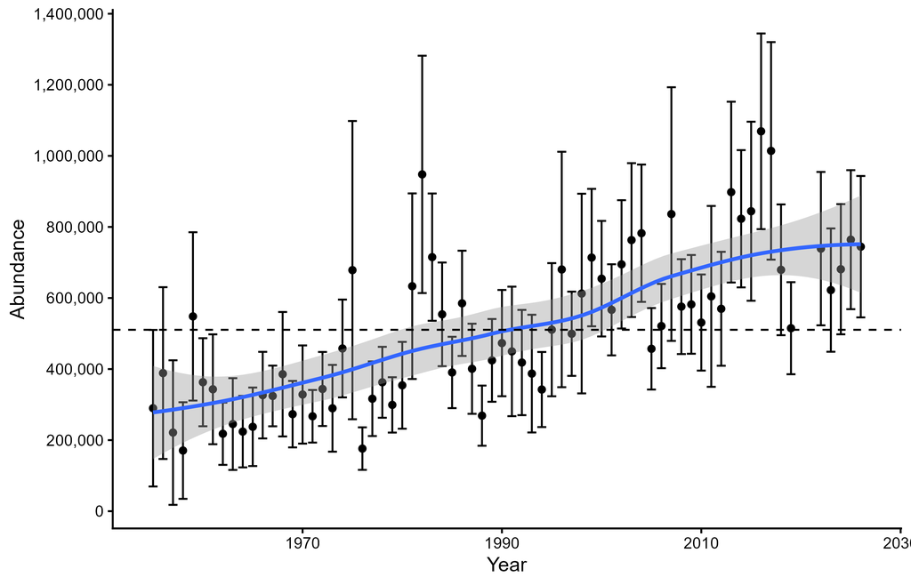

Figure 48: Ruddy Duck abundance in the WBPHS Traditional Survey Area in spring. Circles are annual estimates of abundance with 95% confidence intervals. The blue line is a smoothed (Loess model) line with 95% confidence interval (shaded area) fit to the annual estimates. The black dashed reference line is the long term average.

### Data Table 64: Goldeneye WBPHS

Original data source: WBPHS Traditional Survey Area; USFWS Headquarters.

Table 64. Goldeneye (Barrow's and common spp.) abundance in the WBPHS Traditional Survey Area in spring, 1955-2026.

| Year | TSA | Area1 | Area2 | Area3 | Area4 | Area5 | Area6 | Area7 | Area8 |
| --- | --- | --- | --- | --- | --- | --- | --- | --- | --- |
| 1955 | 562,778 | 27,538 | 418,422 | 76,223 | 15,996 | 11,811 | 12,357 | 430 | 0 |
| 1956 | 414,815 | 28,917 | 289,608 | 40,289 | 21,071 | 21,189 | 13,281 | 460 | 0 |
| 1957 | 228,022 | 30,149 | 140,340 | 6,412 | 15,495 | 17,681 | 17,452 | 494 | 0 |
| 1958 | 798,183 | 39,019 | 472,588 | 238,933 | 9,080 | 9,812 | 28,222 | 529 | 0 |
| 1959 | 1,732,502 | 46,539 | 859,109 | 762,963 | 8,734 | 13,271 | 41,321 | 565 | NA |
| 1960 | 530,657 | 45,906 | 134,874 | 274,306 | 11,372 | 21,435 | 42,165 | 599 | NA |
| 1961 | 673,285 | 41,243 | 375,515 | 220,458 | 11,241 | 10,598 | 13,600 | 630 | NA |
| 1962 | 792,813 | 69,789 | 360,992 | 332,183 | 7,929 | 7,783 | 13,481 | 657 | NA |
| 1963 | 302,809 | 60,891 | 32,242 | 196,345 | 2,440 | 3,892 | 6,288 | 711 | NA |
| 1964 | 319,937 | 23,720 | 160,027 | 120,677 | 5,860 | 2,584 | 6,373 | 696 | NA |
| 1965 | 343,159 | 44,441 | 204,012 | 73,020 | 1,457 | 8,802 | 11,391 | 36 | NA |
| 1966 | 247,907 | 45,769 | 39,876 | 142,230 | 4,880 | 10,501 | 2,102 | 1,346 | 1,202 |
| 1967 | 288,833 | 122,644 | 64,985 | 68,501 | NA | 14,327 | 18,376 | NA | NA |
| 1968 | 584,864 | 130,244 | 30,331 | 389,549 | 5,639 | 22,506 | 6,595 | NA | NA |
| 1969 | 411,523 | 94,705 | 36,774 | 254,739 | 8,908 | 8,731 | 7,029 | 637 | NA |
| 1970 | 420,117 | 63,266 | 35,666 | 288,099 | 3,622 | 15,492 | 13,972 | NA | NA |
| 1971 | 402,894 | 81,671 | 38,921 | 214,726 | 20,413 | 14,262 | 32,900 | NA | NA |
| 1972 | 458,024 | 92,499 | 75,381 | 253,301 | 15,609 | 4,575 | 5,503 | 11,157 | NA |
| 1973 | 527,719 | 93,251 | 39,309 | 351,594 | 19,651 | 20,632 | 917 | 2,365 | NA |
| 1974 | 414,745 | 84,061 | 58,397 | 228,654 | 17,678 | 13,923 | 12,033 | NA | NA |
| 1975 | 393,424 | 96,603 | 37,700 | 193,389 | 15,508 | 16,367 | 33,856 | NA | NA |
| 1976 | 589,326 | 87,770 | 69,487 | 357,281 | 28,286 | 15,943 | 30,559 | NA | NA |
| 1977 | 554,807 | 93,640 | 91,783 | 295,733 | 3,887 | 64,829 | 4,299 | 637 | NA |
| 1978 | 503,146 | 68,520 | 119,234 | 224,655 | 33,240 | 14,039 | 42,505 | NA | 953 |
| 1979 | 542,187 | 103,980 | 184,326 | 191,071 | 7,557 | 35,657 | 18,506 | 1,091 | NA |
| 1980 | 556,230 | 113,376 | 196,535 | 173,144 | 29,566 | 29,381 | 12,636 | 1,592 | NA |
| 1981 | 716,811 | 62,323 | 108,170 | 492,521 | 4,640 | 20,143 | 29,015 | NA | NA |
| 1982 | 443,997 | 76,033 | 83,402 | 226,717 | 6,802 | 20,752 | 29,058 | 1,233 | NA |
| 1983 | 515,761 | 73,646 | 103,921 | 288,059 | 6,802 | 16,223 | 22,175 | NA | 4,935 |
| 1984 | 712,473 | 85,552 | 390,565 | 216,021 | 1,727 | 15,204 | 656 | 637 | 2,111 |
| 1985 | 476,447 | 97,031 | 97,397 | 213,078 | 16,178 | 27,120 | 23,608 | 1,274 | 761 |
| 1986 | 626,995 | 67,808 | 166,772 | 318,972 | 29,908 | 19,903 | 20,324 | 2,547 | 761 |
| 1987 | 474,423 | 71,813 | 46,330 | 278,839 | 24,169 | 22,678 | 29,565 | NA | 1,029 |
| 1988 | 373,535 | 90,292 | 62,118 | 161,586 | 31,635 | 4,289 | 23,615 | NA | NA |
| 1989 | 403,870 | 63,108 | 105,130 | 182,213 | 16,087 | 20,171 | 16,070 | 1,091 | NA |
| 1990 | 329,654 | 47,256 | 81,418 | 141,407 | 19,303 | 5,714 | 33,919 | 637 | NA |
| 1991 | 319,935 | 51,750 | 79,173 | 142,770 | 10,588 | 17,991 | 13,345 | 4,318 | NA |
| 1992 | 561,508 | 34,169 | 69,295 | 378,446 | 10,077 | 44,362 | 25,160 | NA | NA |
| 1993 | 592,296 | 69,266 | 90,378 | 382,228 | 9,506 | 34,685 | 4,718 | 1,515 | NA |
| 1994 | 486,347 | 59,441 | 152,575 | 222,756 | 15,063 | 34,758 | 322 | 1,432 | NA |
| 1995 | 651,105 | 73,979 | 102,050 | 395,398 | 31,397 | 41,859 | 5,221 | 1,202 | NA |
| 1996 | 1,209,365 | 77,925 | 39,271 | 989,700 | 6,081 | 53,002 | 42,518 | 869 | NA |
| 1997 | 752,838 | 67,189 | 90,999 | 521,320 | 6,934 | 37,413 | 28,105 | 878 | NA |
| 1998 | 723,879 | 77,213 | 102,711 | 394,404 | 44,718 | 66,664 | 37,420 | 749 | NA |
| 1999 | 681,845 | 69,244 | 54,072 | 494,437 | 5,759 | 29,493 | 27,438 | 1,401 | NA |
| 2000 | 894,230 | 55,738 | 91,246 | 639,831 | 26,529 | 40,509 | 38,645 | 478 | 1,255 |
| 2001 | 789,063 | 95,654 | 88,665 | 542,721 | 22,588 | 10,151 | 29,283 | NA | NA |
| 2002 | 705,198 | 80,585 | 58,751 | 518,201 | 6,573 | 21,405 | 18,046 | 1,637 | NA |
| 2003 | 764,148 | 75,732 | 197,144 | 336,340 | 34,241 | 64,759 | 55,932 | NA | NA |
| 2004 | 567,279 | 92,544 | 66,420 | 345,089 | 26,271 | 16,010 | 20,433 | 512 | NA |
| 2005 | 490,250 | 61,139 | 22,147 | 284,761 | 10,586 | 88,472 | 23,144 | NA | NA |
| 2006 | 880,745 | 88,084 | 231,163 | 426,693 | 50,371 | 70,527 | 13,907 | NA | NA |
| 2007 | 800,339 | 38,258 | 191,734 | 448,215 | 28,213 | 60,877 | 32,299 | NA | 744 |
| 2008 | 640,093 | 52,622 | 117,663 | 336,844 | 37,636 | 66,185 | 27,858 | 558 | 729 |
| 2009 | 687,744 | 32,202 | 138,391 | 434,596 | 13,679 | 28,559 | 38,642 | 947 | 727 |
| 2010 | 693,268 | 40,990 | 231,031 | 291,515 | 58,030 | 60,547 | 11,154 | NA | NA |
| 2011 | 846,139 | 49,702 | 465,088 | 248,979 | 36,574 | 33,586 | 12,211 | NA | NA |
| 2012 | 754,542 | 41,856 | 346,498 | 254,292 | 25,697 | 59,332 | 26,181 | NA | 685 |
| 2013 | 789,230 | 49,222 | 385,027 | 226,127 | 42,003 | 44,422 | 42,429 | NA | NA |
| 2014 | 535,933 | 35,176 | 216,578 | 188,917 | 37,832 | 28,415 | 19,310 | 9,705 | NA |
| 2015 | 630,043 | 33,530 | 345,993 | 135,151 | 31,357 | 51,216 | 24,306 | 8,490 | NA |
| 2016 | 644,289 | 20,533 | 409,198 | 79,828 | 25,619 | 59,382 | 47,885 | 1,846 | NA |
| 2017 | 568,817 | 35,681 | 276,883 | 85,886 | 62,045 | 49,116 | 59,206 | NA | NA |
| 2018 | 644,894 | 28,803 | 377,761 | 112,444 | 33,374 | 55,765 | 36,746 | NA | NA |
| 2019 | 663,209 | 19,515 | 391,539 | 82,367 | 37,429 | 88,700 | 43,658 | NA | NA |
| 2020 | NA | NA | NA | NA | NA | NA | NA | NA | NA |
| 2021 | NA | NA | NA | NA | NA | NA | NA | NA | NA |
| 2022 | 712,013 | 155,489 | 248,185 | 125,735 | 59,657 | 42,835 | 79,093 | 1,019 | NA |
| 2023 | 636,229 | 59,486 | 268,329 | 178,812 | 19,285 | 60,930 | 46,750 | 2,637 | NA |
| 2024 | 975,425 | 58,159 | 596,882 | 216,457 | 23,466 | 69,032 | 10,170 | 1,259 | NA |
| 2025 | 826,415 | 64,639 | 441,700 | 178,513 | 23,174 | 107,007 | 7,729 | 3,003 | 651 |
| 2026 | 1,364,306 | 70,665 | 627,308 | 550,165 | 20,579 | 73,104 | 15,873 | 4,949 | 1,664 |

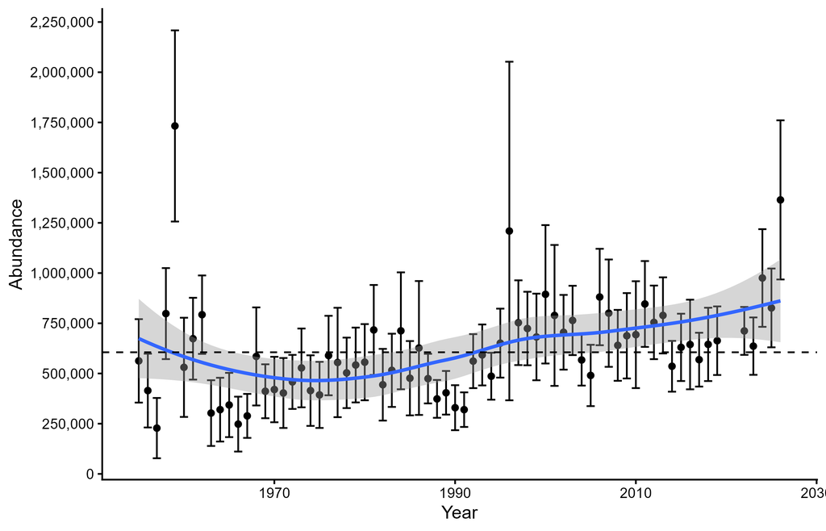

Figure 49: Goldeneye (Barrow’s and common spp.) abundance in the WBPHS Traditional Survey Area in spring. Circles are annual estimates of abundance with 95% confidence intervals. The blue line is a smoothed (Loess model) line with 95% confidence interval (shaded area) fit to the annual estimates. The black dashed reference line is the long term average.

### Data Table 65: Merganser WBPHS

Original data source: WBPHS Traditional Survey Area; USFWS Headquarters.

Table 65. Merganser (common, hooded, and red-breasted spp.) abundance in the WBPHS Traditional Survey Area in spring, 1955-2026.

| Year | TSA | Area1 | Area2 | Area3 | Area4 | Area5 | Area6 | Area7 | Area8 |
| --- | --- | --- | --- | --- | --- | --- | --- | --- | --- |
| 1955 | 1,108,437 | 610,345 | 361,627 | 93,959 | NA | 5,578 | 0 | 36,928 | 0 |
| 1956 | 1,158,096 | 594,604 | 413,999 | 80,324 | 692 | 770 | 31,516 | 36,192 | 0 |
| 1957 | 874,803 | 624,573 | 148,574 | 48,708 | 17,160 | NA | 0 | 35,787 | 0 |
| 1958 | 818,422 | 385,786 | 285,519 | 58,675 | 35,377 | 14,160 | 3,256 | 35,648 | 0 |
| 1959 | 1,200,811 | 472,587 | 502,838 | 150,686 | 31,231 | 7,779 | 0 | 35,690 | NA |
| 1960 | 1,037,678 | 626,406 | 264,636 | 44,806 | 50,562 | 14,951 | 483 | 35,833 | NA |
| 1961 | 884,771 | 565,965 | 131,254 | 102,246 | 37,859 | 11,428 | 0 | 36,018 | NA |
| 1962 | 951,400 | 742,225 | 90,671 | 43,670 | 24,724 | 13,905 | 0 | 36,204 | NA |
| 1963 | 849,017 | 506,027 | 232,526 | 30,088 | 34,063 | 9,914 | 0 | 36,399 | NA |
| 1964 | 786,608 | 624,289 | 17,672 | 50,986 | 37,997 | 19,162 | 0 | 36,502 | NA |
| 1965 | 654,329 | 383,256 | 76,636 | 137,870 | 24,002 | 12,829 | 685 | 19,052 | NA |
| 1966 | 508,508 | 261,344 | 152,656 | 56,087 | 19,015 | 16,943 | 0 | 138 | 2,325 |
| 1967 | 598,203 | 272,516 | 138,898 | 97,202 | 34,570 | 8,046 | 1,192 | 44,915 | 863 |
| 1968 | 599,866 | 351,249 | 73,080 | 113,070 | 15,014 | 4,923 | 343 | 42,187 | NA |
| 1969 | 742,312 | 384,305 | 85,286 | 170,198 | 23,506 | 28,629 | 0 | 42,867 | 7,520 |
| 1970 | 726,862 | 399,002 | 131,465 | 85,544 | 28,388 | 22,116 | 9,038 | 50,445 | 863 |
| 1971 | 755,964 | 367,339 | 122,435 | 90,883 | 49,958 | 47,294 | 14,788 | 63,268 | NA |
| 1972 | 496,158 | 199,166 | 120,743 | 67,252 | 30,538 | 26,725 | 16,753 | 33,666 | 1,316 |
| 1973 | 452,536 | 230,747 | 72,833 | 56,989 | 35,658 | 16,419 | 15,705 | 18,823 | 5,362 |
| 1974 | 467,268 | 269,202 | 39,613 | 62,018 | 29,195 | 25,200 | 15,372 | 22,772 | 3,897 |
| 1975 | 464,688 | 208,640 | 93,353 | 65,828 | 30,151 | 24,986 | 13,395 | 23,733 | 4,602 |
| 1976 | 420,410 | 171,849 | 57,848 | 97,570 | 19,807 | 34,759 | 6,354 | 28,251 | 3,971 |
| 1977 | 456,534 | 225,481 | 45,239 | 89,444 | 23,833 | 25,592 | 14,986 | 29,575 | 2,383 |
| 1978 | 657,616 | 266,008 | 63,605 | 205,993 | 30,234 | 35,289 | 20,456 | 29,250 | 6,780 |
| 1979 | 624,843 | 251,270 | 72,345 | 156,520 | 35,517 | 42,371 | 17,793 | 43,693 | 5,334 |
| 1980 | 552,667 | 229,166 | 61,360 | 123,395 | 21,053 | 43,968 | 30,021 | 37,313 | 6,392 |
| 1981 | 727,901 | 260,563 | 146,690 | 138,079 | 45,574 | 58,981 | 29,507 | 38,168 | 10,338 |
| 1982 | 683,122 | 297,158 | 78,911 | 98,414 | 40,301 | 62,481 | 22,514 | 51,660 | 31,684 |
| 1983 | 750,704 | 208,369 | 178,745 | 140,016 | 41,675 | 84,970 | 38,771 | 41,473 | 16,685 |
| 1984 | 686,882 | 247,176 | 73,055 | 114,955 | 46,810 | 91,321 | 29,762 | 58,294 | 25,509 |
| 1985 | 784,499 | 206,558 | 182,654 | 142,920 | 49,560 | 94,650 | 32,238 | 56,165 | 19,754 |
| 1986 | 805,298 | 184,820 | 177,375 | 144,632 | 79,626 | 117,335 | 39,126 | 40,769 | 21,615 |
| 1987 | 958,467 | 172,934 | 352,555 | 158,368 | 58,972 | 118,417 | 27,888 | 46,341 | 22,992 |
| 1988 | 1,115,857 | 196,496 | 288,852 | 223,260 | 95,545 | 116,221 | 53,178 | 108,391 | 33,914 |
| 1989 | 1,085,366 | 218,183 | 166,504 | 194,374 | 79,262 | 162,170 | 85,257 | 118,347 | 61,270 |
| 1990 | 1,110,110 | 247,388 | 139,163 | 212,638 | 113,796 | 184,035 | 42,615 | 119,018 | 51,457 |
| 1991 | 1,069,658 | 282,468 | 176,844 | 178,098 | 66,754 | 188,664 | 43,853 | 85,671 | 47,304 |
| 1992 | 1,079,908 | 272,975 | 164,267 | 185,508 | 100,102 | 140,492 | 45,423 | 114,232 | 56,910 |
| 1993 | 1,070,343 | 211,801 | 193,893 | 200,976 | 85,085 | 163,064 | 53,370 | 115,405 | 46,750 |
| 1994 | 1,146,378 | 296,216 | 113,618 | 211,068 | 129,029 | 196,620 | 36,111 | 102,414 | 61,301 |
| 1995 | 1,356,617 | 282,139 | 205,632 | 238,288 | 157,999 | 220,011 | 42,492 | 123,179 | 86,878 |
| 1996 | 1,359,171 | 319,049 | 200,011 | 222,897 | 160,180 | 176,800 | 48,255 | 125,166 | 106,812 |
| 1997 | 1,277,857 | 297,214 | 108,257 | 168,845 | 109,846 | 289,587 | 69,217 | 105,944 | 128,947 |
| 1998 | 1,505,661 | 290,652 | 153,368 | 184,178 | 191,615 | 373,284 | 51,407 | 111,632 | 149,524 |
| 1999 | 1,557,754 | 255,682 | 257,627 | 311,984 | 151,764 | 238,380 | 41,806 | 107,447 | 193,065 |
| 2000 | 1,778,758 | 249,972 | 230,446 | 269,947 | 269,503 | 294,412 | 42,760 | 144,826 | 276,892 |
| 2001 | 1,729,295 | 291,399 | 241,724 | 209,284 | 213,491 | 289,125 | 42,041 | 139,613 | 302,618 |
| 2002 | 1,627,739 | 202,847 | 274,857 | 297,117 | 196,938 | 288,865 | 72,656 | 118,581 | 175,876 |
| 2003 | 1,753,805 | 304,306 | 198,853 | 228,108 | 193,319 | 391,948 | 74,642 | 85,858 | 276,772 |
| 2004 | 1,667,902 | 203,208 | 212,254 | 283,647 | 214,612 | 267,235 | 124,172 | 99,047 | 263,726 |
| 2005 | 1,714,409 | 231,086 | 209,175 | 298,178 | 212,194 | 283,553 | 58,339 | 103,295 | 318,591 |
| 2006 | 1,770,423 | 281,661 | 233,093 | 209,248 | 181,515 | 303,543 | 137,514 | 112,497 | 311,352 |
| 2007 | 2,137,543 | 284,734 | 310,878 | 219,235 | 219,835 | 380,451 | 117,456 | 152,486 | 452,468 |
| 2008 | 2,380,258 | 362,447 | 375,905 | 332,067 | 330,786 | 419,878 | 125,866 | 124,389 | 308,920 |
| 2009 | 2,124,526 | 265,595 | 242,286 | 288,541 | 187,133 | 465,839 | 146,593 | 127,136 | 401,403 |
| 2010 | 2,456,433 | 429,544 | 386,364 | 291,662 | 190,199 | 396,696 | 181,268 | 124,684 | 456,016 |
| 2011 | 2,567,036 | 268,905 | 394,172 | 362,473 | 170,072 | 580,027 | 176,333 | 52,238 | 562,814 |
| 2012 | 2,895,974 | 265,154 | 375,449 | 378,927 | 250,884 | 723,905 | 167,838 | 90,247 | 643,570 |
| 2013 | 2,436,483 | 217,308 | 355,556 | 283,117 | 244,410 | 490,779 | 175,570 | 109,097 | 560,646 |
| 2014 | 2,353,311 | 271,723 | 299,034 | 452,569 | 226,157 | 443,407 | 142,806 | 86,062 | 431,554 |
| 2015 | 2,665,423 | 167,950 | 535,750 | 444,245 | 270,319 | 527,645 | 173,632 | 128,614 | 417,268 |
| 2016 | 3,309,739 | 320,140 | 490,630 | 576,314 | 365,612 | 728,613 | 215,400 | 197,416 | 415,615 |
| 2017 | 2,757,948 | 236,875 | 341,964 | 454,472 | 308,791 | 641,469 | 187,992 | 193,899 | 392,485 |
| 2018 | 2,863,476 | 184,787 | 394,585 | 453,871 | 357,423 | 719,921 | 215,649 | 175,466 | 361,772 |
| 2019 | 2,909,203 | 231,144 | 452,424 | 445,134 | 309,957 | 660,476 | 234,623 | 115,906 | 459,540 |
| 2020 | NA | NA | NA | NA | NA | NA | NA | NA | NA |
| 2021 | NA | NA | NA | NA | NA | NA | NA | NA | NA |
| 2022 | 3,348,450 | 144,024 | 504,247 | 482,704 | 439,473 | 622,739 | 229,767 | 189,909 | 735,587 |
| 2023 | 2,348,012 | 152,315 | 495,014 | 403,622 | 318,781 | 429,751 | 125,981 | 106,814 | 315,734 |
| 2024 | 2,428,130 | 160,745 | 482,638 | 517,023 | 194,150 | 535,431 | 152,344 | 107,578 | 278,222 |
| 2025 | 2,563,265 | 202,327 | 499,545 | 482,330 | 295,104 | 453,425 | 144,770 | 126,579 | 359,184 |
| 2026 | 2,012,377 | 146,175 | 381,705 | 275,087 | 255,713 | 406,643 | 94,666 | 171,188 | 281,200 |

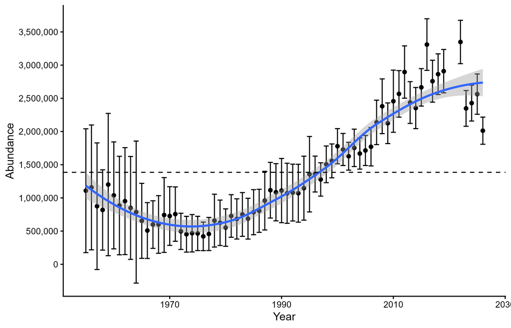

Figure 50: Merganser (common, hooded, and red-breasted spp.) bundance in the WBPHS Traditional Survey Area in spring. Circles are annual estimates of abundance with 95% confidence intervals. The blue line is a smoothed (Loess model) line with 95% confidence interval (shaded area) fit to the annual estimates. The black dashed reference line is the long term average.

### Data Table 66: Canada Goose WBPHS

Original data source: WBPHS Traditional Survey Area; USFWS Headquarters.

Table 66. Canada goose abundance in the WBPHS Traditional Survey Area in spring, 1955-2026.

| Year | TSA | Area1 | Area2 | Area3 | Area4 | Area5 | Area6 | Area7 | Area8 |
| --- | --- | --- | --- | --- | --- | --- | --- | --- | --- |
| 1955 | 14 | 0 | 0 | NA | NA | NA | NA | 14 | 0 |
| 1956 | 14 | 0 | 0 | NA | NA | NA | NA | 14 | 0 |
| 1957 | 14 | 0 | 0 | NA | NA | NA | NA | 14 | 0 |
| 1958 | 14 | 0 | 0 | NA | NA | NA | NA | 14 | 0 |
| 1959 | 14 | 0 | 0 | 0 | NA | NA | NA | 14 | NA |
| 1960 | 15 | 0 | 0 | NA | NA | NA | NA | 15 | NA |
| 1961 | 15 | 0 | 0 | NA | NA | NA | NA | 15 | NA |
| 1962 | 16 | 0 | 0 | NA | NA | NA | NA | 16 | NA |
| 1963 | 16 | 0 | 0 | NA | NA | NA | NA | 16 | NA |
| 1964 | 17 | 0 | 0 | 0 | NA | NA | NA | 17 | NA |
| 1965 | 166 | 166 | 0 | NA | NA | NA | NA | NA | NA |
| 1966 | 0 | 0 | 0 | NA | NA | NA | NA | NA | NA |
| 1967 | 0 | 0 | 0 | NA | NA | NA | NA | NA | NA |
| 1968 | 0 | 0 | 0 | NA | NA | NA | NA | NA | NA |
| 1969 | 0 | 0 | 0 | NA | NA | NA | NA | NA | NA |
| 1970 | 0 | 0 | NA | NA | NA | NA | NA | NA | NA |
| 1971 | 15 | 0 | NA | 15 | NA | NA | NA | NA | NA |
| 1972 | 93,541 | 63,642 | 29,899 | NA | NA | NA | NA | NA | NA |
| 1973 | 142,825 | 72,462 | 69,603 | 466 | 163 | NA | NA | 131 | NA |
| 1974 | 137,196 | 90,065 | 46,920 | 20 | 191 | NA | NA | NA | NA |
| 1975 | 122,421 | 77,541 | 7,225 | 31,209 | 6,315 | NA | NA | 131 | NA |
| 1976 | 184,301 | 154,378 | 27,845 | 1,362 | 716 | NA | NA | NA | NA |
| 1977 | 135,360 | 94,488 | 36,949 | 1,525 | 1,893 | NA | NA | 506 | NA |
| 1978 | 136,923 | 102,479 | 24,654 | 9,660 | NA | NA | NA | 131 | NA |
| 1979 | 161,195 | 112,175 | 44,387 | 4,109 | NA | NA | 524 | NA | NA |
| 1980 | 166,335 | 111,175 | 43,485 | 11,674 | NA | NA | NA | NA | NA |
| 1981 | 194,307 | 106,905 | 82,305 | 5,097 | NA | NA | NA | NA | NA |
| 1982 | 179,387 | 136,281 | 42,654 | 134 | 318 | NA | NA | NA | NA |
| 1983 | 212,834 | 118,970 | 86,732 | 7,133 | NA | NA | NA | NA | NA |
| 1984 | 151,516 | 95,496 | 51,281 | 2 | 199 | NA | 4,285 | 253 | NA |
| 1985 | 220,187 | 140,679 | 76,368 | 0 | 163 | NA | 2,471 | 506 | NA |
| 1986 | 165,748 | 100,721 | 61,948 | NA | NA | 287 | 2,792 | NA | NA |
| 1987 | 213,241 | 125,811 | 83,443 | 644 | NA | 300 | 3,043 | NA | NA |
| 1988 | 195,089 | 135,667 | 52,760 | NA | 155 | 3,450 | 3,057 | NA | NA |
| 1989 | 273,996 | 215,238 | 58,587 | NA | NA | NA | NA | NA | 171 |
| 1990 | 303,481 | 267,220 | 33,859 | NA | 357 | 1,243 | NA | 354 | 448 |
| 1991 | 146,926 | 129,177 | 16,275 | NA | NA | 199 | NA | 506 | 770 |
| 1992 | 203,085 | 128,746 | 32,736 | 40,002 | 203 | NA | 1,228 | NA | 171 |
| 1993 | 172,836 | 138,026 | 32,922 | 1,755 | NA | 133 | NA | NA | NA |
| 1994 | 182,207 | 157,630 | 19,318 | 487 | NA | 502 | 3,934 | 335 | NA |
| 1995 | 280,547 | 175,378 | 87,124 | 17,852 | NA | 133 | NA | 61 | NA |
| 1996 | 188,847 | 172,322 | 14,301 | 1,133 | 210 | 880 | NA | NA | NA |
| 1997 | 267,960 | 212,828 | 43,333 | 4,546 | 902 | 862 | 5,489 | NA | NA |
| 1998 | 214,579 | 214,579 | NA | NA | NA | NA | NA | NA | NA |
| 1999 | 243,982 | 194,463 | 40,956 | 6,693 | 395 | 1,327 | NA | 148 | NA |
| 2000 | 214,298 | 174,382 | 27,313 | 7,243 | 155 | 1,599 | 3,057 | 392 | 156 |
| 2001 | 162,938 | 136,318 | 22,937 | 1,587 | 610 | 509 | 977 | NA | NA |
| 2002 | 139,662 | 116,138 | 17,693 | 2,766 | 803 | 302 | 1,743 | 131 | 86 |
| 2003 | 144,336 | 106,783 | 28,781 | 4,175 | 662 | 75 | 3,490 | NA | 370 |
| 2004 | 161,204 | 116,295 | 23,798 | 19,664 | 464 | 929 | 54 | NA | NA |
| 2005 | 201,645 | 154,881 | 35,210 | 1,475 | 1,271 | 2,525 | 6,283 | NA | NA |
| 2006 | 190,945 | 164,945 | 17,851 | 3,696 | 1,942 | 1,404 | 1,107 | NA | NA |
| 2007 | 243,604 | 202,367 | 35,371 | 4,508 | NA | 974 | 385 | NA | NA |
| 2008 | 192,010 | 160,623 | 20,427 | 2,037 | 1,687 | 3,922 | 3,313 | NA | NA |
| 2009 | 199,807 | 125,198 | 27,149 | 44,252 | NA | 148 | 2,993 | 66 | NA |
| 2010 | 169,244 | 120,466 | 43,766 | 3,993 | 195 | 585 | 239 | NA | NA |
| 2011 | 195,231 | 121,916 | 33,887 | 37,551 | NA | 691 | 717 | NA | 467 |
| 2012 | 173,652 | 123,595 | 45,565 | 2,583 | 293 | 1,057 | 453 | NA | 106 |
| 2013 | 152,366 | 118,128 | 31,988 | 793 | 163 | 281 | 506 | NA | 505 |
| 2014 | 136,439 | 95,580 | 28,316 | 1,108 | 252 | 7,621 | 3,561 | NA | NA |
| 2015 | 174,921 | 118,183 | 47,526 | 8,449 | NA | 198 | 565 | NA | NA |
| 2016 | 167,003 | 118,092 | 40,636 | 6,911 | 78 | 460 | 398 | 67 | 359 |
| 2017 | 182,973 | 117,556 | 54,125 | 9,611 | 177 | 290 | 724 | NA | 490 |
| 2018 | 166,589 | 110,111 | 32,187 | 17,970 | 1,196 | 290 | 4,247 | 132 | 456 |
| 2019 | 158,905 | 104,344 | 31,546 | 18,896 | 589 | 1,006 | 2,337 | NA | 187 |
| 2020 | NA | NA | NA | NA | NA | NA | NA | NA | NA |
| 2021 | NA | NA | NA | NA | NA | NA | NA | NA | NA |
| 2022 | 181,987 | 113,797 | 42,808 | 22,485 | 276 | 675 | 1,447 | NA | 499 |
| 2023 | 143,071 | 83,063 | 24,522 | 30,490 | 693 | 1,954 | 1,619 | 730 | NA |
| 2024 | 170,787 | 83,283 | 46,962 | 34,145 | 1,032 | 3,276 | 1,567 | NA | 523 |
| 2025 | 213,946 | 90,605 | 44,154 | 76,351 | 343 | 867 | 944 | NA | 683 |
| 2026 | 188,011 | 83,431 | 47,765 | 50,604 | 875 | 2,168 | 1,979 | 633 | 554 |

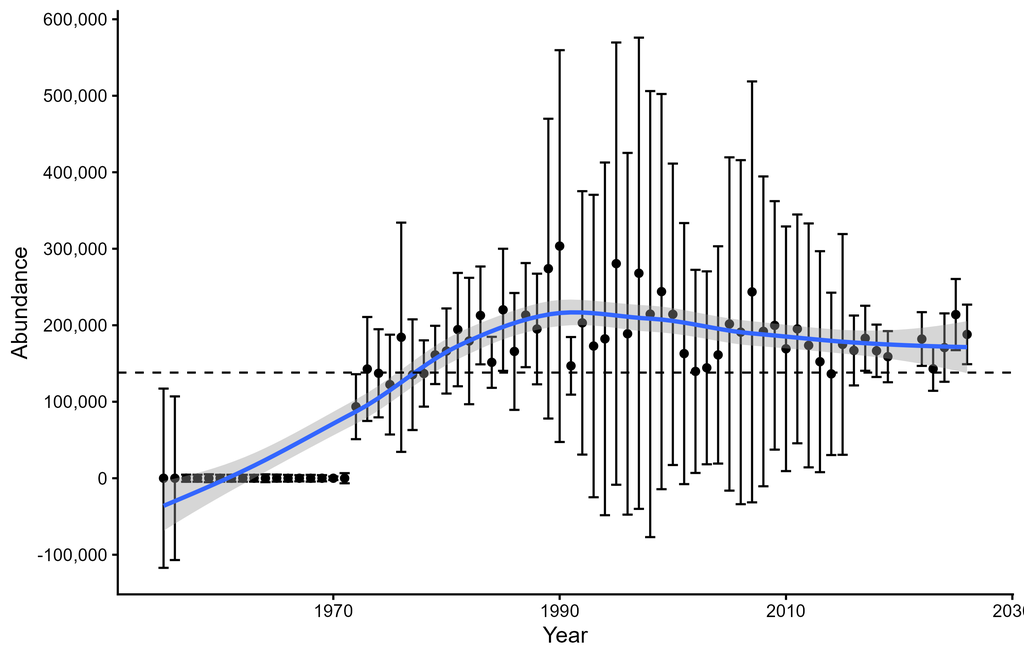

Figure 51: Canada goose abundance in the WBPHS Traditional Survey Area in spring. Circles are annual estimates of abundance with 95% confidence intervals. The blue line is a smoothed (Loess model) line with 95% confidence interval (shaded area) fit to the annual estimates. The black dashed reference line is the long term average.

### Data Table 67: Swan WBPHS

Original data source: WBPHS Traditional Survey Area; USFWS Headquarters.

Table 67. Swan abundance in the WBPHS Traditional Survey Area in spring, 1955-2026.

| Year | TSA | Area1 | Area2 | Area3 | Area4 | Area5 | Area6 | Area7 | Area8 |
| --- | --- | --- | --- | --- | --- | --- | --- | --- | --- |
| 1955 | 422,304 | 1,233 | 151,416 | 268,214 | NA | 455 | 196 | 789 | 0 |
| 1956 | 226,934 | 1,226 | 99,215 | 125,639 | NA | NA | 0 | 853 | 0 |
| 1957 | 193,020 | 418 | 87,253 | 104,438 | NA | NA | 0 | 911 | 0 |
| 1958 | 441,521 | 1,363 | 176,943 | 256,099 | 5,940 | NA | 193 | 963 | 21 |
| 1959 | 332,099 | 139 | 194,348 | 132,226 | 3,960 | 420 | 0 | 1,006 | NA |
| 1960 | 431,242 | 1,115 | 175,828 | 239,763 | 1,188 | 11,361 | 945 | 1,042 | NA |
| 1961 | 281,354 | 456 | 148,953 | 127,505 | 396 | 2,596 | 376 | 1,072 | NA |
| 1962 | 319,002 | 7,721 | 96,812 | 213,369 | NA | NA | 0 | 1,100 | NA |
| 1963 | 364,370 | 4,706 | 105,154 | 243,809 | NA | 9,399 | 0 | 1,302 | NA |
| 1964 | 287,031 | 597 | 99,210 | 172,354 | 1,584 | 2,433 | 9,691 | 1,162 | NA |
| 1965 | 344,012 | 2,054 | 109,084 | 207,765 | 9,268 | 5,219 | 8,957 | 1,665 | NA |
| 1966 | 326,022 | 2,132 | 78,950 | 231,160 | 7,746 | NA | 4,470 | 233 | 1,331 |
| 1967 | 400,185 | 7,715 | 58,742 | 324,226 | 1,814 | NA | 0 | 7,688 | NA |
| 1968 | 272,806 | 309 | 19,815 | 249,696 | 1,100 | 989 | 188 | 708 | NA |
| 1969 | 377,076 | 959 | 30,213 | 339,148 | 1,691 | 1,443 | 759 | 2,863 | NA |
| 1970 | 340,272 | 2,368 | 48,584 | 268,300 | 9,443 | 8,809 | 2,768 | NA | NA |
| 1971 | 258,049 | 1,786 | 17,977 | 232,374 | 4,056 | 1,260 | 595 | NA | NA |
| 1972 | 325,771 | 6,056 | 30,633 | 277,156 | 4,187 | NA | 5,599 | 2,140 | NA |
| 1973 | 286,191 | 3,755 | 32,672 | 235,672 | 2,101 | 2,178 | 7,470 | 2,343 | NA |
| 1974 | 315,677 | 3,355 | 21,125 | 269,667 | NA | 455 | 16,818 | 4,257 | NA |
| 1975 | 495,385 | 5,155 | 33,624 | 416,094 | 16,428 | 7,523 | 15,145 | 1,416 | NA |
| 1976 | 355,104 | 2,199 | 85,644 | 256,347 | NA | 5,323 | 4,764 | 827 | NA |
| 1977 | 494,457 | 7,852 | 143,165 | 323,670 | 4,800 | 3,364 | 8,950 | 2,656 | NA |
| 1978 | 665,003 | 11,504 | 168,550 | 450,802 | 16,088 | 6,486 | 9,624 | 1,948 | NA |
| 1979 | 491,048 | 5,535 | 124,388 | 308,489 | 5,678 | 12,983 | 27,356 | 4,073 | 2,546 |
| 1980 | 649,377 | 5,230 | 138,964 | 434,005 | 17,961 | 6,849 | 45,568 | 800 | NA |
| 1981 | 557,177 | 6,721 | 53,313 | 413,307 | 13,594 | 14,552 | 47,188 | 8,502 | NA |
| 1982 | 407,775 | 8,662 | 60,497 | 298,868 | 15,473 | 3,431 | 11,642 | 3,430 | 5,772 |
| 1983 | 641,437 | 7,228 | 78,522 | 461,967 | 15,322 | 5,941 | 60,491 | NA | 11,966 |
| 1984 | 619,018 | 20,221 | 116,503 | 427,788 | 4,906 | 17,722 | 21,659 | 5,607 | 4,613 |
| 1985 | 542,473 | 25,064 | 75,508 | 403,917 | 8,875 | 1,855 | 26,003 | 708 | 543 |
| 1986 | 445,744 | 24,710 | 34,330 | 363,322 | 8,645 | NA | 11,962 | 2,775 | NA |
| 1987 | 548,077 | 21,569 | 69,242 | 423,606 | 10,069 | 6,872 | 14,228 | 1,948 | 543 |
| 1988 | 526,758 | 24,094 | 62,811 | 397,478 | 21,560 | 5,817 | 11,487 | 3,017 | 494 |
| 1989 | 440,937 | 8,420 | 74,537 | 320,212 | 8,593 | 3,650 | 19,204 | 5,241 | 1,080 |
| 1990 | 447,878 | 10,141 | 91,708 | 292,192 | 4,982 | 7,945 | 34,190 | 4,548 | 2,172 |
| 1991 | 543,841 | 14,142 | 44,707 | 440,703 | 15,245 | 6,458 | 11,092 | 8,923 | 2,571 |
| 1992 | 547,418 | 19,222 | 125,943 | 372,391 | 8,721 | 3,820 | 16,056 | 1,266 | NA |
| 1993 | 528,314 | 23,047 | 71,091 | 410,540 | 6,295 | 3,548 | 10,407 | 3,093 | 293 |
| 1994 | 801,020 | 21,038 | 109,992 | 649,562 | 6,943 | 2,282 | 6,199 | 4,499 | 506 |
| 1995 | 610,362 | 16,648 | 70,811 | 491,555 | 10,436 | 7,544 | 4,408 | 7,025 | 1,935 |
| 1996 | 797,726 | 39,454 | 31,939 | 686,363 | 5,931 | 4,005 | 26,171 | 3,067 | 797 |
| 1997 | 852,869 | 25,159 | 49,740 | 697,839 | 9,796 | 6,455 | 53,357 | 9,152 | 1,371 |
| 1998 | 409,939 | 24,670 | 48,519 | 313,895 | 5,416 | 6,773 | 4,652 | 4,976 | 1,037 |
| 1999 | 476,592 | 15,102 | 96,031 | 299,814 | 8,136 | 2,623 | 38,879 | 16,006 | NA |
| 2000 | 762,848 | 32,794 | 187,976 | 484,305 | 5,061 | 9,187 | 26,394 | 15,215 | 1,914 |
| 2001 | 708,932 | 27,356 | 109,312 | 517,384 | 8,471 | 21,194 | 16,060 | 7,991 | 1,164 |
| 2002 | 1,048,311 | 22,772 | 96,605 | 893,503 | 10,460 | 2,960 | 10,979 | 11,032 | NA |
| 2003 | 1,028,957 | 20,416 | 116,609 | 876,838 | 2,560 | 2,427 | 6,618 | 3,489 | NA |
| 2004 | 1,082,580 | 22,012 | 46,745 | 997,439 | 4,211 | 3,078 | 6,064 | 1,819 | 1,211 |
| 2005 | 637,203 | 36,247 | 36,445 | 546,148 | 1,927 | 4,141 | 9,548 | 2,747 | NA |
| 2006 | 560,923 | 27,033 | 66,657 | 442,098 | 1,627 | 3,129 | 17,994 | 2,051 | 333 |
| 2007 | 630,683 | 36,686 | 91,875 | 479,444 | 2,888 | 5,285 | 14,251 | 255 | NA |
| 2008 | 793,127 | 27,235 | 94,530 | 601,416 | 7,723 | 3,590 | 56,632 | 1,709 | 291 |
| 2009 | 703,661 | 24,499 | 109,337 | 528,382 | 16,411 | 9,075 | 10,982 | 4,974 | NA |
| 2010 | 688,776 | 30,975 | 130,363 | 474,563 | 21,095 | 5,586 | 22,109 | 1,680 | 2,406 |
| 2011 | 738,619 | 29,520 | 122,272 | 553,212 | 7,527 | 5,974 | 12,401 | 4,171 | 3,541 |
| 2012 | 626,749 | 33,602 | 78,057 | 470,765 | 23,287 | 2,147 | 10,722 | 6,301 | 1,869 |
| 2013 | 392,065 | 18,322 | 114,678 | 223,381 | 7,201 | 8,853 | 10,195 | 3,129 | 6,307 |
| 2014 | 672,165 | 29,803 | 124,487 | 458,222 | 2,661 | 12,161 | 25,232 | 11,456 | 8,142 |
| 2015 | 876,815 | 32,494 | 134,966 | 664,078 | 20,650 | 6,743 | 15,178 | 767 | 1,939 |
| 2016 | 911,701 | 27,156 | 115,186 | 727,986 | 14,851 | 9,907 | 10,602 | 2,248 | 3,766 |
| 2017 | 999,239 | 44,457 | 52,183 | 862,058 | 15,762 | 16,463 | 4,817 | 1,675 | 1,824 |
| 2018 | 876,574 | 37,441 | 59,680 | 750,374 | 3,082 | 5,629 | 13,977 | 3,995 | 2,395 |
| 2019 | 662,728 | 27,392 | 81,348 | 505,697 | 5,776 | 10,454 | 8,444 | 19,360 | 4,256 |
| 2020 | NA | NA | NA | NA | NA | NA | NA | NA | NA |
| 2021 | NA | NA | NA | NA | NA | NA | NA | NA | NA |
| 2022 | 708,987 | 20,577 | 92,501 | 552,223 | 6,093 | 11,528 | 19,414 | 4,056 | 2,594 |
| 2023 | 757,376 | 31,080 | 117,758 | 582,753 | 5,929 | 5,026 | 7,174 | 1,798 | 5,859 |
| 2024 | 857,212 | 31,926 | 107,124 | 687,902 | 3,760 | 7,134 | 13,591 | 3,198 | 2,577 |
| 2025 | 863,115 | 45,712 | 151,130 | 617,643 | 10,651 | 11,920 | 15,014 | 4,243 | 6,803 |
| 2026 | 784,590 | 43,974 | 115,989 | 578,247 | 7,376 | 18,917 | 10,256 | 7,912 | 1,918 |

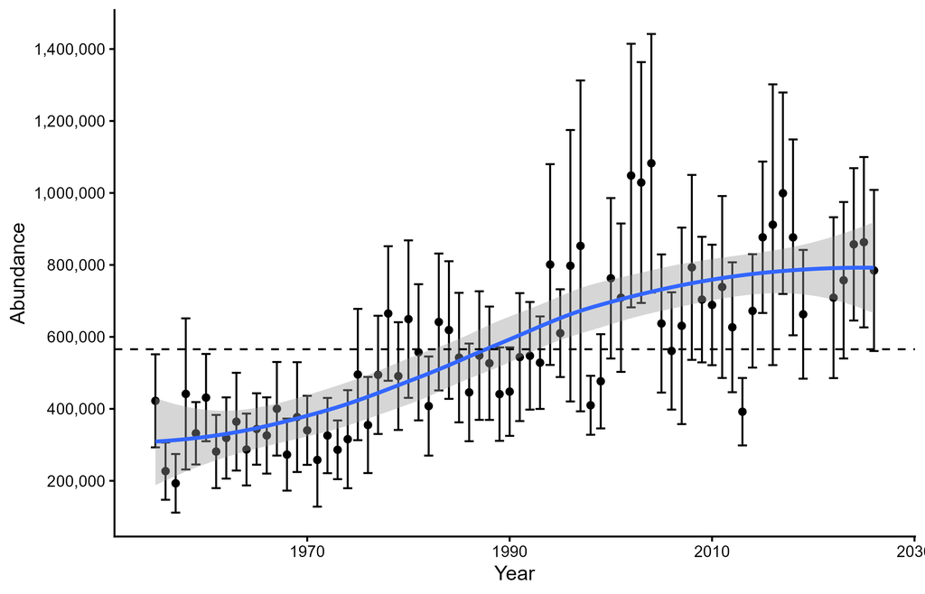

Figure 52: Swan abundance in the WBPHS Traditional Survey Area in spring. Circles are annual estimates of abundance with 95% confidence intervals. The blue line is a smoothed (Loess model) line with 95% confidence interval (shaded area) fit to the annual estimates. The black dashed reference line is the long term average.

### Data Table 68: American Coot WBPHS

Original data source: WBPHS Traditional Survey Area; USFWS Headquarters.

Table 68. American coot abundance in the WBPHS Traditional Survey Area in spring, 1955-2026.

| Year | TSA | Area1 | Area2 | Area3 | Area4 | Area5 | Area6 | Area7 | Area8 |
| --- | --- | --- | --- | --- | --- | --- | --- | --- | --- |
| 1955 | 654,372 | 85 | 30,748 | NA | 141,262 | 360,714 | 18,772 | 49,259 | 53,532 |
| 1956 | 869,216 | 238 | 5,473 | NA | 108,038 | 604,698 | 45,684 | 46,436 | 58,649 |
| 1957 | 632,467 | 5 | 0 | NA | 56,605 | 438,843 | 27,830 | 44,431 | 64,753 |
| 1958 | 424,735 | 0 | 0 | NA | 98,069 | 127,546 | 76,960 | 46,586 | 75,574 |
| 1959 | 944,514 | 0 | 156,775 | 138,300 | 169,760 | 145,323 | 170,796 | 54,926 | 108,634 |
| 1960 | 525,652 | 0 | 3,884 | 41,852 | 120,075 | 111,952 | 87,532 | 39,973 | 120,384 |
| 1961 | 584,168 | 5 | 62,589 | 114,327 | 92,872 | 70,527 | 125,400 | 41,175 | 77,273 |
| 1962 | 383,055 | 0 | 23,713 | 24,690 | 19,746 | 78,951 | 32,780 | 38,259 | 164,916 |
| 1963 | 375,799 | 6,353 | 22,846 | 86,096 | 82,177 | 27,371 | 43,635 | 45,559 | 61,762 |
| 1964 | 340,280 | 6 | 18,799 | 86,047 | 39,957 | 50,484 | 37,394 | 39,997 | 67,596 |
| 1965 | 397,989 | 6 | 5,654 | 90,386 | 65,136 | 63,564 | 46,199 | 24,481 | 102,564 |
| 1966 | 441,544 | 6 | 35,540 | 50,462 | 48,130 | 83,356 | 20,318 | 32,620 | 171,112 |
| 1967 | 822,466 | 6 | 6,608 | 105,549 | 202,542 | 178,983 | 74,096 | 36,993 | 217,690 |
| 1968 | 1,284,008 | 6 | 82,071 | 581,132 | 98,780 | 214,325 | 46,404 | 69,579 | 191,711 |
| 1969 | 775,394 | 6 | 13,549 | 39,187 | 144,825 | 203,789 | 120,689 | 43,784 | 209,564 |
| 1970 | 1,168,192 | 7 | 9,611 | 62,932 | 169,841 | 450,341 | 169,108 | 60,629 | 245,723 |
| 1971 | 960,145 | 7 | 20,484 | 45,333 | 99,723 | 481,517 | 120,880 | 18,832 | 173,369 |
| 1972 | 933,308 | 7 | 32,012 | 26,785 | 122,608 | 284,899 | 159,683 | 66,982 | 240,332 |
| 1973 | 1,236,505 | 7 | 167,405 | 99,558 | 145,425 | 465,919 | 69,406 | 89,131 | 199,654 |
| 1974 | 1,513,180 | 7 | 30,827 | 21,797 | 266,979 | 544,311 | 230,322 | 58,588 | 360,350 |
| 1975 | 2,257,919 | 7 | 36,637 | 52,858 | 483,329 | 799,782 | 282,924 | 64,175 | 538,207 |
| 1976 | 2,392,079 | 7 | 27,056 | 67,812 | 83,519 | 1,512,966 | 470,430 | 110,452 | 119,837 |
| 1977 | 1,664,828 | 7 | 428,722 | 318,816 | 285,358 | 269,357 | 179,959 | 114,314 | 68,295 |
| 1978 | 1,444,124 | 7 | 65,559 | 75,853 | 168,357 | 317,848 | 111,315 | 158,991 | 546,194 |
| 1979 | 3,458,968 | 7 | 7,730 | 29,570 | 417,979 | 787,159 | 182,855 | 528,084 | 1,505,584 |
| 1980 | 2,956,046 | 7 | 415,657 | 497,244 | 501,055 | 634,230 | 330,575 | 128,516 | 448,762 |
| 1981 | 2,682,441 | 7 | 198,729 | 777,010 | 405,024 | 395,073 | 157,473 | 228,089 | 521,035 |
| 1982 | 1,668,518 | 7 | 68,725 | 123,476 | 371,736 | 175,368 | 111,878 | 68,870 | 748,458 |
| 1983 | 1,820,007 | 7 | 138,412 | 40,315 | 253,247 | 546,681 | 123,936 | 117,217 | 600,193 |
| 1984 | 2,903,119 | 94 | 91,666 | 116,860 | 542,666 | 507,406 | 38,308 | 218,321 | 1,387,798 |
| 1985 | 1,682,385 | NA | 69,291 | 70,032 | 327,286 | 530,572 | 33,778 | 223,265 | 428,161 |
| 1986 | 1,699,157 | NA | 34,233 | 22,373 | 282,225 | 315,049 | 212,457 | 39,596 | 793,224 |
| 1987 | 1,780,300 | NA | 83,629 | 255,144 | 137,883 | 241,678 | 77,065 | 47,711 | 937,190 |
| 1988 | 3,223,206 | NA | 232,749 | 340,855 | 166,147 | 930,687 | 591,810 | 124,800 | 836,158 |
| 1989 | 1,640,876 | NA | 158,090 | 199,565 | 349,532 | 276,168 | 60,145 | 110,533 | 486,844 |
| 1990 | 1,664,462 | NA | 197,152 | 61,738 | 485,709 | 261,462 | 151,795 | 195,396 | 311,210 |
| 1991 | 1,151,959 | NA | 92,552 | 143,595 | 279,675 | 366,579 | 81,071 | 113,526 | 74,961 |
| 1992 | 1,380,235 | NA | 114,937 | 67,569 | 307,393 | 442,607 | 215,542 | 19,991 | 212,197 |
| 1993 | 1,025,062 | NA | 92,495 | 167,011 | 282,101 | 111,818 | 32,198 | 80,306 | 259,134 |
| 1994 | 1,712,227 | NA | 50,381 | 32,252 | 234,680 | 383,314 | 35,778 | 77,140 | 898,682 |
| 1995 | 3,438,877 | NA | 37,511 | 21,824 | 232,937 | 625,223 | 195,400 | 67,097 | 2,258,884 |
| 1996 | 3,131,109 | NA | 41,342 | 15,484 | 234,396 | 868,111 | 281,166 | 81,590 | 1,609,019 |
| 1997 | 4,915,601 | NA | 253,835 | 19,161 | 377,464 | 1,661,101 | 282,918 | 346,183 | 1,974,940 |
| 1998 | 3,138,078 | NA | 467,038 | 60,300 | 260,003 | 594,337 | 506,699 | 201,210 | 1,048,492 |
| 1999 | 3,069,152 | NA | 159,571 | 57,896 | 342,322 | 823,675 | 162,542 | 192,611 | 1,330,535 |
| 2000 | 3,659,459 | NA | 615,563 | 209,259 | 418,760 | 848,496 | 284,810 | 117,226 | 1,165,344 |
| 2001 | 1,845,852 | NA | 87,215 | 73,741 | 207,397 | 679,246 | 315,350 | 84,329 | 398,574 |
| 2002 | 2,518,449 | NA | 584,907 | 294,583 | 376,090 | 306,829 | 246,718 | 65,048 | 644,275 |
| 2003 | 1,195,485 | NA | 101,998 | 12,393 | 222,264 | 633,882 | 107,401 | 27,219 | 90,329 |
| 2004 | 1,862,040 | NA | 294,932 | 105,426 | 240,183 | 536,335 | 83,747 | 85,186 | 516,231 |
| 2005 | 1,591,035 | NA | 220,265 | 25,509 | 240,935 | 806,864 | 175,411 | 18,123 | 103,928 |
| 2006 | 2,102,263 | NA | 195,126 | 19,994 | 418,974 | 1,188,247 | 103,699 | 23,264 | 152,958 |
| 2007 | 2,591,169 | 468 | 87,724 | 25,832 | 444,380 | 1,406,277 | 81,656 | 66,738 | 478,095 |
| 2008 | 3,625,954 | NA | 281,459 | 43,538 | 667,924 | 1,640,884 | 129,965 | 244,744 | 617,439 |
| 2009 | 2,259,385 | NA | 62,253 | 42,205 | 321,137 | 601,935 | 253,161 | 128,910 | 849,784 |
| 2010 | 2,409,179 | NA | 129,577 | 5,177 | 333,652 | 590,896 | 46,784 | 151,379 | 1,151,715 |
| 2011 | 3,624,396 | NA | 49,405 | 9,113 | 488,029 | 1,336,121 | 226,997 | 117,293 | 1,397,439 |
| 2012 | 4,700,325 | NA | 88,659 | 3,952 | 498,022 | 2,333,385 | 110,731 | 110,888 | 1,554,685 |
| 2013 | 2,819,367 | NA | 41,866 | 2,153 | 521,606 | 1,106,576 | 141,258 | 27,334 | 978,573 |
| 2014 | 4,004,160 | NA | 45,556 | 2,907 | 775,060 | 1,505,727 | 208,362 | 244,294 | 1,222,254 |
| 2015 | 3,064,423 | NA | 134,372 | 12,868 | 420,134 | 1,792,217 | 256,800 | 114,825 | 333,209 |
| 2016 | 2,818,801 | NA | 142,341 | 5,930 | 376,842 | 1,482,890 | 204,577 | 120,712 | 485,510 |
| 2017 | 2,146,931 | NA | 43,184 | 1,429 | 547,897 | 929,750 | 161,970 | 24,550 | 438,151 |
| 2018 | 1,602,978 | NA | 58,946 | 3,300 | 295,120 | 356,532 | 149,497 | 250,255 | 489,329 |
| 2019 | 1,644,905 | NA | 45,703 | 20,300 | 543,264 | 142,118 | 15,170 | 118,401 | 759,949 |
| 2020 | NA | NA | NA | NA | NA | NA | NA | NA | NA |
| 2021 | NA | NA | NA | NA | NA | NA | NA | NA | NA |
| 2022 | 1,175,333 | NA | 116,452 | 20,856 | 275,090 | 231,645 | 52,596 | 23,075 | 455,618 |
| 2023 | 964,444 | NA | 41,901 | 1,374 | 80,136 | 194,586 | 50,929 | 19,871 | 575,647 |
| 2024 | 1,254,151 | NA | 65,150 | 7,088 | 152,265 | 413,800 | 49,130 | 79,785 | 486,934 |
| 2025 | 1,124,421 | NA | 26,174 | 11,748 | 106,508 | 667,831 | 107,578 | 57,575 | 147,006 |
| 2026 | 1,871,791 | NA | 87,460 | 5,039 | 344,242 | 916,256 | 127,813 | 64,114 | 326,866 |

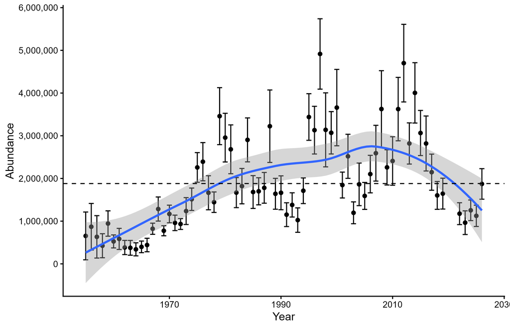

Figure 53: American coot abundance in the WBPHS Traditional Survey Area in spring. Circles are annual estimates of abundance with 95% confidence intervals. The blue line is a smoothed (Loess model) line with 95% confidence interval (shaded area) fit to the annual estimates. The black dashed reference line is the long term average.

### Data Table 69: Total Ducks State Surveys

Original data source: Breeding Waterfowl Surveys in Michigan, Minnesota, and Wisconsin. Data maintained by Michigan, Minnesota, Wisconsin, and USFWS Mississippi Flyway Office.

Table 69. Total duck abundance in Missississpi Flyway States in spring, 1968-2026.

| Year | MI | MI.SE | MN | MN.SE | WI | WI.SE | Total | Total.SE |
| --- | --- | --- | --- | --- | --- | --- | --- | --- |
| 1968 | NA | NA | 320,994 | NA | NA | NA | NA | NA |
| 1969 | NA | NA | 323,213 | NA | NA | NA | NA | NA |
| 1970 | NA | NA | 324,219 | NA | NA | NA | NA | NA |
| 1971 | NA | NA | 277,137 | NA | NA | NA | NA | NA |
| 1972 | NA | NA | 217,181 | NA | NA | NA | NA | NA |
| 1973 | NA | NA | 389,486 | NA | 412,707 | 54,448 | NA | NA |
| 1974 | NA | NA | 281,605 | NA | 435,183 | 32,945 | NA | NA |
| 1975 | NA | NA | 471,608 | NA | 426,875 | 53,924 | NA | NA |
| 1976 | NA | NA | 684,082 | NA | 379,526 | 43,874 | NA | NA |
| 1977 | NA | NA | 501,099 | NA | 323,281 | 36,836 | NA | NA |
| 1978 | NA | NA | 462,502 | NA | 271,349 | 37,781 | NA | NA |
| 1979 | NA | NA | 552,416 | NA | 265,730 | 28,736 | NA | NA |
| 1980 | NA | NA | 690,593 | NA | 248,071 | 23,873 | NA | NA |
| 1981 | NA | NA | 439,769 | NA | 505,038 | 55,165 | NA | NA |
| 1982 | NA | NA | 465,185 | NA | 218,719 | 23,918 | NA | NA |
| 1983 | NA | NA | 367,142 | NA | 202,295 | 22,978 | NA | NA |
| 1984 | NA | NA | 528,679 | NA | 209,995 | 19,555 | NA | NA |
| 1985 | NA | NA | 562,898 | NA | 192,795 | 21,146 | NA | NA |
| 1986 | NA | NA | 520,787 | NA | 262,016 | 23,219 | NA | NA |
| 1987 | NA | NA | 588,954 | NA | 389,833 | 33,578 | NA | NA |
| 1988 | NA | NA | 725,238 | NA | 287,075 | 27,498 | NA | NA |
| 1989 | NA | NA | 813,615 | NA | 462,513 | 45,238 | NA | NA |
| 1990 | NA | NA | 807,870 | NA | 328,630 | 28,272 | NA | NA |
| 1991 | 408,435 | 58,574 | 753,710 | NA | 435,782 | 40,618 | 1,597,927 | NA |
| 1992 | 867,474 | 195,535 | 973,323 | NA | 683,804 | 57,738 | 2,524,601 | NA |
| 1993 | 742,752 | 118,971 | 837,172 | NA | 379,371 | 31,384 | 1,959,295 | NA |
| 1994 | 718,132 | 89,935 | 1,115,558 | NA | 571,232 | 54,664 | 2,404,922 | NA |
| 1995 | 791,851 | 98,293 | 797,144 | NA | 592,419 | 49,560 | 2,181,414 | NA |
| 1996 | 680,483 | 75,466 | 889,057 | NA | 536,306 | 48,264 | 2,105,846 | NA |
| 1997 | 783,978 | 83,249 | 868,137 | NA | 409,314 | 43,173 | 2,061,429 | NA |
| 1998 | 1,068,450 | 130,435 | 693,084 | NA | 412,799 | 43,390 | 2,174,333 | NA |
| 1999 | 744,612 | 103,052 | 680,463 | NA | 476,632 | 46,015 | 1,901,707 | NA |
| 2000 | 793,854 | 119,618 | 747,779 | NA | 744,390 | 71,466 | 2,286,023 | NA |
| 2001 | 497,788 | 55,474 | 716,353 | NA | 440,128 | 43,459 | 1,654,269 | NA |
| 2002 | 742,522 | 121,336 | 1,171,537 | NA | 740,792 | 67,337 | 2,654,851 | NA |
| 2003 | 535,377 | 66,446 | 721,805 | NA | 533,466 | 50,290 | 1,790,648 | NA |
| 2004 | 624,468 | 77,032 | 1,008,324 | NA | 651,493 | 68,455 | 2,284,285 | NA |
| 2005 | 468,342 | 54,080 | 631,980 | NA | 724,270 | 71,564 | 1,824,592 | NA |
| 2006 | 412,221 | 57,424 | 521,109 | NA | 522,571 | 51,502 | 1,455,901 | NA |
| 2007 | 641,861 | 66,093 | 488,517 | NA | 470,614 | 51,502 | 1,600,992 | NA |
| 2008 | 437,528 | 65,274 | 739,553 | NA | 626,924 | 77,236 | 1,804,005 | NA |
| 2009 | 493,597 | 58,614 | 541,266 | NA | 502,416 | 45,462 | 1,537,279 | NA |
| 2010 | 596,827 | 83,850 | 530,744 | NA | 386,501 | 39,350 | 1,514,072 | NA |
| 2011 | 472,276 | 52,836 | 687,499 | NA | 513,746 | 48,224 | 1,673,521 | NA |
| 2012 | 860,719 | 181,383 | 468,589 | NA | 521,076 | 52,624 | 1,850,384 | NA |
| 2013 | 678,554 | 89,606 | 682,895 | NA | 527,340 | 55,091 | 1,888,789 | NA |
| 2014 | 395,324 | 46,124 | 474,387 | NA | 395,099 | 37,693 | 1,264,810 | NA |
| 2015 | 431,095 | 47,118 | 524,174 | NA | 372,840 | 39,622 | 1,328,109 | NA |
| 2016 | 502,580 | 86,365 | 787,087 | NA | 390,498 | 42,129 | 1,680,165 | NA |
| 2017 | 684,455 | 87,777 | 635,994 | NA | 479,099 | 52,803 | 1,799,548 | NA |
| 2018 | 452,377 | 60,653 | 692,570 | NA | 439,397 | 43,739 | 1,584,344 | NA |
| 2019 | 333,910 | 46,915 | 694,844 | NA | 413,662 | 76,869 | 1,442,416 | NA |
| 2020 | NA | NA | NA | NA | NA | NA | NA | NA |
| 2021 | 973,051 | 345,824 | NA | NA | 584,958 | 13,530 | NA | NA |
| 2022 | 202,026 | 23,531 | 606,884 | NA | 647,098 | 52,015 | 1,456,008 | NA |
| 2023 | 136,420 | 16,391 | 495,958 | NA | 431,142 | 44,458 | 1,063,520 | NA |
| 2024 | 673,826 | 138,034 | 444,880 | NA | 375,058 | 45,004 | 1,493,764 | NA |
| 2025 | 142,333 | 27,071 | 417,536 | NA | 547,433 | 96,268 | 1,107,302 | NA |
| 2026 | 505,234 | 190,990 | 678,216 | 154,632 | 476,659 | 56,847 | 1,660,110 | 252,229 |

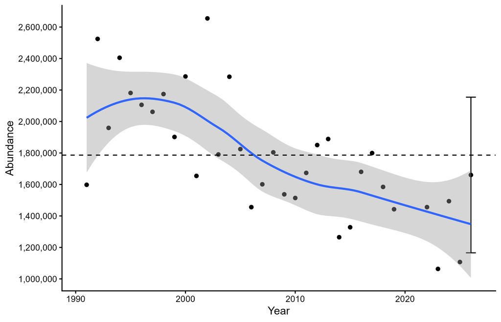

Figure 54: Total duck abundance in Mississippi Flyway States in spring. Circles are annual estimates of abundance with 95% confidence intervals. The blue line is a smoothed (Loess model) line with 95% confidence interval (shaded area) fit to the annual estimates. The black dashed reference line is the long term average.

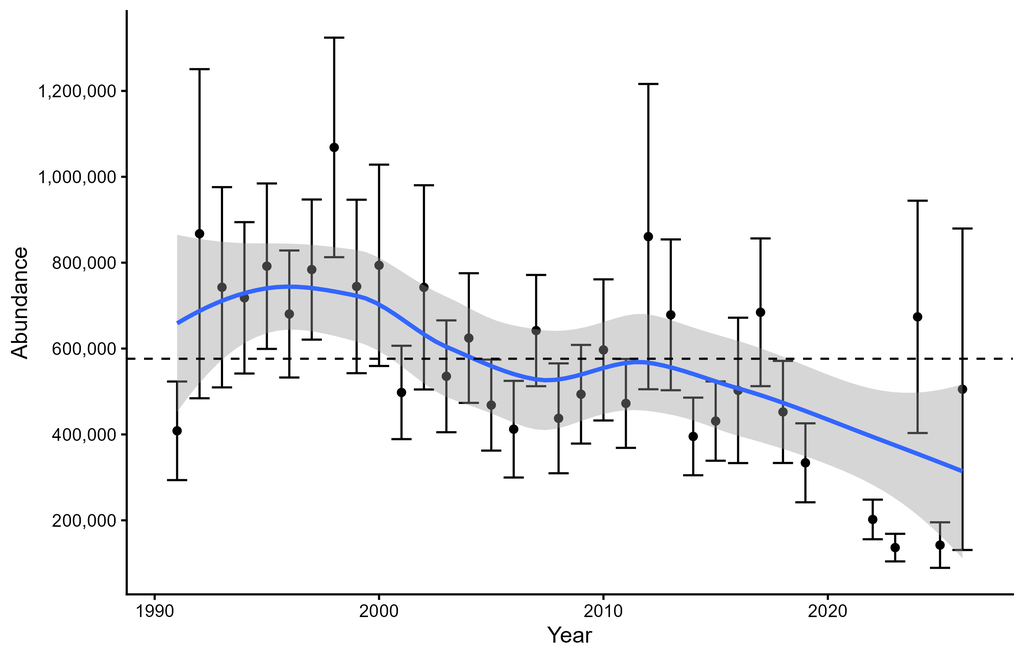

Figure 55: Total duck abundance in Michigan in spring. Circles are annual estimates of abundance with 95% confidence intervals. The blue line is a smoothed (Loess model) line with 95% confidence interval (shaded area) fit to the annual estimates. The black dashed reference line is the long term average.

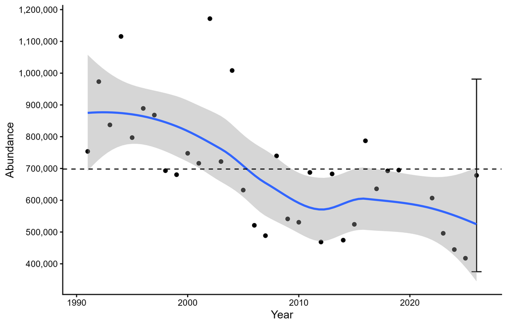

Figure 56: Total duck abundance in Minnesota in spring. Circles are annual estimates of abundance with 95% confidence intervals. The blue line is a smoothed (Loess model) line with 95% confidence interval (shaded area) fit to the annual estimates. The black dashed reference line is the long term average.

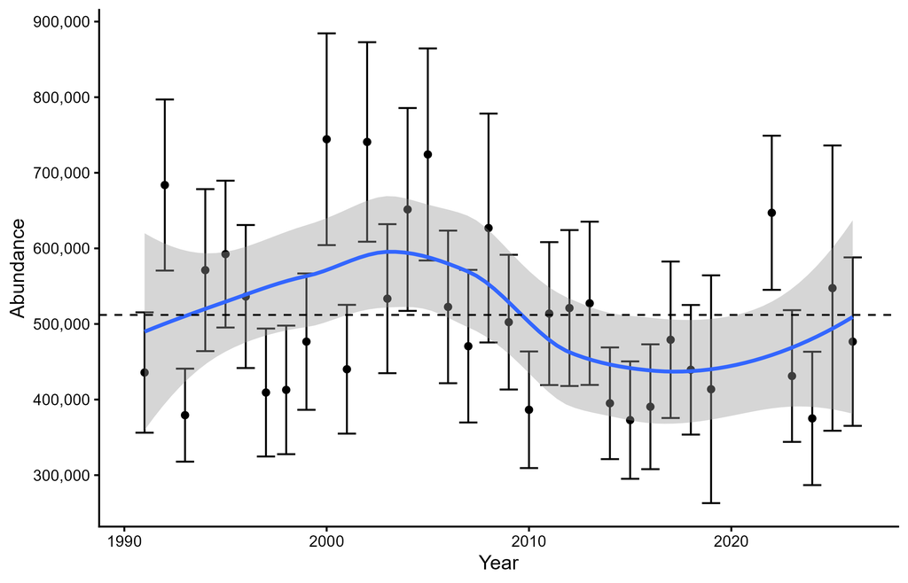

Figure 57: Total duck abundance in Wisconsin in spring. Circles are annual estimates of abundance with 95% confidence intervals. The blue line is a smoothed (Loess model) line with 95% confidence interval (shaded area) fit to the annual estimates. The black dashed reference line is the long term average.

### Data Table 70: Mallard State Surveys

Original data source: Breeding Waterfowl Surveys in Michigan, Minnesota, and Wisconsin. Data maintained by Michigan, Minnesota, and Wisconsin, and USFWS Mississippi Flyway Office.

Table 70. Mallard abundance in midcontinent States in spring, 1968-2026.

| Year | MI | MI.SE | MN | MN.SE | WI | WI.SE | Total | Total.SE |
| --- | --- | --- | --- | --- | --- | --- | --- | --- |
| 1968 | NA | NA | 83,701 | NA | NA | NA | NA | NA |
| 1969 | NA | NA | 88,789 | NA | NA | NA | NA | NA |
| 1970 | NA | NA | 113,945 | NA | NA | NA | NA | NA |
| 1971 | NA | NA | 78,470 | NA | NA | NA | NA | NA |
| 1972 | NA | NA | 62,158 | NA | NA | NA | NA | NA |
| 1973 | NA | NA | 99,832 | NA | 106,957 | 19,604 | NA | NA |
| 1974 | NA | NA | 72,826 | NA | 94,323 | 13,948 | NA | NA |
| 1975 | NA | NA | 175,774 | NA | 120,460 | 19,633 | NA | NA |
| 1976 | NA | NA | 117,806 | NA | 109,862 | 16,061 | NA | NA |
| 1977 | NA | NA | 134,164 | NA | 91,657 | 17,184 | NA | NA |
| 1978 | NA | NA | 146,781 | NA | 61,647 | 8,273 | NA | NA |
| 1979 | NA | NA | 158,704 | 28,668 | 78,600 | 10,666 | NA | NA |
| 1980 | NA | NA | 171,957 | 22,312 | 116,487 | 16,181 | NA | NA |
| 1981 | NA | NA | 154,844 | 16,402 | 142,831 | 18,776 | NA | NA |
| 1982 | NA | NA | 120,527 | 17,078 | 89,471 | 13,076 | NA | NA |
| 1983 | NA | NA | 155,762 | 15,419 | 119,462 | 18,236 | NA | NA |
| 1984 | NA | NA | 188,149 | 24,065 | 104,759 | 13,290 | NA | NA |
| 1985 | NA | NA | 216,908 | 32,935 | 73,909 | 10,190 | NA | NA |
| 1986 | NA | NA | 233,598 | 30,384 | 110,764 | 15,554 | NA | NA |
| 1987 | NA | NA | 192,289 | 23,500 | 136,947 | 17,874 | NA | NA |
| 1988 | NA | NA | 271,718 | 38,675 | 148,901 | 19,325 | NA | NA |
| 1989 | NA | NA | 272,968 | 26,508 | 180,676 | 22,792 | NA | NA |
| 1990 | NA | NA | 232,059 | 26,316 | 151,356 | 15,266 | NA | NA |
| 1991 | 289,332 | 53,356 | 224,953 | 28,832 | 172,423 | 18,677 | 686,708 | 63,458 |
| 1992 | 385,767 | 79,444 | 360,870 | 43,621 | 249,727 | 34,391 | 996,364 | 96,938 |
| 1993 | 437,215 | 52,120 | 305,838 | 31,103 | 174,531 | 21,424 | 917,584 | 64,365 |
| 1994 | 420,534 | 63,049 | 426,455 | 66,240 | 283,401 | 38,144 | 1,130,390 | 99,085 |
| 1995 | 524,070 | 84,722 | 319,433 | 48,124 | 242,166 | 24,760 | 1,085,669 | 100,532 |
| 1996 | 378,175 | 52,112 | 314,816 | 53,461 | 314,413 | 38,716 | 1,007,404 | 84,099 |
| 1997 | 489,350 | 63,554 | 407,413 | 65,771 | 180,967 | 25,250 | 1,077,730 | 94,882 |
| 1998 | 522,987 | 67,641 | 368,450 | 61,513 | 186,891 | 27,776 | 1,078,328 | 95,555 |
| 1999 | 466,095 | 82,084 | 316,394 | 51,651 | 248,446 | 32,391 | 1,030,935 | 102,248 |
| 2000 | 427,185 | 72,921 | 318,134 | 36,857 | 453,979 | 53,808 | 1,199,298 | 97,833 |
| 2001 | 324,204 | 38,946 | 320,560 | 39,541 | 183,452 | 24,040 | 828,216 | 60,483 |
| 2002 | 323,207 | 45,132 | 366,625 | 46,264 | 378,543 | 44,045 | 1,068,375 | 78,213 |
| 2003 | 298,881 | 31,682 | 280,517 | 34,556 | 261,332 | 30,988 | 840,730 | 56,197 |
| 2004 | 341,985 | 46,260 | 375,313 | 57,591 | 229,174 | 28,171 | 946,472 | 79,059 |
| 2005 | 258,101 | 31,143 | 238,500 | 28,595 | 317,224 | 42,967 | 813,825 | 60,280 |
| 2006 | 244,648 | 29,863 | 160,715 | 24,230 | 219,494 | 30,548 | 624,857 | 49,113 |
| 2007 | 337,723 | 43,707 | 242,481 | 30,020 | 210,219 | 30,343 | 790,423 | 61,092 |
| 2008 | 200,505 | 32,050 | 297,565 | 27,787 | 188,429 | 23,850 | 686,499 | 48,663 |
| 2009 | 258,869 | 33,003 | 236,436 | 36,539 | 200,497 | 27,251 | 695,802 | 56,275 |
| 2010 | 339,856 | 41,570 | 241,884 | 33,940 | 199,107 | 23,486 | 780,847 | 58,580 |
| 2011 | 259,444 | 33,186 | 283,329 | 49,845 | 187,862 | 23,068 | 730,635 | 64,171 |
| 2012 | 439,269 | 166,954 | 224,965 | 45,057 | 196,950 | 27,796 | 861,184 | 175,147 |
| 2013 | 289,357 | 40,644 | 293,239 | 58,463 | 181,200 | 21,663 | 763,796 | 74,425 |
| 2014 | 230,120 | 33,445 | 256,996 | 55,366 | 158,747 | 21,438 | 645,863 | 68,144 |
| 2015 | 237,753 | 25,972 | 206,229 | 37,498 | 176,200 | 23,589 | 620,182 | 51,353 |
| 2016 | 278,111 | 51,061 | 250,204 | 42,850 | 164,147 | 23,697 | 692,462 | 70,745 |
| 2017 | 298,120 | 33,793 | 213,644 | 32,704 | 180,930 | 22,927 | 692,694 | 52,318 |
| 2018 | 251,362 | 44,279 | 295,370 | 46,578 | 216,652 | 28,131 | 763,384 | 70,153 |
| 2019 | 179,171 | 19,379 | 286,357 | 35,570 | 204,296 | 54,461 | 669,824 | 67,873 |
| 2020 | NA | NA | NA | NA | NA | NA | NA | NA |
| 2021 | 309,993 | 58,313 | NA | NA | 147,373 | 2,402 | NA | NA |
| 2022 | 138,714 | 17,114 | 231,058 | 38,411 | 185,616 | 20,465 | 555,388 | 46,766 |
| 2023 | 82,731 | 9,628 | 222,185 | 49,387 | 166,651 | 21,555 | 471,567 | 54,739 |
| 2024 | 250,581 | 41,888 | 140,941 | 27,378 | 117,739 | 13,475 | 509,261 | 51,824 |
| 2025 | 87,967 | 22,102 | 163,517 | 31,925 | 149,142 | 24,767 | 400,626 | 46,056 |
| 2026 | 141,895 | 30,937 | 239,579 | 45,643 | 175,299 | 28,624 | 556,774 | 62,126 |

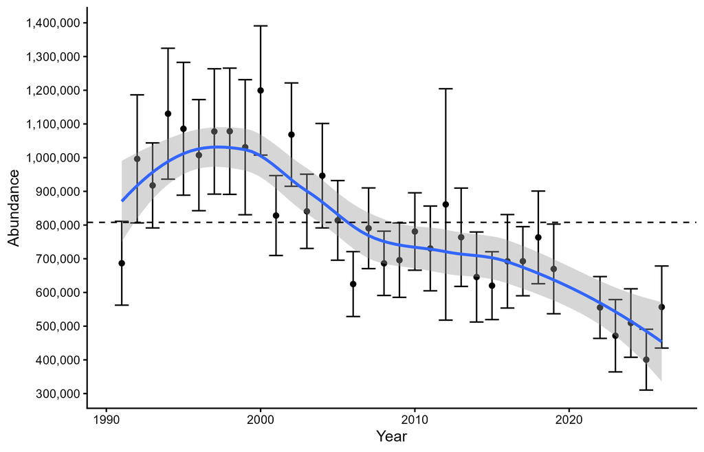

Figure 58: Mallard abundance in midcontinent States in spring. Circles are annual estimates of abundance with 95% confidence intervals. The blue line is a smoothed (Loess model) line with 95% confidence interval (shaded area) fit to the annual estimates. The black dashed reference line is the long term average.

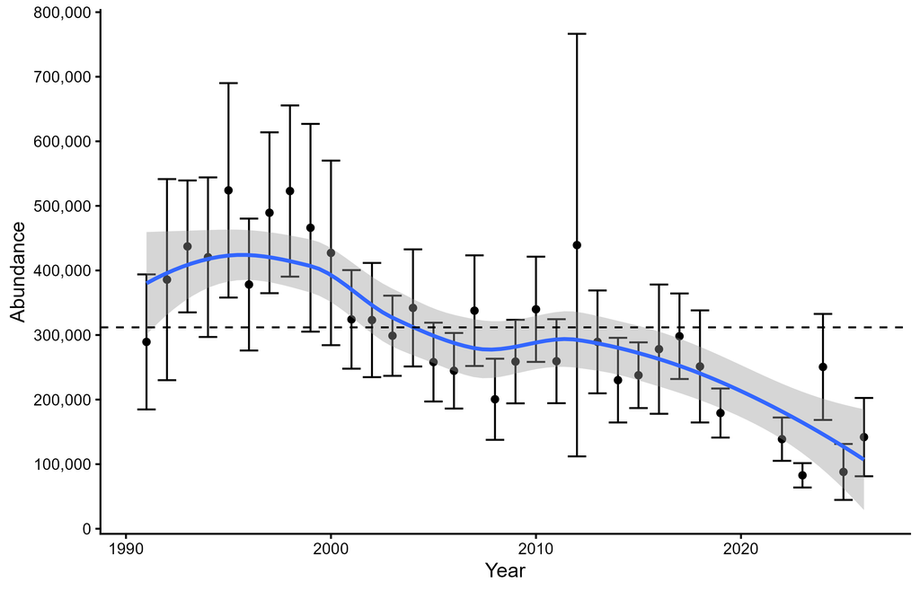

Figure 59: Mallard abundance in Michigan in spring. Circles are annual estimates of abundance with 95% confidence intervals. The blue line is a smoothed (Loess model) line with 95% confidence interval (shaded area) fit to the annual estimates. The black dashed reference line is the long term average.

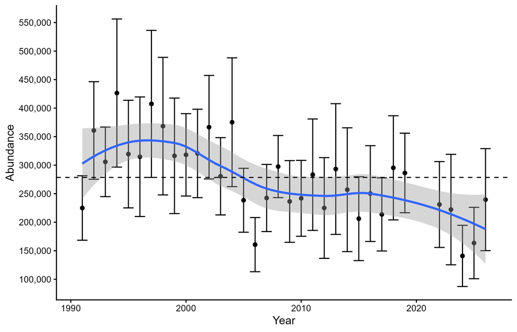

Figure 60: Mallard abundance in Minnesota in spring. Circles are annual estimates of abundance with 95% confidence intervals. The blue line is a smoothed (Loess model) line with 95% confidence interval (shaded area) fit to the annual estimates. The black dashed reference line is the long term average.

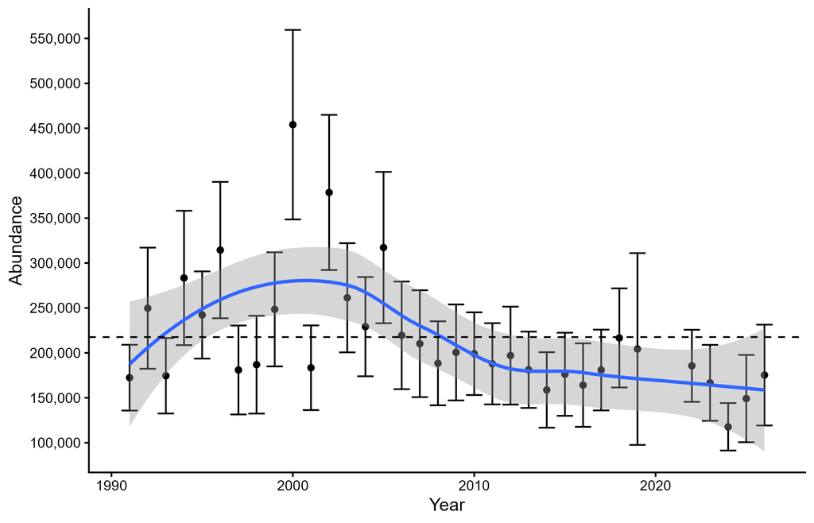

Figure 61: Mallard abundance in Wisconsin in spring. Circles are annual estimates of abundance with 95% confidence intervals. The blue line is a smoothed (Loess model) line with 95% confidence interval (shaded area) fit to the annual estimates. The black dashed reference line is the long term average.

### Data Table 71: Ponds

Original data source: WBPHS Traditional Survey Area; USFWS Headquarters.

Provided in the table below are estimated pond abundance and standard error (SE) in May in Prairie and Parkland Canada (Can), northcentral United States (US), and both areas combined (Total). Estimates are corrected for Visibility bias.

Prairie and Parkland Canada includes the following WBPHS crew areas:  
Area 4 = Southern Alberta (strata 26–29, 75–76)  
Area 5 = Southern Saskatchewan (strata 30–33)  
Area 6 = Southern Manitoba (strata 34–40; includes south east Saskatchewan)

Northcentral U.S. includes the following WBPHS crew areas:  
Area 7 = Montana and western Dakotas (strata 41–44)  
Area 8 = Eastern Dakotas (strata 45–49)

Table 71. Number of Ponds in May, 1961-2026.

| Year | Area4 | Area5 | Area6 | Area7 | Area8 | Can | Can.SE | US | US.SE | Total | Total.SE |
| --- | --- | --- | --- | --- | --- | --- | --- | --- | --- | --- | --- |
| 1961 | 595,735 | 794,850 | 586,607 | NA | NA | 1,977,192 | 165,394 | NA | NA | NA | NA |
| 1962 | 606,153 | 1,229,341 | 533,595 | NA | NA | 2,369,089 | 184,593 | NA | NA | NA | NA |
| 1963 | 777,617 | 1,024,486 | 679,923 | NA | NA | 2,482,026 | 129,302 | NA | NA | NA | NA |
| 1964 | 644,452 | 1,817,184 | 909,081 | NA | NA | 3,370,717 | 173,006 | NA | NA | NA | NA |
| 1965 | 998,829 | 2,257,381 | 1,122,604 | NA | NA | 4,378,814 | 212,224 | NA | NA | NA | NA |
| 1966 | 863,904 | 2,624,331 | 1,066,280 | NA | NA | 4,554,515 | 229,284 | NA | NA | NA | NA |
| 1967 | 919,063 | 2,652,165 | 1,119,958 | NA | NA | 4,691,186 | 272,063 | NA | NA | NA | NA |
| 1968 | 437,956 | 1,212,458 | 335,265 | NA | NA | 1,985,679 | 120,210 | NA | NA | NA | NA |
| 1969 | 859,496 | 2,225,018 | 463,097 | NA | NA | 3,547,611 | 221,944 | NA | NA | NA | NA |
| 1970 | 882,711 | 2,957,098 | 1,035,230 | NA | NA | 4,875,039 | 251,183 | NA | NA | NA | NA |
| 1971 | 981,446 | 2,317,386 | 754,575 | NA | NA | 4,053,407 | 200,405 | NA | NA | NA | NA |
| 1972 | 731,130 | 2,264,389 | 1,013,724 | NA | NA | 4,009,243 | 250,904 | NA | NA | NA | NA |
| 1973 | 1,025,160 | 1,490,442 | 433,884 | NA | NA | 2,949,486 | 197,610 | NA | NA | NA | NA |
| 1974 | 1,394,626 | 3,546,330 | 1,449,142 | 341,979 | 1,498,809 | 6,390,098 | 308,345 | 1,840,788 | 197,168 | 8,230,886 | 365,994 |
| 1975 | 957,871 | 3,424,684 | 937,555 | 535,406 | 1,375,429 | 5,320,110 | 271,323 | 1,910,835 | 116,139 | 7,230,945 | 295,135 |
| 1976 | 831,596 | 2,578,541 | 1,188,661 | 412,377 | 979,161 | 4,598,798 | 197,107 | 1,391,538 | 99,248 | 5,990,336 | 220,684 |
| 1977 | 588,008 | 1,250,019 | 439,891 | 331,424 | 439,713 | 2,277,918 | 120,742 | 771,137 | 51,135 | 3,049,055 | 131,124 |
| 1978 | 619,872 | 2,221,846 | 780,337 | 637,878 | 952,514 | 3,622,055 | 157,964 | 1,590,392 | 81,729 | 5,212,447 | 177,854 |
| 1979 | 996,447 | 3,070,063 | 792,431 | 410,145 | 1,112,041 | 4,858,941 | 251,992 | 1,522,186 | 70,883 | 6,381,127 | 261,771 |
| 1980 | 460,572 | 1,393,629 | 286,703 | 284,474 | 476,885 | 2,140,904 | 107,664 | 761,359 | 35,840 | 2,902,263 | 113,473 |
| 1981 | 569,299 | 610,958 | 262,760 | 310,841 | 371,970 | 1,443,017 | 75,261 | 682,811 | 34,042 | 2,125,828 | 82,602 |
| 1982 | 631,097 | 2,194,731 | 359,036 | 562,051 | 895,907 | 3,184,864 | 178,613 | 1,457,958 | 86,409 | 4,642,822 | 198,416 |
| 1983 | 497,116 | 2,696,237 | 712,356 | 358,133 | 901,017 | 3,905,709 | 208,176 | 1,259,150 | 68,686 | 5,164,859 | 219,214 |
| 1984 | 537,896 | 1,525,766 | 409,405 | 462,872 | 1,303,330 | 2,473,067 | 196,553 | 1,766,202 | 90,759 | 4,239,269 | 216,496 |
| 1985 | 828,270 | 2,958,533 | 496,284 | 519,030 | 807,899 | 4,283,087 | 244,149 | 1,326,929 | 73,980 | 5,610,016 | 255,112 |
| 1986 | 727,517 | 2,349,649 | 947,507 | 733,419 | 1,001,405 | 4,024,673 | 174,414 | 1,734,824 | 74,363 | 5,759,497 | 189,605 |
| 1987 | 606,766 | 1,418,910 | 498,070 | 558,693 | 789,058 | 2,523,746 | 130,967 | 1,347,751 | 46,824 | 3,871,497 | 139,086 |
| 1988 | 417,876 | 1,059,801 | 632,471 | 357,511 | 433,147 | 2,110,148 | 132,387 | 790,658 | 39,404 | 2,900,806 | 138,127 |
| 1989 | 548,860 | 859,726 | 284,159 | 649,596 | 640,311 | 1,692,745 | 89,105 | 1,289,907 | 61,713 | 2,982,652 | 108,389 |
| 1990 | 772,135 | 1,382,776 | 662,381 | 442,754 | 248,443 | 2,817,292 | 138,274 | 691,197 | 45,944 | 3,508,489 | 145,707 |
| 1991 | 695,737 | 1,405,066 | 393,099 | 420,580 | 285,497 | 2,493,902 | 110,220 | 706,077 | 33,568 | 3,199,979 | 115,219 |
| 1992 | 503,220 | 1,615,926 | 664,768 | 462,561 | 362,402 | 2,783,915 | 141,637 | 824,963 | 30,813 | 3,608,877 | 144,950 |
| 1993 | 689,837 | 1,087,891 | 483,409 | 442,328 | 908,260 | 2,261,137 | 93,965 | 1,350,587 | 57,140 | 3,611,725 | 109,974 |
| 1994 | 720,376 | 2,653,118 | 395,653 | 962,833 | 1,252,789 | 3,769,148 | 173,940 | 2,215,621 | 88,816 | 5,984,769 | 195,304 |
| 1995 | 688,738 | 2,314,362 | 889,438 | 825,170 | 1,617,685 | 3,892,538 | 223,833 | 2,442,856 | 106,805 | 6,335,394 | 248,009 |
| 1996 | 903,866 | 3,268,868 | 829,829 | 902,388 | 1,577,293 | 5,002,562 | 184,856 | 2,479,681 | 135,268 | 7,482,243 | 229,061 |
| 1997 | 1,100,439 | 2,992,048 | 968,497 | 756,365 | 1,640,868 | 5,060,983 | 180,267 | 2,397,232 | 94,391 | 7,458,216 | 203,485 |
| 1998 | 559,344 | 1,470,224 | 492,107 | 680,035 | 1,385,219 | 2,521,674 | 133,818 | 2,065,254 | 89,212 | 4,586,928 | 160,829 |
| 1999 | 716,010 | 2,535,347 | 610,678 | 672,298 | 2,169,952 | 3,862,035 | 157,247 | 2,842,249 | 256,836 | 6,704,284 | 301,150 |
| 2000 | 553,127 | 1,403,711 | 465,656 | 428,971 | 1,095,479 | 2,422,494 | 96,068 | 1,524,450 | 99,895 | 3,946,944 | 138,593 |
| 2001 | 425,702 | 1,535,743 | 785,762 | 345,567 | 1,547,672 | 2,747,206 | 115,565 | 1,893,238 | 91,481 | 4,640,444 | 147,391 |
| 2002 | 476,860 | 634,919 | 327,196 | 347,072 | 933,977 | 1,438,975 | 104,989 | 1,281,050 | 63,425 | 2,720,025 | 122,659 |
| 2003 | 888,399 | 2,142,973 | 490,916 | 479,755 | 1,188,051 | 3,522,288 | 151,843 | 1,667,807 | 67,364 | 5,190,095 | 166,115 |
| 2004 | 510,705 | 1,461,334 | 540,569 | 597,396 | 809,592 | 2,512,608 | 130,985 | 1,406,989 | 101,715 | 3,919,596 | 165,840 |
| 2005 | 750,374 | 2,414,928 | 755,244 | 662,946 | 797,755 | 3,920,546 | 196,676 | 1,460,701 | 79,653 | 5,381,247 | 212,193 |
| 2006 | 995,829 | 2,718,951 | 734,763 | 614,710 | 1,029,680 | 4,449,543 | 221,455 | 1,644,390 | 85,449 | 6,093,933 | 237,369 |
| 2007 | 1,225,351 | 3,000,302 | 814,567 | 739,686 | 1,222,829 | 5,040,220 | 261,822 | 1,962,514 | 102,519 | 7,002,734 | 281,178 |
| 2008 | 848,745 | 1,608,348 | 597,691 | 531,398 | 845,197 | 3,054,784 | 147,649 | 1,376,595 | 71,893 | 4,431,379 | 164,222 |
| 2009 | 686,677 | 2,210,464 | 670,920 | 1,033,805 | 1,832,145 | 3,568,062 | 147,983 | 2,865,950 | 123,065 | 6,434,012 | 192,468 |
| 2010 | 678,361 | 2,668,056 | 382,276 | 594,917 | 2,341,424 | 3,728,693 | 203,354 | 2,936,342 | 142,264 | 6,665,035 | 248,177 |
| 2011 | 1,085,607 | 3,150,948 | 656,176 | 968,592 | 2,270,905 | 4,892,732 | 197,506 | 3,239,497 | 127,365 | 8,132,229 | 235,012 |
| 2012 | 806,528 | 2,677,563 | 401,020 | 427,756 | 1,231,101 | 3,885,110 | 146,454 | 1,658,858 | 52,660 | 5,543,968 | 155,634 |
| 2013 | 1,126,500 | 2,845,885 | 578,143 | 382,748 | 1,958,427 | 4,550,528 | 185,462 | 2,341,175 | 98,995 | 6,891,703 | 210,229 |
| 2014 | 1,218,436 | 2,743,585 | 667,868 | 965,631 | 1,585,672 | 4,629,889 | 168,291 | 2,551,303 | 106,538 | 7,181,192 | 199,178 |
| 2015 | 1,022,570 | 2,571,492 | 556,913 | 909,848 | 1,246,903 | 4,150,975 | 146,270 | 2,156,751 | 86,006 | 6,307,726 | 169,682 |
| 2016 | 757,633 | 2,087,656 | 649,173 | 672,255 | 845,741 | 3,494,462 | 147,237 | 1,517,995 | 52,727 | 5,012,457 | 156,394 |
| 2017 | 1,168,355 | 2,449,060 | 712,842 | 560,933 | 1,204,797 | 4,330,258 | 157,707 | 1,765,730 | 92,231 | 6,095,988 | 182,696 |
| 2018 | 1,178,976 | 1,935,672 | 545,502 | 752,955 | 814,285 | 3,660,150 | 147,618 | 1,567,240 | 90,205 | 5,227,390 | 172,998 |
| 2019 | 947,478 | 1,372,392 | 535,704 | 1,098,601 | 1,036,127 | 2,855,575 | 103,804 | 2,134,727 | 137,282 | 4,990,303 | 172,109 |
| 2020 | NA | NA | NA | NA | NA | NA | NA | NA | NA | NA | NA |
| 2021 | NA | NA | NA | NA | NA | NA | NA | NA | NA | NA | NA |
| 2022 | 711,490 | 2,035,248 | 726,760 | 549,422 | 1,433,968 | 3,473,498 | 157,523 | 1,983,390 | 98,159 | 5,456,888 | 185,603 |
| 2023 | 642,399 | 2,117,119 | 554,074 | 602,228 | 1,059,265 | 3,313,593 | 114,179 | 1,661,493 | 75,215 | 4,975,086 | 136,727 |
| 2024 | 676,851 | 1,454,054 | 550,343 | 655,301 | 1,822,942 | 2,681,247 | 117,417 | 2,478,242 | 125,510 | 5,159,490 | 171,871 |
| 2025 | 579,959 | 1,507,511 | 464,842 | 540,157 | 1,088,004 | 2,552,312 | 125,333 | 1,628,161 | 75,947 | 4,180,473 | 146,548 |
| 2026 | 716,104 | 1,905,902 | 671,169 | 416,184 | 1,052,140 | 3,293,175 | 175,511 | 1,468,325 | 109,566 | 4,761,500 | 206,903 |

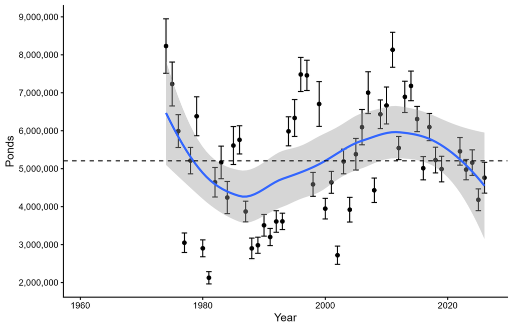

Figure 62: Number of ponds in May in Prairie and Parkland Canada and northcentral U.S. Circles are annual estimates of abundance with 95% confidence intervals. The blue line is a smoothed (Loess model) line with 95% confidence interval (shaded area) fit to the annual estimates. The black dashed reference line is the long term average.

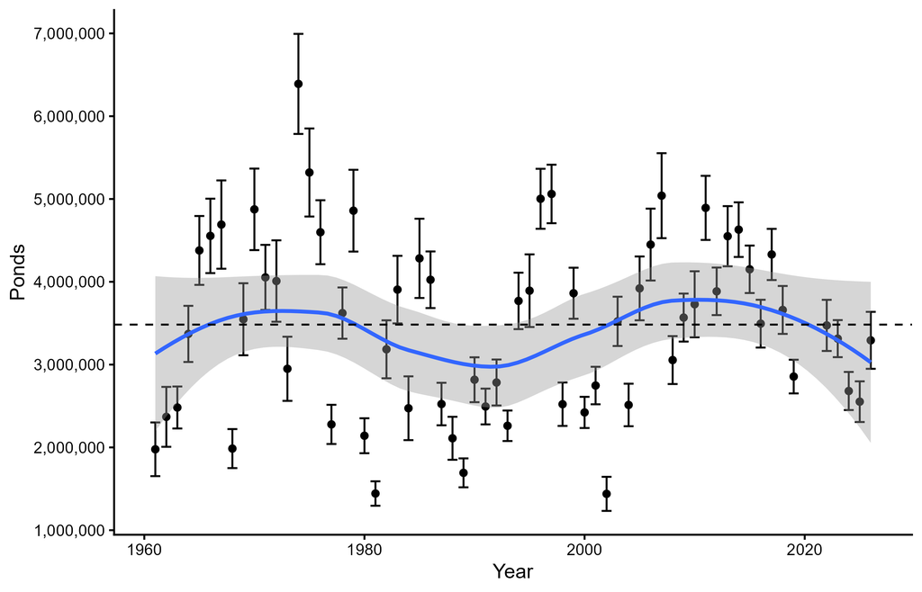

Figure 63: Number of ponds in May in Prairie and Parkland Canada. Circles are annual estimates of abundance with 95% confidence intervals. The blue line is a smoothed (Loess model) line with 95% confidence interval (shaded area) fit to the annual estimates. The black dashed reference line is the long term average.

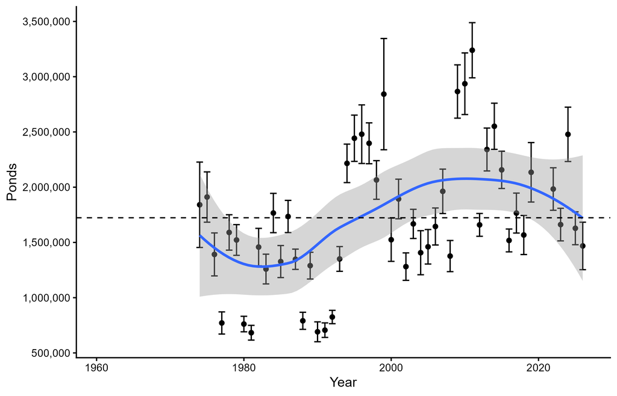

Figure 64: Number of ponds in May in northcentral U.S. Circles are annual estimates of abundance with 95% confidence intervals. The blue line is a smoothed (Loess model) line with 95% confidence interval (shaded area) fit to the annual estimates. The black dashed reference line is the long term average.

## BBS Trends

### Data Table 75: Webless Species Spring

Original data source: North American Breeding Bird Survey; U.S. Geological Survey. Data maintained by U.S. Geological Survey.

Provided in the table below are the estimated abundance trend (mean annual percentage change in abundance from the beginning to end for a specific year interval) and lower and upper 95% credible intervals (L95%CI, U95%CI) for webless species (AOU species code and common name) in spring from the North American Breeding Bird Survey (Core area). Estimates are by region and time-series interval (Interval) from first (First) to last year (Last) of the time series.

Table 75. Webless species trends in abundance in spring, 1966-2025.

| AOU | Species | Region | Routes | Trend | L95%CI | U95%CI | Interval | First | Last |
| --- | --- | --- | --- | --- | --- | --- | --- | --- | --- |
| 2210 | American Coot | US | 193 | -5.333 | -14.710 | 5.327 | 4 | 2021 | 2025 |
| 2210 | American Coot | US | 311 | -2.232 | -6.088 | 2.355 | 9 | 2016 | 2025 |
| 2210 | American Coot | US | 811 | -2.130 | -4.362 | -0.778 | 59 | 1966 | 2025 |
| 2110 | Clapper Rail | US | 22 | 0.555 | -7.575 | 11.023 | 4 | 2021 | 2025 |
| 2110 | Clapper Rail | US | 33 | 1.665 | -2.887 | 8.452 | 9 | 2016 | 2025 |
| 2110 | Clapper Rail | US | 73 | -0.497 | -2.033 | 0.833 | 59 | 1966 | 2025 |
| 2190 | Common Gallinule | US | 65 | 3.846 | -7.524 | 17.844 | 4 | 2021 | 2025 |
| 2190 | Common Gallinule | US | 87 | 1.238 | -4.580 | 8.694 | 9 | 2016 | 2025 |
| 2190 | Common Gallinule | US | 233 | 0.221 | -1.107 | 1.723 | 59 | 1966 | 2025 |
| 2080 | King Rail | US | 14 | -5.476 | -22.625 | 13.856 | 4 | 2021 | 2025 |
| 2080 | King Rail | US | 18 | -3.185 | -12.881 | 7.930 | 9 | 2016 | 2025 |
| 2080 | King Rail | US | 75 | -3.284 | -5.439 | -1.277 | 59 | 1966 | 2025 |
| 3160 | Mourning Dove | CMU | 1,087 | 0.128 | -0.325 | 0.594 | 9 | 2016 | 2025 |
| 3160 | Mourning Dove | CMU | 1,287 | -0.289 | -0.671 | -0.150 | 58 | 1967 | 2025 |
| 3160 | Mourning Dove | DEMD | 64 | 1.723 | 0.700 | 2.810 | 9 | 2016 | 2025 |
| 3160 | Mourning Dove | DEMD | 90 | 0.437 | 0.202 | 0.684 | 59 | 1966 | 2025 |
| 3160 | Mourning Dove | EMU | 1,422 | -0.601 | -0.934 | -0.272 | 9 | 2016 | 2025 |
| 3160 | Mourning Dove | EMU | 1,827 | 0.164 | 0.067 | 0.258 | 59 | 1966 | 2025 |
| 3160 | Mourning Dove | EMUhunt | 1,115 | -0.619 | -0.988 | -0.254 | 9 | 2016 | 2025 |
| 3160 | Mourning Dove | EMUhunt | 1,397 | 0.090 | -0.012 | 0.191 | 59 | 1966 | 2025 |
| 3160 | Mourning Dove | EMUnon | 307 | -0.466 | -1.223 | 0.289 | 9 | 2016 | 2025 |
| 3160 | Mourning Dove | EMUnon | 430 | 0.847 | 0.626 | 1.063 | 59 | 1966 | 2025 |
| 3160 | Mourning Dove | NewEng | 127 | -1.754 | -2.881 | -0.601 | 9 | 2016 | 2025 |
| 3160 | Mourning Dove | NewEng | 169 | 1.498 | 1.158 | 1.852 | 59 | 1966 | 2025 |
| 3160 | Mourning Dove | US | 3,063 | -0.006 | -0.318 | 0.314 | 9 | 2016 | 2025 |
| 3160 | Mourning Dove | US | 3,860 | -0.277 | -0.563 | -0.152 | 59 | 1966 | 2025 |
| 3160 | Mourning Dove | WMU | 554 | 0.947 | -0.093 | 2.013 | 9 | 2016 | 2025 |
| 3160 | Mourning Dove | WMU | 746 | -0.966 | -1.292 | -0.673 | 57 | 1968 | 2025 |
| 2180 | Purple Gallinule | US | 13 | 3.399 | -10.990 | 23.499 | 4 | 2021 | 2025 |
| 2180 | Purple Gallinule | US | 16 | 5.894 | -1.824 | 18.569 | 9 | 2016 | 2025 |
| 2180 | Purple Gallinule | US | 57 | 0.012 | -2.084 | 2.283 | 59 | 1966 | 2025 |
| 2140 | Sora | US | 223 | 11.217 | 2.766 | 20.416 | 4 | 2021 | 2025 |
| 2140 | Sora | US | 334 | 2.937 | -0.502 | 6.678 | 9 | 2016 | 2025 |
| 2140 | Sora | US | 646 | 0.406 | -1.658 | 1.496 | 59 | 1966 | 2025 |
| 2120 | Virginia Rail | US | 66 | 4.416 | -2.773 | 14.460 | 4 | 2021 | 2025 |
| 2120 | Virginia Rail | US | 100 | -0.028 | -3.824 | 4.493 | 9 | 2016 | 2025 |
| 2120 | Virginia Rail | US | 323 | 0.171 | -1.298 | 1.051 | 59 | 1966 | 2025 |
| 3190 | White-winged Dove | US | 254 | 1.713 | -1.738 | 5.702 | 4 | 2021 | 2025 |
| 3190 | White-winged Dove | US | 307 | 1.166 | -0.649 | 3.521 | 9 | 2016 | 2025 |
| 3190 | White-winged Dove | US | 420 | 0.613 | -0.185 | 1.464 | 59 | 1966 | 2025 |
| 2300 | Wilson's Snipe | US | 466 | -1.679 | -4.480 | 1.266 | 4 | 2021 | 2025 |
| 2300 | Wilson's Snipe | US | 595 | -2.171 | -3.570 | -0.822 | 9 | 2016 | 2025 |
| 2300 | Wilson's Snipe | US | 1,083 | -0.037 | -0.460 | 0.371 | 59 | 1966 | 2025 |

## Abundance (Ancillary Data)

### Data Table 80: Snow Goose, WAP

Original data source: Arctic coastal Plain Survey and Waterfowl Breeding Population and Habitat Survey (WBPHS) strata in Alaska (i.e., strata 3–6, 10 and 11); USFWS Alaska Region. Data maintained by the USFWS Alaska Region.

Provided in the table below are estimated total (Total) and breeding (Breeding) bird abundance and standard error (SE) of Western Arctic Population lesser snow geese in Spring. Also provided are the total abundance moving 3-year average (M3yr) and standard error (M3yr.SE).

Table 80. Western Arctic Population lesser snow goose abundance in spring, 2007-2026.

| Year | Total | Total.SE | M3yr | M3yr.SE | Breeding | Breeding.SE |
| --- | --- | --- | --- | --- | --- | --- |
| 2007 | 63,398 | 42,695 | NA | NA | 4,777 | 3,791 |
| 2008 | 8,272 | 3,603 | NA | NA | 1,720 | 913 |
| 2009 | 27,078 | 13,228 | 32,916 | 25,890 | 9,231 | 4,200 |
| 2010 | 7,888 | 3,320 | 14,413 | 8,144 | 641 | 157 |
| 2011 | 23,388 | 11,291 | 19,451 | 10,222 | 14,272 | 6,417 |
| 2012 | 34,553 | 15,542 | 21,943 | 11,256 | 2,195 | 700 |
| 2013 | 39,402 | 15,159 | 32,448 | 14,128 | 2,712 | 1,492 |
| 2014 | 22,911 | 10,498 | 32,289 | 13,923 | 328 | 137 |
| 2015 | 55,061 | 30,188 | 39,125 | 20,423 | 814 | 231 |
| 2016 | 22,675 | 5,586 | 33,549 | 18,732 | 6,299 | 2,103 |
| 2017 | 52,434 | 16,123 | 43,390 | 20,020 | 6,012 | 2,160 |
| 2018 | 35,174 | 25,293 | 36,761 | 17,615 | 23,989 | 19,634 |
| 2019 | 60,717 | 23,686 | 49,441 | 22,066 | 47,090 | 17,923 |
| 2020 | NA | NA | NA | NA | NA | NA |
| 2021 | NA | NA | NA | NA | NA | NA |
| 2022 | 73,822 | 21,341 | 56,571 | 23,496 | 32,589 | 13,753 |
| 2023 | 68,955 | 28,451 | 67,831 | 24,671 | 53,799 | 22,238 |
| 2024 | 73,299 | 22,834 | 72,025 | 24,401 | 27,630 | 12,452 |
| 2025 | 171,831 | 56,444 | 104,695 | 38,802 | 41,994 | 25,350 |
| 2026 | 55,492 | 22,485 | 100,207 | 37,474 | 12,323 | 5,034 |

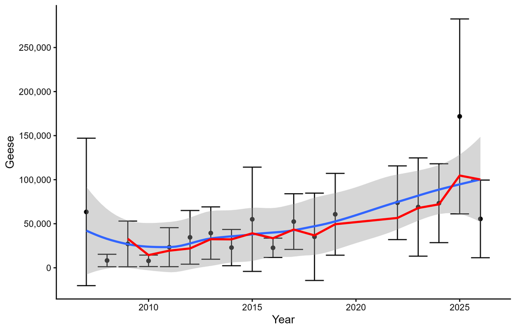

Figure 65: Western Arctic Population lesser snow goose abundance in spring. Circles are annual estimates of abundance with 95% confidence intervals. The red line is a moving 3-year average and the blue line is a smoothed (Loess model) line with 95% confidence interval (shaded area) fit to the annual estimates.

### Data Table 81: White-fronted Goose, MP

Original data source: Arctic coastal Plain Survey and Waterfowl Breeding Population and Habitat Survey (WBPHS) strata in Alaska (i.e., strata 3–6, 10 and 11); USFWS Alaska Region. Data maintained by the USFWS Alaska Region.

Provided in the table below are estimated total (Total) and breeding (Breeding) bird abundance and standard error (SE) of Midcontinent Population white-fronted geese in Spring. Also provided are the total abundance moving 3-year average (M3yr) and standard error (M3yr.SE).

Table 81. Midcontinent Population white-fronted goose abundance in spring, 2007-2026.

| Year | Total | Total.SE | M3yr | M3yr.SE | Breeding | Breeding.SE |
| --- | --- | --- | --- | --- | --- | --- |
| 2007 | 256,573 | 14,881 | NA | NA | 109,562 | 6,826 |
| 2008 | 255,499 | 23,426 | NA | NA | 136,810 | 6,591 |
| 2009 | 241,086 | 13,936 | 251,053 | 17,930 | 138,148 | 8,311 |
| 2010 | 259,213 | 13,145 | 251,932 | 17,472 | 95,928 | 4,575 |
| 2011 | 318,569 | 78,608 | 272,956 | 46,713 | 147,766 | 6,561 |
| 2012 | 360,884 | 15,439 | 312,889 | 46,870 | 190,753 | 7,327 |
| 2013 | NA | NA | NA | NA | NA | NA |
| 2014 | 165,130 | 8,553 | 281,528 | 46,514 | 110,564 | 4,336 |
| 2015 | 296,160 | 24,933 | 274,058 | 17,637 | 111,022 | 6,478 |
| 2016 | 395,085 | 25,795 | 285,459 | 21,293 | 153,969 | 9,973 |
| 2017 | 401,743 | 26,746 | 364,330 | 25,836 | 222,331 | 12,663 |
| 2018 | 275,226 | 16,893 | 357,352 | 23,566 | 202,851 | 12,312 |
| 2019 | 202,388 | 11,916 | 293,119 | 19,517 | 128,476 | 7,178 |
| 2020 | NA | NA | NA | NA | NA | NA |
| 2021 | NA | NA | NA | NA | NA | NA |
| 2022 | 247,585 | 12,633 | 241,733 | 13,988 | 160,565 | 8,624 |
| 2023 | 178,204 | 11,256 | 209,392 | 11,948 | 118,715 | 7,590 |
| 2024 | 235,866 | 15,143 | 220,552 | 13,110 | 166,953 | 10,000 |
| 2025 | 334,575 | 32,114 | 249,548 | 21,504 | 186,545 | 10,622 |
| 2026 | 264,112 | 30,917 | 278,185 | 27,181 | 147,522 | 8,092 |

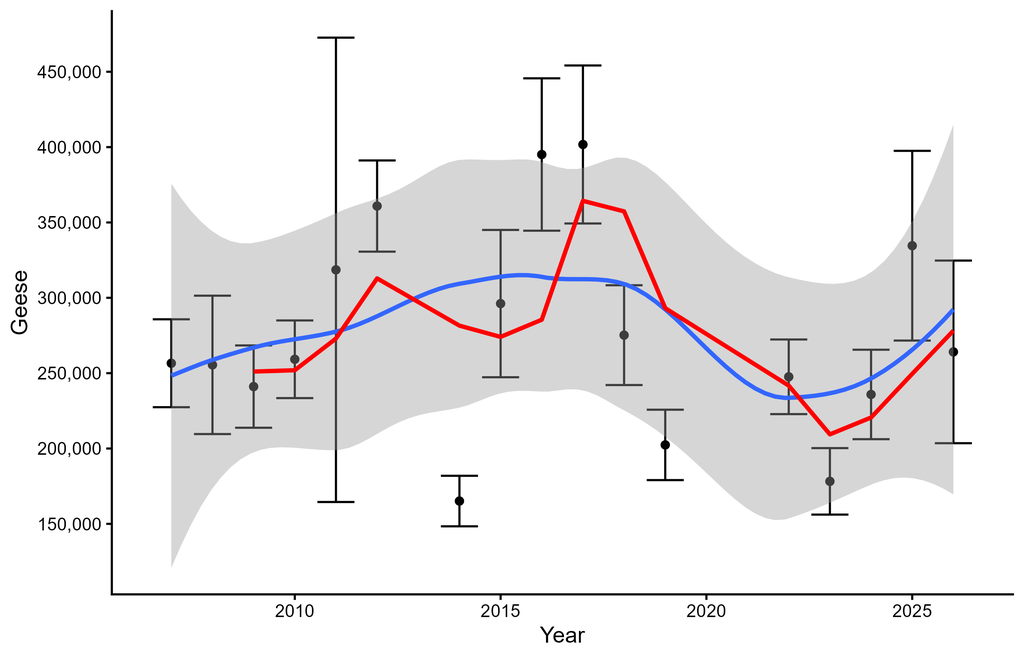

Figure 66: Midcontinent Population white-fronted goose abundance in spring. Circles are annual estimates of abundance with 95% confidence intervals. The red line is a moving 3-year average and the blue line is a smoothed (Loess model) line with 95% confidence interval (shaded area) fit to the annual estimates.

### Data Table 82: Tundra Swan, EP

Original data source: Arctic coastal Plain Survey; USFWS Alaska Region. Data maintained by the USFWS Alaska Region.

Provided in the table below are estimated total (Total) and breeding (Breeding) bird abundance and standard error (SE) of Eastern Population tundra swans in Spring. Also provided are the total abundance moving 3-year average (M3yr) and standard error (M3yr.SE).

Table 82. Eastern Population tundra swan abundance in spring, 2007-2026.

| Year | Total | Total.SE | M3yr | M3yr.SE | Breeding | Breeding.SE |
| --- | --- | --- | --- | --- | --- | --- |
| 2007 | 13,985 | 611 | NA | NA | 12,995 | 622 |
| 2008 | 15,281 | 1,286 | NA | NA | 12,537 | 717 |
| 2009 | 13,986 | 733 | 14,417 | 924 | 12,750 | 603 |
| 2010 | 15,282 | 1,091 | 14,850 | 1,061 | 13,420 | 843 |
| 2011 | 13,771 | 820 | 14,346 | 894 | 12,903 | 714 |
| 2012 | 16,329 | 1,726 | 15,128 | 1,270 | 13,836 | 641 |
| 2013 | 15,449 | 1,135 | 15,183 | 1,283 | 10,049 | 667 |
| 2014 | 13,065 | 745 | 14,948 | 1,268 | 7,275 | 499 |
| 2015 | 21,308 | 3,228 | 16,607 | 2,022 | 10,088 | 996 |
| 2016 | 15,699 | 1,116 | 16,691 | 2,019 | 14,404 | 832 |
| 2017 | 15,369 | 1,089 | 17,459 | 2,070 | 11,305 | 657 |
| 2018 | 14,573 | 1,154 | 15,214 | 1,120 | 14,573 | 1,154 |
| 2019 | 14,588 | 1,308 | 14,843 | 1,187 | 12,958 | 829 |
| 2020 | NA | NA | NA | NA | NA | NA |
| 2021 | NA | NA | NA | NA | NA | NA |
| 2022 | 11,975 | 727 | 13,712 | 1,091 | 11,129 | 640 |
| 2023 | 15,634 | 2,042 | 14,066 | 1,461 | 11,487 | 830 |
| 2024 | 11,033 | 996 | 12,881 | 1,377 | 9,536 | 509 |
| 2025 | 12,865 | 922 | 13,177 | 1,415 | 12,428 | 803 |
| 2026 | 11,261 | 882 | 11,719 | 934 | 11,261 | 882 |

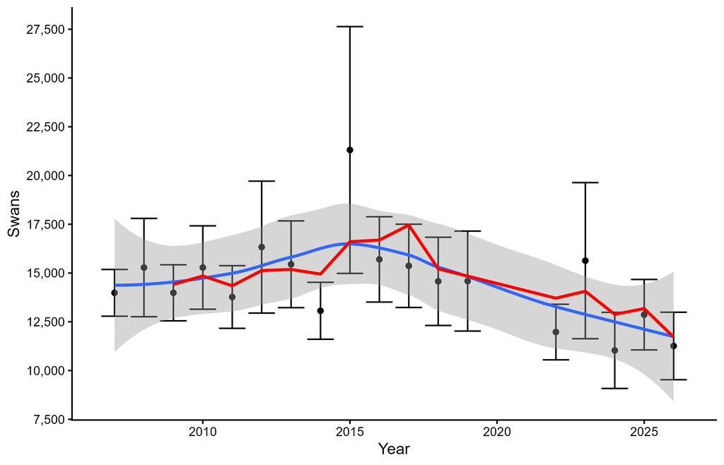

Figure 67: Eastern Population tundra swan abundance in spring. Circles are annual estimates of abundance with 95% confidence intervals. The red line is a moving 3-year average and the blue line is a smoothed (Loess model) line with 95% confidence interval (shaded area) fit to the annual estimates.

### Data Table 83: Trumpeter Swan, IP

Original data source: State breeding waterfowl and swan surveys. Data maintained by the Wisconsin Department of Natural Resources.

Provided in the table below are abundance of Interior Population trumpeter swans in spring by state (Iowa, Illinois, Michigan, Minnesota, Nebraska, Ohio, South Dakota, and Wisconsin) and in total (Total). Also provided is the moving 3-year average total abundance (M3yr).

Table 83. Interior Population trumpeter swan abundance in spring, 1976-2026.

| Year | IA | IL | MI | MN | NE | OH | SD | WI | Total | M3yr |
| --- | --- | --- | --- | --- | --- | --- | --- | --- | --- | --- |
| 1976 | NA | NA | NA | NA | 187 | NA | NA | NA | 187 | NA |
| 1977 | NA | NA | NA | NA | 191 | NA | NA | NA | 191 | NA |
| 1978 | NA | NA | NA | NA | 174 | NA | NA | NA | 174 | 184 |
| 1979 | NA | NA | NA | NA | 184 | NA | NA | NA | 184 | 183 |
| 1980 | NA | NA | NA | NA | 196 | NA | NA | NA | 196 | 185 |
| 1981 | NA | NA | NA | NA | 230 | NA | NA | NA | 230 | 203 |
| 1982 | NA | NA | NA | NA | 215 | NA | NA | NA | 215 | 214 |
| 1983 | NA | NA | NA | NA | 263 | NA | NA | NA | 263 | 236 |
| 1984 | NA | NA | NA | NA | 237 | NA | NA | NA | 237 | 238 |
| 1985 | NA | NA | NA | NA | 187 | NA | NA | NA | 187 | 229 |
| 1986 | NA | NA | NA | NA | 229 | NA | NA | NA | 229 | 218 |
| 1987 | NA | NA | NA | NA | 268 | NA | NA | NA | 268 | 228 |
| 1988 | NA | NA | NA | NA | 247 | NA | NA | NA | 247 | 248 |
| 1989 | NA | NA | NA | NA | 282 | NA | NA | 2 | 284 | 266 |
| 1990 | NA | NA | NA | NA | 225 | NA | 46 | 4 | 275 | 269 |
| 1991 | NA | NA | NA | NA | 206 | NA | NA | 4 | 210 | 256 |
| 1992 | NA | NA | NA | NA | 228 | NA | NA | 12 | 240 | 242 |
| 1993 | NA | NA | NA | NA | 173 | NA | NA | 18 | 191 | 214 |
| 1994 | NA | NA | NA | NA | 249 | NA | NA | 20 | 269 | 233 |
| 1995 | NA | NA | NA | NA | 214 | NA | 34 | 22 | 270 | 243 |
| 1996 | NA | NA | NA | NA | 207 | NA | NA | 36 | 243 | 261 |
| 1997 | NA | NA | NA | NA | 257 | 6 | NA | 34 | 297 | 270 |
| 1998 | 2 | NA | NA | NA | 275 | 10 | NA | 36 | 323 | 288 |
| 1999 | 2 | NA | NA | NA | 311 | 3 | NA | 64 | 380 | 333 |
| 2000 | 4 | 0 | NA | NA | 321 | 27 | 33 | 88 | 473 | 392 |
| 2001 | 18 | 0 | NA | NA | 222 | 40 | NA | 90 | 370 | 408 |
| 2002 | 20 | 0 | NA | NA | 385 | 66 | NA | 106 | 577 | 473 |
| 2003 | 28 | 0 | NA | 2,341 | 264 | 61 | NA | 122 | 2,816 | 1,254 |
| 2004 | 28 | 1 | NA | 1,355 | 391 | 67 | NA | 166 | 2,008 | 1,800 |
| 2005 | 52 | 2 | NA | 2,400 | 358 | 81 | 73 | 188 | 3,154 | 2,659 |
| 2006 | 58 | 5 | NA | 3,855 | 427 | 87 | NA | 196 | 4,628 | 3,263 |
| 2007 | 62 | 9 | 1,148 | 2,074 | 398 | 99 | NA | 226 | 4,016 | 3,933 |
| 2008 | 52 | 0 | 1,101 | 2,823 | 429 | 133 | NA | 266 | 4,804 | 4,483 |
| 2009 | 82 | 3 | 702 | 5,336 | 523 | 153 | NA | 366 | 7,165 | 5,328 |
| 2010 | 84 | 5 | 1,723 | 5,148 | 524 | 126 | 36 | 1,192 | 8,838 | 6,936 |
| 2011 | 102 | 11 | 1,148 | 10,626 | NA | 230 | 467 | 1,467 | 14,051 | 10,018 |
| 2012 | 98 | 5 | 2,174 | 6,611 | NA | 93 | NA | 1,880 | 10,861 | 11,250 |
| 2013 | 92 | 5 | 17,859 | 11,500 | NA | 97 | 374 | 2,314 | 32,241 | 19,051 |
| 2014 | 90 | 7 | 1,319 | 7,700 | 444 | 246 | NA | 2,879 | 12,685 | 18,596 |
| 2015 | 98 | 6 | 3,021 | 12,575 | 692 | 299 | 54 | 3,531 | 20,276 | 21,734 |
| 2016 | 100 | 26 | 1,135 | 13,412 | 595 | 410 | 187 | 4,361 | 20,226 | 17,729 |
| 2017 | 108 | 20 | 1,428 | 17,230 | 870 | 375 | NA | 4,932 | 24,963 | 21,822 |
| 2018 | 108 | 11 | 293 | 22,847 | 1,157 | 411 | NA | 5,774 | 30,601 | 25,263 |
| 2019 | 110 | 32 | 2,653 | 23,187 | 665 | 551 | 187 | 6,785 | 34,170 | 29,911 |
| 2020 | 238 | 22 | NA | NA | 342 | 641 | NA | 8,646 | 9,889 | 24,887 |
| 2021 | NA | NA | 1,683 | NA | 1,039 | 721 | NA | 10,213 | 13,656 | 19,238 |
| 2022 | 270 | NA | 572 | 25,113 | 1,235 | 870 | 393 | 11,632 | 40,085 | 21,210 |
| 2023 | NA | NA | 1,158 | 38,527 | 962 | 895 | 499 | 12,798 | 54,839 | 36,193 |
| 2024 | NA | NA | 2,893 | 36,592 | NA | 918 | NA | 14,781 | 55,184 | 50,036 |
| 2025 | NA | NA | NA | 38,427 | NA | NA | NA | NA | 38,427 | 49,483 |
| 2026 | NA | NA | NA | 38,918 | NA | NA | NA | NA | 38,918 | 44,176 |

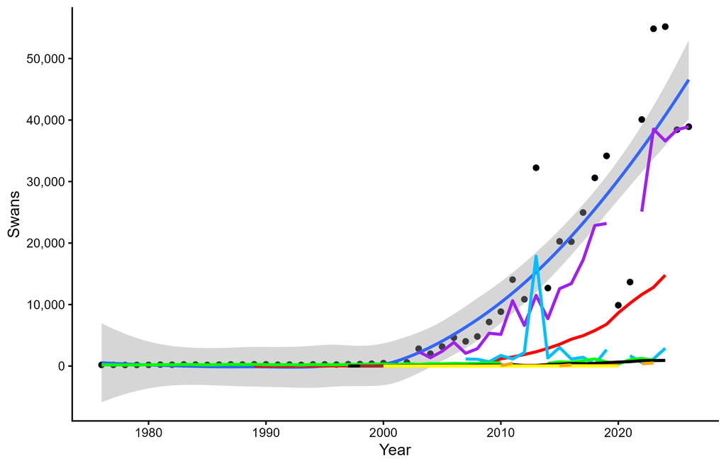

Figure 68: Interior Population trumpeter swan abundance in spring. The blue line is a smoothed (Loess model) line with 95% confidence interval (shaded area) fit to the annual total estimates (circles). The other colored lines are state specific abundance (Minnesota=purple, Wisconsin=red, Michigan=blue, Nebraska=green, Ohio=black, Iowa=brown, Illinois=yellow, South Dakota=orange.

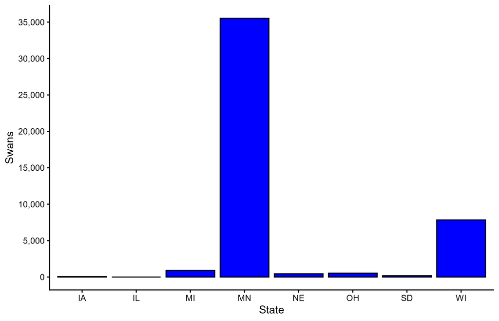

Figure 69: Interior Population trumpeter swan abundance in spring during the recent 5-year period (average annual) by State.

### Data Table 84: Sandhill Crane, MP

Original data source: Yukon Koskokwim Delta Coastal Zone Survey; USFWS Alaska Region. Data maintained by the USFWS Alaska Region.

Provided in the table below are estimated total (Total) and breeding (Breeding) bird abundance and standard error (SE) of Midcontinent Population sandhill cranes in Spring. Also provided are the total abundance moving 3-year average (M3yr) and standard error (M3yr.SE).

Table 84. Midcontinent Population sandhill crane abundance in spring, 1987-2026.

| Year | Total | Total.SE | M3yr | M3yr.SE | Breeding | Breeding.SE |
| --- | --- | --- | --- | --- | --- | --- |
| 1987 | 13,777 | 961 | NA | NA | 12,944 | 950 |
| 1988 | 15,564 | 1,539 | NA | NA | 12,208 | 809 |
| 1989 | 16,182 | 1,130 | 15,174 | 1,234 | 12,858 | 718 |
| 1990 | 18,279 | 1,476 | 16,675 | 1,394 | 14,010 | 857 |
| 1991 | 20,435 | 1,689 | 18,298 | 1,450 | 14,095 | 869 |
| 1992 | 17,188 | 1,173 | 18,634 | 1,461 | 13,188 | 845 |
| 1993 | 19,226 | 1,549 | 18,950 | 1,486 | 15,929 | 1,024 |
| 1994 | 16,683 | 1,073 | 17,699 | 1,281 | 13,883 | 860 |
| 1995 | 18,033 | 1,340 | 17,981 | 1,335 | 16,693 | 1,298 |
| 1996 | 16,669 | 1,841 | 17,129 | 1,453 | 10,240 | 803 |
| 1997 | 13,456 | 1,128 | 16,053 | 1,467 | 11,356 | 766 |
| 1998 | 23,439 | 1,282 | 17,855 | 1,450 | 17,259 | 727 |
| 1999 | 18,433 | 1,352 | 18,443 | 1,258 | 16,095 | 1,090 |
| 2000 | 17,148 | 1,203 | 19,673 | 1,280 | 15,048 | 963 |
| 2001 | 16,083 | 1,067 | 17,221 | 1,213 | 14,811 | 985 |
| 2002 | 12,704 | 1,151 | 15,312 | 1,142 | 12,236 | 1,107 |
| 2003 | 14,006 | 979 | 14,264 | 1,068 | 10,927 | 728 |
| 2004 | 14,199 | 1,164 | 13,636 | 1,101 | 11,678 | 988 |
| 2005 | 14,080 | 1,033 | 14,095 | 1,062 | 11,247 | 758 |
| 2006 | 15,050 | 1,309 | 14,443 | 1,174 | 12,525 | 987 |
| 2007 | 13,220 | 909 | 14,117 | 1,097 | 12,666 | 890 |
| 2008 | 15,113 | 950 | 14,461 | 1,071 | 13,147 | 772 |
| 2009 | 16,108 | 1,277 | 14,814 | 1,058 | 13,153 | 918 |
| 2010 | 19,183 | 1,595 | 16,802 | 1,301 | 17,250 | 1,357 |
| 2011 | 13,288 | 893 | 16,193 | 1,288 | 12,396 | 815 |
| 2012 | 19,292 | 2,017 | 17,255 | 1,572 | 17,189 | 1,454 |
| 2013 | 13,415 | 1,156 | 15,332 | 1,438 | 12,562 | 1,140 |
| 2014 | 14,196 | 2,071 | 15,634 | 1,797 | 12,478 | 1,629 |
| 2015 | 13,808 | 1,279 | 13,807 | 1,556 | 11,702 | 1,212 |
| 2016 | 23,216 | 3,025 | 17,073 | 2,241 | 17,960 | 1,208 |
| 2017 | 20,238 | 1,628 | 19,087 | 2,116 | 17,174 | 1,224 |
| 2018 | 20,741 | 2,137 | 21,398 | 2,336 | 16,944 | 1,242 |
| 2019 | 18,943 | 1,128 | 19,974 | 1,682 | 17,916 | 1,068 |
| 2020 | NA | NA | NA | NA | NA | NA |
| 2021 | 18,696 | 1,406 | 19,460 | 1,614 | 16,852 | 1,352 |
| 2022 | 13,086 | 882 | 16,908 | 1,159 | 12,220 | 769 |
| 2023 | 15,052 | 1,180 | 15,611 | 1,176 | 13,632 | 881 |
| 2024 | 12,576 | 865 | 13,571 | 986 | 11,665 | 851 |
| 2025 | 10,838 | 749 | 12,822 | 949 | 10,669 | 746 |
| 2026 | 13,591 | 844 | 12,335 | 821 | 12,842 | 773 |

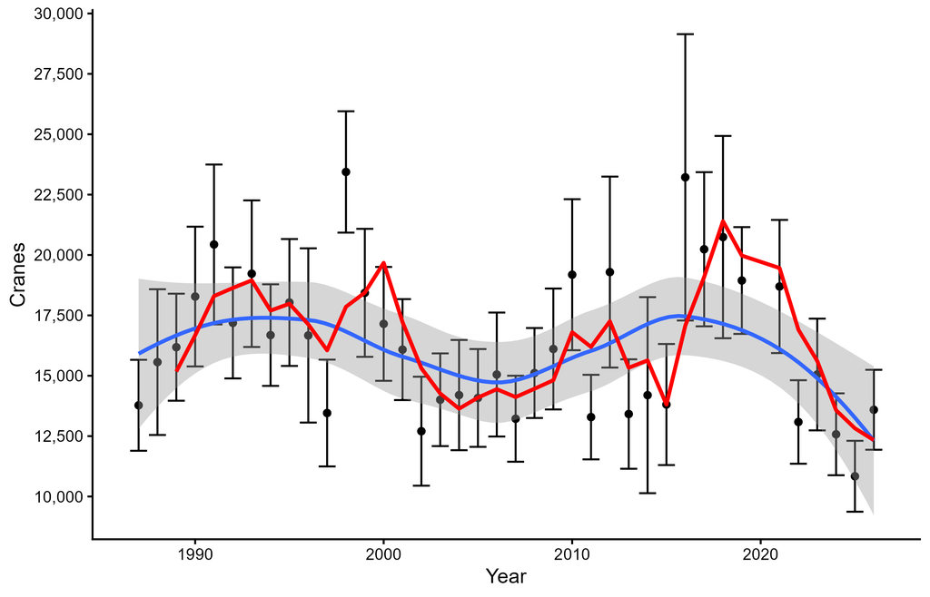

Figure 70: Midcontinent Population sandhill crane abundance in spring. Circles are annual estimates of abundance with 95% confidence intervals. The red line is a moving 3-year average and the blue line is a smoothed (Loess model) line with 95% confidence interval (shaded area) fit to the annual estimates.

### Data Table 85: Mourning Dove, EMU (spring)

Original data source: North American Breeding Bird Survey; U.S. Geological Survey. Data maintained by U.S. Geological Survey.

Provided in the table below are abundance (Index, birds per route) and lower and upper 95% credible intervals (L95%CI, U95%CI) of Eastern Management Unit Population mourning doves in spring. Also provided is the abundance moving 3-year average (M3yr).

| Year | Index | L95%CI | U95%CI | M3yr |
| --- | --- | --- | --- | --- |
| 1966 | 30.08 | 28.56 | 31.73 | NA |
| 1967 | 30.06 | 28.67 | 31.59 | NA |
| 1968 | 30.59 | 29.22 | 32.06 | 30.25 |
| 1969 | 31.08 | 29.74 | 32.52 | 30.58 |
| 1970 | 31.40 | 30.08 | 32.78 | 31.02 |
| 1971 | 32.09 | 30.78 | 33.43 | 31.52 |
| 1972 | 32.72 | 31.42 | 34.05 | 32.07 |
| 1973 | 33.08 | 31.79 | 34.38 | 32.63 |
| 1974 | 33.04 | 31.80 | 34.35 | 32.95 |
| 1975 | 33.49 | 32.25 | 34.79 | 33.20 |
| 1976 | 33.97 | 32.73 | 35.27 | 33.50 |
| 1977 | 33.25 | 32.04 | 34.48 | 33.57 |
| 1978 | 31.99 | 30.83 | 33.17 | 33.07 |
| 1979 | 31.48 | 30.33 | 32.64 | 32.24 |
| 1980 | 32.24 | 31.10 | 33.39 | 31.91 |
| 1981 | 33.11 | 31.96 | 34.27 | 32.28 |
| 1982 | 33.36 | 32.21 | 34.54 | 32.90 |
| 1983 | 33.45 | 32.32 | 34.62 | 33.31 |
| 1984 | 32.71 | 31.61 | 33.85 | 33.17 |
| 1985 | 33.11 | 32.02 | 34.28 | 33.09 |
| 1986 | 34.58 | 33.47 | 35.77 | 33.47 |
| 1987 | 35.66 | 34.54 | 36.86 | 34.45 |
| 1988 | 36.34 | 35.21 | 37.55 | 35.53 |
| 1989 | 36.45 | 35.31 | 37.64 | 36.15 |
| 1990 | 36.26 | 35.13 | 37.43 | 36.35 |
| 1991 | 36.19 | 35.08 | 37.34 | 36.30 |
| 1992 | 36.19 | 35.08 | 37.34 | 36.21 |
| 1993 | 35.90 | 34.82 | 37.03 | 36.09 |
| 1994 | 35.77 | 34.68 | 36.90 | 35.95 |
| 1995 | 36.00 | 34.88 | 37.11 | 35.89 |
| 1996 | 35.02 | 33.96 | 36.11 | 35.60 |
| 1997 | 35.10 | 34.03 | 36.22 | 35.37 |
| 1998 | 35.68 | 34.62 | 36.77 | 35.27 |
| 1999 | 36.87 | 35.80 | 37.97 | 35.88 |
| 2000 | 37.75 | 36.65 | 38.90 | 36.77 |
| 2001 | 38.08 | 36.95 | 39.25 | 37.57 |
| 2002 | 38.42 | 37.28 | 39.58 | 38.08 |
| 2003 | 38.60 | 37.45 | 39.76 | 38.37 |
| 2004 | 38.57 | 37.42 | 39.74 | 38.53 |
| 2005 | 39.14 | 37.98 | 40.33 | 38.77 |
| 2006 | 39.40 | 38.20 | 40.58 | 39.04 |
| 2007 | 40.03 | 38.86 | 41.24 | 39.52 |
| 2008 | 38.69 | 37.55 | 39.85 | 39.37 |
| 2009 | 38.37 | 37.25 | 39.52 | 39.03 |
| 2010 | 38.14 | 37.01 | 39.30 | 38.40 |
| 2011 | 37.91 | 36.80 | 39.09 | 38.14 |
| 2012 | 38.53 | 37.37 | 39.72 | 38.19 |
| 2013 | 38.08 | 36.94 | 39.28 | 38.17 |
| 2014 | 36.80 | 35.68 | 37.95 | 37.81 |
| 2015 | 35.59 | 34.51 | 36.73 | 36.82 |
| 2016 | 34.99 | 33.92 | 36.10 | 35.79 |
| 2017 | 34.50 | 33.45 | 35.62 | 35.03 |
| 2018 | 34.57 | 33.51 | 35.65 | 34.69 |
| 2019 | 34.11 | 33.05 | 35.22 | 34.39 |
| 2020 | 34.35 | 33.13 | 35.63 | 34.34 |
| 2021 | 34.58 | 33.53 | 35.69 | 34.34 |
| 2022 | 34.49 | 33.45 | 35.58 | 34.47 |
| 2023 | 33.85 | 32.83 | 34.93 | 34.31 |
| 2024 | 33.13 | 32.11 | 34.22 | 33.82 |
| 2025 | 33.13 | 32.02 | 34.31 | 33.37 |

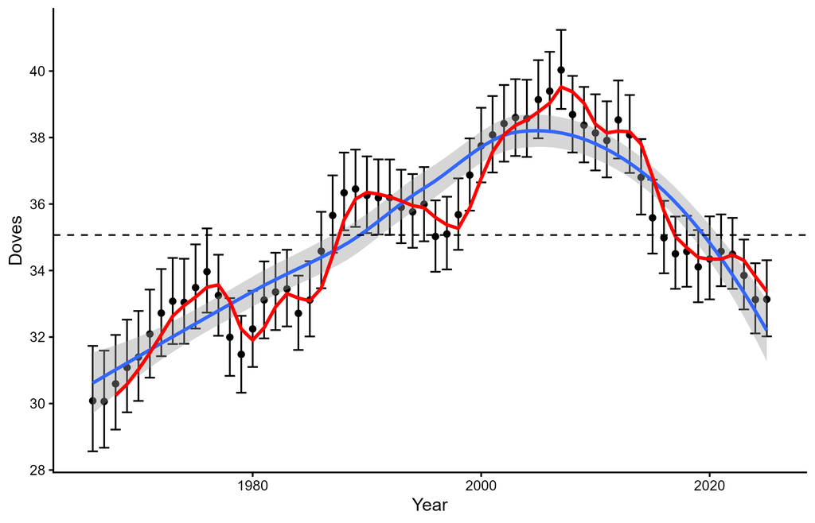

Figure 71: Eastern Management Unit Population mourning dove abundance (index) in spring. Circles are annual estimates of abundance (index) with 95% confidence intervals. The red line is a moving 3-year average and the blue line is a smoothed (Loess model) line with 95% confidence interval (shaded area) fit to the annual estimates. The black dashed reference line is the long term average.

### Data Table 85b: Mourning Dove, CMU (spring)

Original data source: North American Breeding Bird Survey; U.S. Geological Survey. Data maintained by U.S. Geological Survey.

Provided in the table below are abundance (Index, birds per route) and lower and upper 95% credible intervals (L95%CI, U95%CI) of Central Management Unit Population mourning doves in spring. Also provided is the abundance moving 3-year average (M3yr).

| Year | Index | L95%CI | U95%CI | M3yr |
| --- | --- | --- | --- | --- |
| 1967 | 57.15 | 53.25 | 71.47 | NA |
| 1968 | 54.78 | 51.39 | 68.52 | NA |
| 1969 | 54.03 | 50.98 | 67.18 | 55.32 |
| 1970 | 55.31 | 52.21 | 67.28 | 54.71 |
| 1971 | 57.75 | 54.67 | 69.17 | 55.70 |
| 1972 | 62.93 | 59.53 | 73.68 | 58.66 |
| 1973 | 61.11 | 57.87 | 71.56 | 60.60 |
| 1974 | 60.24 | 57.19 | 69.11 | 61.43 |
| 1975 | 59.67 | 56.69 | 67.51 | 60.34 |
| 1976 | 60.26 | 57.34 | 67.48 | 60.06 |
| 1977 | 62.17 | 59.20 | 68.64 | 60.70 |
| 1978 | 60.82 | 57.89 | 67.03 | 61.08 |
| 1979 | 60.60 | 57.63 | 66.23 | 61.20 |
| 1980 | 59.06 | 56.15 | 64.27 | 60.16 |
| 1981 | 60.74 | 57.81 | 65.46 | 60.13 |
| 1982 | 59.00 | 56.19 | 63.28 | 59.60 |
| 1983 | 55.33 | 52.72 | 59.26 | 58.36 |
| 1984 | 52.75 | 50.19 | 56.34 | 55.69 |
| 1985 | 50.55 | 48.13 | 53.74 | 52.88 |
| 1986 | 50.11 | 47.83 | 53.04 | 51.14 |
| 1987 | 49.10 | 46.91 | 51.70 | 49.92 |
| 1988 | 48.93 | 46.77 | 51.32 | 49.38 |
| 1989 | 50.13 | 47.90 | 52.51 | 49.39 |
| 1990 | 49.72 | 47.51 | 51.97 | 49.59 |
| 1991 | 51.34 | 49.11 | 53.61 | 50.39 |
| 1992 | 51.57 | 49.38 | 53.80 | 50.87 |
| 1993 | 47.89 | 45.92 | 49.86 | 50.27 |
| 1994 | 47.40 | 45.48 | 49.29 | 48.96 |
| 1995 | 45.66 | 43.78 | 47.55 | 46.99 |
| 1996 | 46.21 | 44.35 | 48.08 | 46.43 |
| 1997 | 48.50 | 46.53 | 50.44 | 46.79 |
| 1998 | 46.68 | 44.81 | 48.54 | 47.13 |
| 1999 | 46.69 | 44.81 | 48.57 | 47.29 |
| 2000 | 46.47 | 44.59 | 48.34 | 46.61 |
| 2001 | 44.63 | 42.83 | 46.42 | 45.93 |
| 2002 | 45.92 | 44.07 | 47.74 | 45.67 |
| 2003 | 47.88 | 45.94 | 49.74 | 46.14 |
| 2004 | 48.22 | 46.31 | 50.08 | 47.34 |
| 2005 | 47.86 | 45.97 | 49.70 | 47.99 |
| 2006 | 48.78 | 46.88 | 50.68 | 48.29 |
| 2007 | 48.88 | 46.92 | 50.79 | 48.51 |
| 2008 | 46.08 | 44.19 | 47.91 | 47.91 |
| 2009 | 46.98 | 45.07 | 48.86 | 47.31 |
| 2010 | 44.51 | 42.72 | 46.27 | 45.86 |
| 2011 | 42.44 | 40.69 | 44.16 | 44.64 |
| 2012 | 42.82 | 41.06 | 44.54 | 43.26 |
| 2013 | 46.11 | 44.21 | 47.89 | 43.79 |
| 2014 | 48.87 | 46.83 | 50.81 | 45.93 |
| 2015 | 49.39 | 47.38 | 51.38 | 48.12 |
| 2016 | 47.82 | 45.83 | 49.80 | 48.69 |
| 2017 | 45.98 | 44.11 | 47.81 | 47.73 |
| 2018 | 44.09 | 42.34 | 45.84 | 45.97 |
| 2019 | 41.87 | 40.14 | 43.63 | 43.98 |
| 2020 | 41.41 | 39.43 | 43.44 | 42.45 |
| 2021 | 40.83 | 39.08 | 42.62 | 41.37 |
| 2022 | 42.35 | 40.57 | 44.20 | 41.53 |
| 2023 | 46.87 | 44.83 | 48.90 | 43.35 |
| 2024 | 47.61 | 45.51 | 49.70 | 45.61 |
| 2025 | 48.39 | 46.12 | 50.66 | 47.62 |

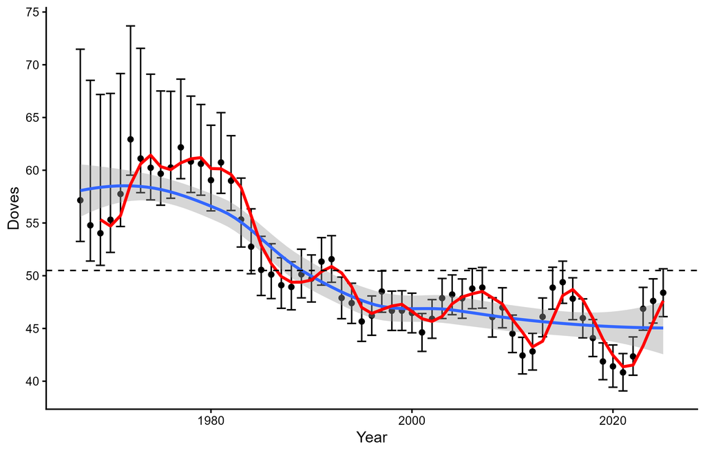

Figure 72: Central Management Unit Population mourning dove abundance (index) in spring. Circles are annual estimates of abundance (index) with 95% confidence intervals. The red line is a moving 3-year average and the blue line is a smoothed (Loess model) line with 95% confidence interval (shaded area) fit to the annual estimates. The black dashed reference line is the long term average.